# Social Network Analysis - Amber Heard Case - Twitter

MAHMOUD NAGY - MAR 2022

- **Introduction**
- Exploratory Data Analysis
- Conclusions

## Introduction

> Twitter - Social Network Analysis on Amber Heard's Case  
> Investigating Threat tweets In Other Languages

```python
import time
t0 = time.time()
import pandas as pd
import os
# pd.set_option('display.max_columns', 500)
import numpy as np
import matplotlib.pyplot as plt
import seaborn as sb
import matplotlib.dates as mdates
import plotly.express as px
import plotly.graph_objects as go
import pickle
import re
import warnings
import datetime
warnings.filterwarnings('ignore')
sb.set_style("darkgrid")
%matplotlib inline

import plotly.io as pio
pio.renderers
# pio.renderers.default = "svg"
svg_renderer = pio.renderers["svg"]
svg_renderer.width = 950
svg_renderer.height = 550


# # Import the necessaries libraries
# import plotly.offline as pyo
# # Set notebook mode to work in offline
# pyo.init_notebook_mode()

from load_language_data import *
import language_helpers as helpers


# To Apply helpers updates without resarting the kernel
import importlib
# importlib.reload(helpers)

# # To keep track of any module updates
# %load_ext autoreload
# %autoreload2

%config InlineBackend.figure_format = 'retina'
time.time() - t0
```

```
16.408638954162598
```

# Threat & Hate-Speech Vs Others (In Other Languages)

```python
helpers.go_pie('Threat & Hate-Speech Vs Others (In Other Languages)',
             ['Threat', 'Hate-Speech', 'Others'],
             [n_threat, n_hate, nothate],
             c=['#E45756', '#F58518', '#4C78A8'])
```

[figure not shown]

## The Count of Threat Tweets in Each Languaguge

```python
helpers.barh(df_threat.lang.value_counts().to_frame().reset_index().rename(columns={'index': 'Language',
                                                                                    'language': 'Count'}).head(15),
             'The Count of Threat Tweets in Each Languaguge', threshold=0, c=0)
```

[figure not shown]

## A Heat Map for the Threat tweets (In other languages)

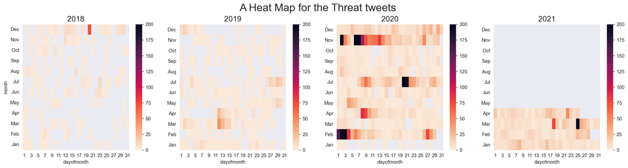

```python
threat_daily = df_threat.groupby(['year', 'dayofmonth', 'month']).size().reset_index(name='ntweets')

title = 'A Heat Map for the Threat tweets'
helpers.facet_heat(threat_daily, title, n_col=4, vmax=200)
```

### Threat tweets Peak Dates (Other Languages)

```python
helpers.barh(threat_dates_15, '"Threat Keywords" Peak Dates (Other Languages)', threshold=0)
```

[figure not shown]

```python
df_tweets.created_at.dt.date.min(), df_tweets.created_at.dt.date.max()
```

```
(datetime.date(2018, 1, 1), datetime.date(2021, 4, 25))
```

```python
print(f"\nTotal Multilingual Threat Tweets in the 4 years is: {df_threat.shape[0]}\n")
print(f"Made by {df_threat.username.nunique()} Users\n")
print(f"In {df_threat.lang.nunique()} Languages")
```

```
Total Multilingual Threat Tweets in the 4 years is: 8999

Made by 7068 Users

In 43 Languages
```

```python
helpers.pie(df_threat_years, "'Threat' Tweets Created in Each Year (In other languages)",
            c = ["#c23728", "#e14b31", "#de6e56", "#e1a692"])
```

[figure not shown]

> **Note:**
> - The number of threat tweets are increasing from 2018 to 2020
> - For 2021: the data is not complete (only till April)

```python
helpers.pie(df_threat_users, "The Number of Accounts Tweeted with 'Threat' Keywords in Each Year",
            c = ["#c23728", "#e14b31", "#de6e56", "#e1a692"])
```

[figure not shown]

# Threat Keywords (Translated from other languages)

```python
len(all_threat)
```

```
31
```

```python
helpers.go_pie('Different Threat Keywords',
             ['Kill & Death', 'Hell & Burn', 'Crime & Jail'],
             [n_death, n_burn, n_crime],
             c=['#E45756', '#F58518', '#BAB0AC'])
```

[figure not shown]

```python
# import importlib
# importlib.reload(helpers)
# ['#E45756', '#EECA3B', '#F58518', '#4C78A8']
helpers.pie(df_kill_years, "'Kill & Death' Tweets Created in Each Year (In other languages)",
            c = ["#c23728", "#e14b31", "#de6e56", "#e1a692"])
```

[figure not shown]

```python
helpers.pie(df_burn_years, "'Hell & Burn' Tweets Created in Each Year (In other languages)",
            c = ["#786028", "#a57c1b", "#d2980d", "#ffb400"])
```

[figure not shown]

```python
helpers.pie(df_crime_years, "'Crime & Jail' Tweets Created in Each Year (In other languages)",
            c = ["#48446e", "#5e569b", "#776bcd", "#9080ff"])
```

[figure not shown]

| Keyword | Language | Transelation |
| --- | --- | --- |
| muerte | Spanish | Death |
| 死ね | Japanese | Die |
| muerete | Spanish | Die |
| morire | Italian | Die |
| morir | Spanish | To die |
| muere | Spanish | go dead |
| matar | Portuguese | to kill |
| prigione | Italian | prison |
| prisión | Spanish | Prison |
| inferno | Italian | Hell |
| infierno | Spanish | Hell |
| Ад | Russian | Hell |
| pagar | Spanish | to pay |

```python
# threat_counts.head(60).reset_index(drop=True)
print('\nThe Red-Colored are "Kill & Death" Keywords')
helpers.barh(threat_others_counts.head(17), '"Threat Keywords" Counts', threshold=0, c=mycolors1)
```

```
The Red-Colored are "Kill & Death" Keywords
```

[figure not shown]

```python
print('\nThe Red-Colored are "Kill & Death" Keywords')
helpers.barh(threat_counts.head(17), '"Translated Threat Keywords" Counts', threshold=0, c=mycolors1)
```

```
The Red-Colored are "Kill & Death" Keywords
```

[figure not shown]

# Kill & Death

```python
print(f'\n{df_death.shape[0]} contributions, made by {df_death.username.nunique()} Users, In {df_death.lang.nunique()} Languages')
```

```
2948 contributions, made by 2418 Users, In 38 Languages
```

# Hell & Burn

```python
print(f'\n{df_burn.shape[0]} contributions, made by {df_burn.username.nunique()} Users, In {df_burn.lang.nunique()} Languages')
```

```
1590 contributions, made by 1417 Users, In 32 Languages
```

# Punish, Crime, Jail & Prison

```python
print(f'\n{df_crime.shape[0]} contributions, made by {df_crime.username.nunique()} Users, In {df_crime.lang.nunique()} Languages')
```

```
4722 contributions, made by 3933 Users, In 36 Languages
```

## Exploratory Data Analysis

- Introduction
- **Exploratory Data Analysis**
- Conclusions
> - Threat tweets
> - Hate-Speech tweets
> - Same Text Same Date
> - Primarly Text Investigations

```python
print(df_tweets.shape)
df_tweets.head(1)
```

```
(117841, 24)
```

|  | user_description | username | n_followers | text | profile_banner_url | user_location | user_id | user_created_at | profile_image_url | n_friends | ... | tweet_id | user_screen_name | date | year | month | dayofmonth | diff | days_diff | translated | hours_diff |
| --- | --- | --- | --- | --- | --- | --- | --- | --- | --- | --- | --- | --- | --- | --- | --- | --- | --- | --- | --- | --- | --- |
| 1 | ワクワクするようなことがあるといいんだけど🙄 2017.11.11〜 | takanari | 88 | 今年も好きな女優さんはamber heardとjessica albaです\nふたりとも大し... | https://pbs.twimg.com/profile_banners/92864130... | Tokyo | 928641308092088321 | 2017-11-09 15:11:55 | http://pbs.twimg.com/profile_images/9717089437... | 63 | ... | 947749501149655040 | Virgo_in_type_A | 2018-01-01 | 2018 | Jan | 1 | 52 days 17:29:09 | 52 | my favorite actresses this year are amber hear... | 17 |

1 rows × 24 columns

```python
df_tweets.created_at.dt.date.min(), df_tweets.created_at.dt.date.max()
```

```
(datetime.date(2018, 1, 1), datetime.date(2021, 4, 25))
```

```python
# df_tweets.info()
```

```python
# helpers.isnull(df_tweets)
```

```python
for col in ['year', 'username', 'lang', 'user_location', 'translated']:
    print('The value counts of ' + col)
    print(df_tweets[col].value_counts().head())
    print('\n')
```

```
The value counts of year
2020    81055
2021    15132
2019    13560
2018     8094
Name: year, dtype: int64


The value counts of username
La Sopa.Com                       2049
La Patilla                         363
informazione cultura               266
Telesphore Teta                    224
#IBelieveHim JohnnyDeppWorldDE     172
Name: username, dtype: int64


The value counts of lang
es    56311
pt    15824
fr    12370
it     6082
in     5430
Name: lang, dtype: int64


The value counts of user_location
Latinoamérica    2060
México           1549
France           1296
Brasil           1072
Venezuela        1003
Name: user_location, dtype: int64


The value counts of translated
amber heard april 22, 1986-american actress https://t.co/oa4buqt3ub\r                                                                                    81
#enentertainment johnny depp published a photo that would prove that he was attacked by amber heard https://t.co/bljdfrar2j https://t.co/jt2bs3zw34\r    60
fuck your mother amber heard\r                                                                                                                           55
#amber heard admits she hit #johnny depp https://t.co/nbrp6vstvl\r                                                                                       41
ayo fuck amber heard\r                                                                                                                                   24
Name: translated, dtype: int64
```

## Exploring Threat tweets

> - **Threat tweets**
> - Hate-Speech tweets
> - Same Text Same Date
> - Primarly Text Investigations

## Kill & Death

> > - **Kill & Death**
> > - Hell & Burn
> > - Crime & Jail
> > - All Threat
> > - Threat Users Contributions

```python
death_sub = {'those can die', 'she die', 'i hope all of you die', 'it must die', 'bitch die', 'please die'
             'you to die', 'die #amberheard', "why didn't you die", 'she will die', 'deserves to die',
             'heard will die', "it's better to die", 'worst rot that exists will die', 'die amber', 'heard die',
             'let her die', 'destiny is to die', 'i want to die', 'die at the hands of', 'great day to die',
             'heard could die', 'rest when you die', 'i want ahbosta to die',
             "heard, you're going to die", "heard you're going to die", 'crazy girl is going to die',
             'she was going to die', "heard that you're going to die", 'i hope you die,', 'heard to die',
             'heard and other ways to die', 'waste to die', 'heard to die', 'her destiny will be to die alone',
             "why don't you die", 'how you died', ', i hope you die', 'rest when you die', 'heard you die',
             'when will you die', 'please and die', 'and die disgraced', 'hate you to death', 'painful death',
             'burned to death', 'death to the penis', 'death to her', "you're dead amber", 'heard for me is dead',
             'shit on your dead', 'eats her great dead', 'shit on the dead of amber', 'shit on all her dead',
             'all stupid gi dead', 'murder amber', "i'll kill you", 'kill yourself', 'kill that',
             'kill this pheasant', 'kill this slut', 'kill this b', '— kill amber', '3 days to kill amber',
             'gathering people to kill amber', 'i want to kill amber', 'how am i going to kill amber',
             'you have to kill amber', 'is it okay to kill amber'}
```

```python
df_death_sub = df_threat[df_threat.translated.str.contains('|'.join(death_sub))]
print(f'{df_death_sub.shape[0]} contributions, made by {df_death_sub.username.nunique()} Users, In {df_death_sub.lang.nunique()} Languages')
df_death_sub.head(1)
```

```
109 contributions, made by 108 Users, In 15 Languages
```

|  | user_description | username | n_followers | text | profile_banner_url | user_location | user_id | user_created_at | profile_image_url | n_friends | ... | tweet_id | user_screen_name | date | year | month | dayofmonth | diff | days_diff | translated | hours_diff |
| --- | --- | --- | --- | --- | --- | --- | --- | --- | --- | --- | --- | --- | --- | --- | --- | --- | --- | --- | --- | --- | --- |
| 632 | NaN | cristian | 47 | machete kills fight scene (amber heard dies) h... | https://pbs.twimg.com/profile_banners/82469289... | NaN | 824692893885476864 | 2017-01-26 18:58:02 | http://pbs.twimg.com/profile_images/9152775768... | 1338 | ... | 963799683658170368 | cristianronqu20 | 2018-02-14 | 2018 | Feb | 14 | 383 days 20:40:43 | 383 | machete kills fight scene (amber heard dies) h... | 20 |

1 rows × 24 columns

[figure not shown]

```python
death_daily = df_death.groupby(['year', 'dayofmonth', 'month']).size().reset_index(name='ntweets')

title = 'A Heat Map for the "Kill & Death" tweets'
helpers.facet_heat(threat_daily, title, n_col=4, vmax=200)
```

### "Kill & Death" tweets Peak Dates (ALL)

```python
death_dates = df_death.groupby(['date']).agg({'translated':'count', 'user_id': 'count'}).reset_index(
).rename(columns={'translated':'ntweets', 'user_id': 'n_users'}).sort_values('ntweets', ascending=False)

death_dates.head(15)
```

|  | date | ntweets | n_users |
| --- | --- | --- | --- |
| 364 | 2020-07-20 | 296 | 296 |
| 252 | 2020-02-02 | 204 | 204 |
| 365 | 2020-07-21 | 179 | 179 |
| 441 | 2020-11-06 | 131 | 131 |
| 442 | 2020-11-07 | 109 | 109 |
| 89 | 2018-12-20 | 64 | 64 |
| 438 | 2020-11-02 | 63 | 63 |
| 253 | 2020-02-03 | 47 | 47 |
| 310 | 2020-05-04 | 35 | 35 |
| 254 | 2020-02-04 | 33 | 33 |
| 353 | 2020-07-09 | 32 | 32 |
| 366 | 2020-07-22 | 30 | 30 |
| 311 | 2020-05-05 | 25 | 25 |
| 443 | 2020-11-08 | 24 | 24 |
| 256 | 2020-02-06 | 23 | 23 |

```python
helpers.bar_peaks(death_dates[['date', 'ntweets']].head(2),
                  '"Kill & Death" tweets Peak Dates')
```

[figure not shown]

# Most Repeated "Kill & Death" tweets

```python
df_death_sub.translated.value_counts().head()
```

```
machete kills fight scene (amber heard dies) https://t.co/kwmiq8vtn3 vía @youtube\r                                                                                                                                                                                         1
if father dep hurt you so much, why didn't you die? his face didn't see a broken nose, but he covered up his makeup, he got a broken rib, but he could walk normally. well, i really believe that the court is stupid. #justiceforjohnnydepp\r                              1
i was watching a video of when amber's trial ends and jhonny... weyyyy yell booo at amber xdxd wey, bu? 😪 if she had been in mexico, they would have yelled at her until she was going to die, an example #amberheardisanabuser chinga tú perra puta madre #amberheard\r    1
@alesitojaja that amber heard dies it's not fair that they take out jhonny deep damn liar, i'll vent thanks\r                                                                                                                                                               1
amber heard because you don't take a pellet and die disgraced\r                                                                                                                                                                                                             1
Name: translated, dtype: int64
```

```python
df = df_death_sub[['created_at', 'days_diff', 'hours_diff', 'text', 'lang', 'translated', 'username']].head(60)
with pd.option_context('display.max_colwidth', None):
  display(df.reset_index(drop=True).style.set_properties(**{'text-align': 'left'}))
```

|  | created_at | days_diff | hours_diff | text | lang | translated | username |
| --- | --- | --- | --- | --- | --- | --- | --- |
| 0 | 2018-02-14 15:38:45 | 383 | 20 | machete kills fight scene (amber heard dies) https://t.co/kwmiq8vtn3 vía @youtube | es | machete kills fight scene (amber heard dies) https://t.co/kwmiq8vtn3 vía @youtube | cristian |
| 1 | 2018-04-04 17:19:26 | 479 | 2 | kiss, marry, kill : angelina jolie ( à l'époque de lara croft) , taylor hill ou amber heard — kill amber heard kiss taylor hill marry angelina jolie https://t.co/5w8ionqkbr | fr | kiss, marry, kill : angelina jolie ( à l'époque de lara croft) , taylor hill ou amber heard — kill amber heard kiss taylor hill marry angelina jolie https://t.co/5w8ionqkbr | Nathan |
| 2 | 2018-06-05 23:04:04 | 1131 | 12 | amber heard sana ölümüne tavım | tr | amber heard i hate you to death | nazlıcan |
| 3 | 2018-09-12 20:04:03 | 1895 | 15 | amber heard y otras maneras de morir | es | amber heard and other ways to die | Margaret Pelekai |
| 4 | 2018-10-10 10:30:00 | 1140 | 23 | #trailer amber heard, theo james, cara delevigne y jimm sturgess coinciden en #londonfields, sobre una mujer que sabe que algún día morirá a manos de uno de sus tres amantes. ¿quién será, será...? htt… | es | #trailer amber heard, theo james, cara delevigne and jimm sturgess meet in #londonfields, about a woman who knows that one day she will die at the hands of one of her three lovers. who will she be, wi… | All Screens |
| 5 | 2019-03-11 16:01:40 | 69 | 0 | #amberheardisanabuser #amberheardisanabuser 我有时候也很想打张越洋机票飞到美国去给#amberheard#这个臭婊子的丑逼两刀看看能不能把这只野鸡杀了，但是死真的太便宜这个贱逼了，我操它妈的这个又丑又老又贱的死贱野鸡，它他妈biss，等它死了我立刻去给这只曝尸荒野的死野鸡两脚并吐两口唾沫嘻嘻 | zh | #amberheardisanabuser #amberheardisanabuser sometimes i also want to take a cross-ocean ticket and fly to the united states to give #amberheard# this stinky bitch ugly two knives to see if i can kill … | evergreentree |
| 6 | 2019-03-13 09:29:09 | 567 | 1 | meu deus eu vou matar aquela puta da amber heard toma alexsandro, enfia no cu q a tua queridinha é uma mentirosa d merda e andava a praticar violência doméstica contra o depp | pt | oh my god i'm gonna kill that bitch amber heard take alexsandro, shut it up your ass that your sweetheart is a fucking liar and was practicing domestic violence against depp | Clara |
| 7 | 2019-03-25 13:35:33 | 3311 | 11 | putangina ka amber heard, mamatay ka na. | tl | ask amber heard, you're going to die. | death records |
| 8 | 2019-04-19 00:51:00 | 2754 | 7 | eu não aguento mais ver coisa sobre chernodepp e amber heard, só quero que esse lixo atômico morra logo | pt | i can't stand to see anything about chernodepp and amber heard anymore, i just want this atomic waste to die soon | miss botany girl |
| 9 | 2019-10-27 04:28:34 | 1929 | 4 | @aphroditechicc منم‌دوست دارم amber heard رو بکشم | fa | @aphroditechicc i want to kill amber heard | زائر خاکستری⚖ |
| 10 | 2020-01-28 00:55:10 | 3884 | 0 | cómo vay a matar a la amber heard, infeliz! ...en la película, digo | es | how am i going to kill amber heard, unhappy! ...in the movie, i mean | lobosorno |
| 11 | 2020-02-02 03:19:21 | 1862 | 5 | você não acreditar e n querer buscar informações por ser "morte ao pênis" n é ser feminista é ser escrota #justiceforjohnnydepp https://t.co/wam3xikm3v | pt | if you don't believe it and don't want to seek information because it's "death to the penis" it's not being a feminist, it's being an asshole #justiceforjohnnydepp https://t.co/wam3xikm3v | ari&blackstairs |
| 12 | 2020-02-02 03:59:59 | 3771 | 5 | amber heard es una pinche loca tóxica y su destino será morir en la soledad #justiceforjohnnydepp | es | amber heard is a fucking toxic crazy and her destiny will be to die alone #justiceforjohnnydepp | Frank Colmenares |
| 13 | 2020-02-02 04:00:42 | 615 | 0 | 专门翻墙出来骂amber heard这个老妖婆！我的心肝老宝贝就让你这么糟蹋了？嗯？？？你咋不赶紧死呢？对，我就是在诅咒这个贱婢！给你脸了一天天的？ #justiceforjohnnydepp | zh | specially over the wall to scold amber heard, the old witch! my dear old darling, let you spoil it like this? um? ? ? why don't you die quickly? yes, i am cursing this bitch! give you a face every day… | Shanice.Y |
| 14 | 2020-02-02 06:52:43 | 9 | 2 | #justiceforjohnnydepp 贱女人去死吧！！！真是我这辈子见过最臭的蛆🙂别让奶奶看见你，要不然你都不知道是怎么死的🙂🙂🙂 看见我男人是你这种贱🐔八百年修来的福分😊😊😊现在下地狱吧 | zh | #justiceforjohnnydepp die bitch! ! ! it's the most smelly maggot i've ever seen in my life 🙂 don’t let your grandma see you or you won’t know how you died 🙂 🙂 🙂 seeing that my man is a bitch like you … | 子午云 |
| 15 | 2020-02-02 09:56:02 | 3472 | 6 | que lindo descancelar a alguien que amaste tantos años, hay que matar a la amber si que si #justiceforjohnnydepp | es | how nice to cancel someone you loved for so many years, you have to kill amber yes yes #justiceforjohnnydepp | maru. |
| 16 | 2020-02-02 12:24:15 | 368 | 16 | amber heard leva uma iphonada do johnny depp na cara. "maldito, machista, cancelado, tomara que morra" áudios vazados mostram que amber heard era abusiva e também agredia johnny depp. "aaah tem que ve… | pt | amber heard takes a johnny depp iphon to the face. "damn, sexist, cancelled, i hope you die" leaked audio shows that amber heard was abusive and also assaulted johnny depp. "aaah have to see if this i… | Wend |
| 17 | 2020-02-02 14:23:37 | 1873 | 22 | mano, essa amber heard tinha que morrer queimada no meio de uma multidão como faziam antes... puta que pariu que mulher nojenta do caralho, quem em plena consciência decepa um pedaço do dedo do marido… | pt | bro, that amber heard had to be burned to death in the middle of a crowd like they used to... holy shit what a fucking disgusting woman, who in full conscience cuts off a piece of her husband's finger… | Fewlo - Figurino HC 👕👖 |
| 18 | 2020-02-02 22:48:34 | 2076 | 14 | yawa kayka amber heard mamatay ka na | tl | devil kayka amber heard you're going to die | shane ♡: ) cw detco 🕵️ |
| 19 | 2020-02-03 00:22:15 | 3951 | 20 | que se muera amber heard | es | let amber heard die | valita |
| 20 | 2020-02-03 04:29:48 | 665 | 12 | увидел твит где говорится, что стоило женщине один раз абьюзить мужчину так смерть ей. эм простите, но если бы мистер депп был таким же мудаком, то защищать его, адекватные люди не станут. все равно к… | ru | i saw a tweet where it says that it cost a woman one time to abuse a man so death to her. um, sorry, but if mr. depp was the same asshole, then adequate people would not defend him. it doesn't matter … | 💋аквариум с(триптизершой) рыбкой 🥞🤝🐱🤝🐟 |
| 21 | 2020-02-03 05:26:51 | 2687 | 3 | maldita arpia! #justiceforjohnnydepp #amberheardisaliar le deseo cáncer en cualquier parte del cuerpo y una muerte lenta y dolorosa ! | es | damn harpy! #justiceforjohnnydepp #amberheardisaliar i wish him cancer in any part of the body and a slow and painful death! | Verónika Velarde |
| 22 | 2020-02-03 07:23:25 | 904 | 16 | я просто хочу чтобы ебаная эмбер хёрд сдохла самой ужасной смертью, а люди которые обвиняли джонни почувствовали себя ужасно виновато #justiceforjohnnydepp | ru | i just want fucking amber heard to die the worst possible death and make the people who blamed johnny feel terribly guilty. #justiceforjohnnydepp | •°Lustful child |
| 23 | 2020-02-06 18:02:16 | 2193 | 4 | @lafallaras a ver si se muer amber heard, para que habléis de toda la mierda que ha hecho, pirada. | es | @lafallaras let's see if amber heard dies, so you can talk about all the shit she's done, crazy. | PutoKoala |
| 24 | 2020-02-06 18:38:51 | 807 | 4 | @leisysiel el día que se muera amber heard habrá que recalcarle cómo maltrató a johnny depp. eso si a la fallarás no se la ha llevado antes al purgatorio una cirrosis. | es | @leisysiel the day amber heard dies, it will be necessary to emphasize to her how she mistreated johnny depp. that is if fallarás has not been taken to purgatory before by cirrhosis. | 🅰lex™🇪🇦 |
| 25 | 2020-02-06 19:00:01 | 120 | 23 | comment amber heard mérite tellement de mourir. heureusement que je ne l'ai jamais crue cette tarée. elle a jamais été crédible ptn | fr | how amber heard so deserves to die. luckily i never believed that psycho. she was never believable ptn | Marion |
| 26 | 2020-02-07 08:54:37 | 420 | 18 | #amberheardisanabuser cuando todos creían que jd era un abusador: abusador, golpeador, ojalá te muer@s, ojalá no actúes más. ahora que se sabe quién es la abusadora: es problema personal de la pareja,… | es | #amberheardisanabuser when everyone believed that jd was an abuser: abuser, beater, i hope you die, i hope you don't act anymore. now that it is known who the abuser is: it is a personal problem for t… | MIA CHICKEN V: |
| 27 | 2020-02-17 04:09:09 | 4062 | 23 | ahora si flashpoint. de paso matan a la turra esa de amber heard y todos felices. | es | now yes flashpoint. by the way they kill that amber heard mob and everyone is happy. | José A. Zunino Tosi |
| 28 | 2020-02-24 23:51:08 | 2358 | 17 | tanginang amber heard 'yan mamatay ka na pota | tl | only amber heard that you're going to die | support Johnny Depp |
| 29 | 2020-02-26 19:10:45 | 1521 | 0 | nada, eu disse nada que a amber heard tenha feito pra ele pode ser pior que isso, o nojento ainda disse que estupraria o corpo dela depois de morta e vocês vêm pintar ele de coitadinho por que ela bat… | pt | nothing i said nothing amber heard did to him could be worse than that, the disgusting even said he would rape her body after she died and you come to paint him as a poor thing why does she hit him to… | tatá p.28 |
| 30 | 2020-03-03 09:51:48 | 3892 | 14 | @ffhde euer ernst? ja von euch ein schlechter scherz würde ich sagen. ja er hat wohl das geschrieben, aber zwischen schreiben und machen, liegen welten. das habe ich bei ffh gesehen: schlechter scherz… | de | @ffhde are you serious? yes of you a bad joke i would say. yes, he probably wrote that, but there are worlds between writing and doing. i saw this on ffh: johnny depp bad joke: was he planning to murd… | Kitte-❤️Johnny is Innocent❤️ |
| 31 | 2020-04-15 00:23:48 | 3732 | 19 | se me antoja ver una película seis de piratas del caribe con johonny depp pero amber heard tiene que ser la villana y si es posible, una especie de bruja marina ligada a #aquaman así cuando muera se j… | es | i want to see a movie six of pirates of the caribbean with johnny depp but amber heard has to be the villain and if possible, a kind of sea witch linked to #aquaman so when she dies it is justified th… | Dir. Diego Francisco 🇲🇽 |
| 32 | 2020-05-08 00:31:52 | 522 | 1 | sigan ya descansaran cuando mueran #nojohnnynopirates #justiceforjohnnydepp #wewantpirates6 | es | keep going and rest when you die #nojohnnynopirates #justiceforjohnnydepp #wewantpirates6 | Gabriel Amézquita #RestoreTheSnyderVerse |
| 33 | 2020-05-11 07:09:27 | 2202 | 18 | amber heard’ün annesi paige heard hayatını kaybetti https://t.co/uqkl5qrjkz | tr | amber heard's mother paige heard dies https://t.co/uqkl5qrjkz | Sözcü Hayat |
| 34 | 2020-05-11 07:15:39 | 3458 | 20 | amber heard’ün annesi paige heard hayatını kaybetti https://t.co/q5net5izef | tr | amber heard's mother paige heard dies https://t.co/q5net5izef | Sözcü |
| 35 | 2020-06-11 02:03:00 | 265 | 2 | morre amber heard aos 34 anos no dia 11 de junho de 2020 vítima de comer cocô onde cagou e se engasgou com a própria bosta. https://t.co/rglaef3q2v | pt | amber heard dies at the age of 34 on june 11, 2020 victim of eating poop where he shit and choked on his own shit. https://t.co/rglaef3q2v | Yugi Sad Boy |
| 36 | 2020-06-28 00:38:13 | 593 | 2 | me cago en tus muertos amber heard | es | i shit on your dead amber heard | s3ph |
| 37 | 2020-07-03 08:50:48 | 4014 | 1 | @keyserreal @petite_blondie amber heard mahkemeye hiç çıkmadı, sadece geçici uzaklaştırma talebi yaptı ki bunun için bir delil göstermesi gerekmiyor. sonra iddiayı geri çekti, boşandı ve anlaşmasız ev… | tr | @keyserreal @petite_blondie amber heard has never appeared in court, she just requested temporary suspension, which she doesn't need to provide evidence for. then she withdrew the claim, got divorced,… | ayca gurelman |
| 38 | 2020-07-08 08:35:42 | 688 | 15 | j’espère amber heard va pourrir seule jusqu’à sa mort | fr | i hope amber heard will rot alone until she dies | :p |
| 39 | 2020-07-28 14:45:50 | 2914 | 1 | depuis le débuuuuuuuut je savais que johnny depp était innocent, votre amber heard plus vicieuse tu meurs | fr | since the debuuuuuuuut i knew that johnny depp was innocent, your most vicious amber heard you die | Asuka 🍯 |
| 40 | 2020-07-31 19:44:54 | 472 | 13 | ojalá amber heard se muera pronto y dolorosamente | es | hopefully amber heard dies soon and painfully | Oldie But "Gol D."🏅 |
| 41 | 2020-08-02 15:24:01 | 57 | 23 | #justiceforjohnnydepp johnny dovevi ucciderla quella puttana guarda cosa ti ha fatto | it | #justiceforjohnnydepp johnny you had to kill that bitch look what she did to you | _TB_ |
| 42 | 2020-08-20 22:53:29 | 2115 | 6 | @fem_shepard_ entonces esta bien asesinar a amber heard? 🤔 | es | @fem_shepard_ so is it okay to kill amber heard? 🤔 | Zuzki |
| 43 | 2020-09-27 15:05:04 | 426 | 9 | @nawieki @jutta_ditfurth somuncu raus evtl wen anders dafuer rein also whoever comes to mind, einfach mal “satire d news” googlen, dann rage royal weil @dieternuhr der ekelnazilindner, lisa eckharts d… | de | @nawieki @jutta_ditfurth somuncu out maybe someone else in there so whoever comes to mind, just google “satire d news”, then rage royal because @dieternuhr der ekelnazilindner, lisa eckharts die amber… | franziska zintl königsberger |
| 44 | 2020-11-02 11:11:34 | 2519 | 12 | miles de mujeres mueren a manos de hombres todos los días y vosotros callais y mirais para otro lado. ahora, pasa al revés, y es una mujer la q maltrata a un hombre y hasta habéis inventado un hashtag… | es | thousands of women die at the hands of men every day and you keep quiet and look the other way. now, it happens the other way around, and it is a woman who mistreats a man and you have even invented a… | nose |
| 45 | 2020-11-02 13:45:20 | 357 | 15 | johnny depp é a imagem do porque muita gente morre nas mãos de seus agressores. porque não importa o lugar, a vítima nunca é levada em consideração e a justiça sempre absolve os abusadores! #justicefo… | pt | johnny depp is the image of why so many people die at the hands of their abusers. because no matter the place, the victim is never taken into account and justice always acquits the abusers! #justicefo… | Carol Cáceres 🌻 |
| 46 | 2020-11-02 15:22:16 | 1931 | 1 | espèce de grosse pute d'amber heard, t'es la pire pourriture qui existe va crever pute de merde | fr | you big fat whore of amber heard, you're the worst rot that exists will die, motherfucker | lulustucru |
| 47 | 2020-11-02 15:24:50 | 4166 | 11 | qué onda ? si está bien loca la morra. #justiceforjohnnydepp | es | what's up ? if she is really crazy, she will die. #justiceforjohnnydepp | Valeria |
| 48 | 2020-11-02 18:14:01 | 1024 | 12 | ojalá se muera amber heard. así como todos lxs abusadorxs. | es | i hope amber heard dies. just like all abusers. | guayabita |
| 49 | 2020-11-06 08:31:50 | 1477 | 23 | kurwa amber heard jak ja cię nienawidzę, mam nadzieję, że upadniesz i sobie ten głupi ryj rozwalisz. #justiceforjohhnydepp | pl | fucking amber heard like i hate you, i hope you will fall and yourself will kill yourself. #justiceforjohhnydepp | Vic(xian) |
| 50 | 2020-11-06 16:26:43 | 826 | 8 | @shotorice sono incazzata nera, spero che amber heard bruci all’inferno, ci credo nel karma, deve schiattare | it | @shotorice i am pissed off, i hope that amber heard you burn in hell, i believe in karma, it must die | ♏︎decalcomaniaia ⁷ |
| 51 | 2020-11-06 17:00:52 | 1922 | 1 | amber heard me cago en tus muertos | es | amber heard i shit on your dead | HΛΠX |
| 52 | 2020-11-06 17:03:11 | 185 | 12 | amber heard ölünce cehennemde şeytan yanına gidip al sen yönet artık buraları diycek | tr | when amber heard dies, the devil will go to hell and say, you rule this place. | sskl |
| 53 | 2020-11-06 17:13:21 | 3561 | 18 | que impotencia y coraje, eh estado llorando mucho porque o sea con la evidencia en la mesa no le creen y eso es lo que viven muchas personas hoy día, pincha amber heard neta ojalá se muera por mentiro… | es | what impotence and courage, i've been crying a lot because i mean, with the evidence on the table they don't believe him and that's what many people live today, click on amber heard net i hope she die… | 𝓓𝓪𝓯 |
| 54 | 2020-11-06 17:14:22 | 3174 | 17 | j’ai envi de mourir, amber heard a détruit la carrière de mon boug | fr | i want to die, amber heard destroyed my bug's career | 21 damaged 🦅 |
| 55 | 2020-11-06 17:31:22 | 2928 | 1 | ptn mais qu’elle mange ses grands morts la amber heard là ! elle a détruit johnny cette vieille meuf de mes couilles !!! | fr | ptn but she eats her great dead the amber heard there! she destroyed johnny this old girl of my balls!!! | ju’’’ |
| 56 | 2020-11-06 17:56:59 | 1348 | 23 | @letshaveshrexs letterlijk kkr amber heard ik hoop dat ze sterft vieze abuser echt waar | nl | @letshaveshrexs literally kkr amber heard i hope she dies dirty abuser really | hanna |
| 57 | 2020-11-06 18:24:11 | 601 | 21 | y la mamagueba aquella si se queda con el papel en aquaman, me cago en los muertos de amber heard. | es | and that mamagueba if she gets the role in aquaman, i shit on the dead of amber heard. | chichi |
| 58 | 2020-11-06 18:26:15 | 3509 | 17 | ya johnny depp no será grindelwald por culpa de amber heard. maten a esa mujer de una vez, por favor 😭 y odien conmigo a warner bros por despedirlo a pesar de ser inocenteeee. | es | johnny depp will no longer be grindelwald because of amber heard. kill that woman at once, please 😭 and hate me on warner bros for firing him despite being innocent. | Mary Bohórquez |
| 59 | 2020-11-06 18:59:10 | 285 | 2 | to el que te del lado de amber heard pa mi ta muerto | es | to the one who takes you on the side of amber heard for me is dead | dre |

```python
df = df_death_sub[['created_at', 'days_diff', 'hours_diff', 'text', 'lang', 'translated', 'username']][60:].head(60)
with pd.option_context('display.max_colwidth', None):
  display(df.reset_index(drop=True).style.set_properties(**{'text-align': 'left'}))
```

|  | created_at | days_diff | hours_diff | text | lang | translated | username |
| --- | --- | --- | --- | --- | --- | --- | --- |
| 0 | 2020-11-06 19:32:05 | 58 | 12 | y ahora me los sacan que mierda les pasa por la cabeza hijos de puta ratas de laboratorio #justiceforjohnnydepp actor mas perfecto mas inigualable el irremplazable lo sacan como si se tratase de una b… | es | and now they take them out of me, what the hell is going through their heads, sons of bitches, lab rats #justiceforjohnnydepp, the most perfect actor, the most incomparable, the irreplaceable one, the… | Mia Jeannee |
| 1 | 2020-11-06 20:44:42 | 2384 | 1 | que feos los grupos de potter fans, diciendo que ojalá la amber heard se muera porque por su culpa el deep se va a quedar sin chamba, y que horror leer a morras decir: separemos el trabajo actoral de … | es | how ugly are the groups of potter fans, saying that i hope amber heard dies because of her the deep is going to be left without a job, and what a horror to read to say: let's separate acting work from… | Yadira del Mar |
| 2 | 2020-11-06 22:06:14 | 3397 | 19 | malditos de warner, ¿cómo nos van a hacer esto? #justiceforjohnnydepp a la mamagüeva de la amber heard por mi que se muera esa perra. desde hoy la odio. ojalá y se parta una pata grabando aquaman 2 y … | es | damn warner, how are they going to do this to us? #justiceforjohnnydepp to the mamagüeva of amber heard for me that bitch dies. from today i hate her. i hope he breaks a leg recording aquaman 2 and lo… | Ángel de Chirinos 👑 |
| 3 | 2020-11-07 00:01:57 | 875 | 8 | amber heard babi warner bros babi semua bodoh gi mati | in | amber heard pig warner bros pig all stupid gi dead | däni ღೃ* |
| 4 | 2020-11-07 00:16:28 | 3351 | 18 | el destino de amber heard es morir en manos de la mismisima @galgadot en la adaptacion cinematografica de injustice | es | amber heard's destiny is to die at the hands of @galgadot herself in the film adaptation of injustice | daddy,bitch |
| 5 | 2020-11-07 00:39:14 | 2129 | 2 | la asquerosa amber heard esta como se llame es que me cago en todos sus muertos. y en los de quien la libró de cargos y la dejó como inocente 🤡 | es | the disgusting amber heard is what's-her-name is that i shit on all her dead. and in those of whom she freed her from charges and left her as innocent 🤡 | Albaricoque 👽🛸 |
| 6 | 2020-11-07 01:50:05 | 528 | 23 | quien diría que las mujeres rubias son las peores y más simberas para el mundo... posdata #justiceforjohnnydepp y que se muera #amberheard https://t.co/97cuaoa86l | es | who would say that blonde women are the worst and most simberas for the world... postscript #justiceforjohnnydepp and die #amberheard https://t.co/97cuaoa86l | Historia de Majestad |
| 7 | 2020-11-07 03:52:37 | 3086 | 0 | minatay nis amber heard ha. | tl | amber heard died. | Epiphany Dianne |
| 8 | 2020-11-07 05:27:21 | 2654 | 8 | mange t'es mort amber heard, @wbpictures faites pareil | fr | eat you're dead amber heard, @wbpictures do the same | Sir Goupil \| Xenubi 🇬🇬 |
| 9 | 2020-11-07 12:25:53 | 554 | 9 | ถ้าป๋าเดปทำร้ายแกขนาดนั้นทำไมแกไม่ตายสักทีล่ะหน้าก็ไม่เห็นพังจมูกหักแต่กลบเมคอัพได้ซี่โครงหักแต่เดินได้ปกติอืมกูเชื่อจริงๆเชื่อว่าศาลแม่งโง่อีดอก #justiceforjohnnydepp | th | if father dep hurt you so much, why didn't you die? his face didn't see a broken nose, but he covered up his makeup, he got a broken rib, but he could walk normally. well, i really believe that the co… | THE JJEY |
| 10 | 2020-11-07 14:12:56 | 2713 | 22 | yo solo pido de amber heard se muera y se queme en la quinta paila del infierno, maldita mujer venenosa. | es | i only ask of amber heard that she die and burn in the fifth pit of hell, you damn poisonous woman. | 𝚏𝚊𝚋𝚒𝚘𝚕𝚊 |
| 11 | 2020-11-08 20:41:53 | 34 | 22 | #justiceforjohnnydepp yo no puedo creer como esta mina si, la buscafama de amber heart, puede seguir su vida con todo lo que le hizo a jhonny, q se muera. https://t.co/gyld4tsins | es | #justiceforjohnnydepp i can't believe how this mine, amber heart's fame seeker, can continue her life with everything she did to jhonny, let her die. https://t.co/gyld4tsins | ᴴˢ°{вιαcк}❥ #1 𝓣𝓸𝓶 𝓡𝓲𝓭𝓭𝓵𝓮 𝓼𝓽𝓪𝓷 |
| 12 | 2020-11-09 01:51:18 | 3116 | 5 | amber heard es una maldita hija de puta, se merece morir por lo que está haciendo. | es | amber heard is a fucking son of a bitch, she deserves to die for what she's doing. | Angie Renee Dark |
| 13 | 2020-11-09 15:28:38 | 107 | 23 | homem agride mulher: "seu nojento", " merece morrer". mulher agride homem: "não, ela teve um bom motivo". #justiceforjohnnydepp | pt | man attacks woman: "you disgusting", "deserves to die". woman attacks man: "no, she had a good reason". #justiceforjohnnydepp | Gumball Militante |
| 14 | 2020-11-10 23:19:47 | 89 | 7 | que se muera amber heard | es | die amber heard | Manuel Ruffs Adorni |
| 15 | 2020-11-11 15:35:56 | 3 | 23 | @lokimaniac , предлагаю оставить @realamberheard во 2 аквамене. почему нет. только чтоб джонни был главным антагонистом и кроваво убил эту шалаву на первых секундах #justiceforjohnnydepp #fuckamberhea… | ru | @lokimaniac, i suggest keeping @realamberheard in aquaman 2. why not. only for johnny to be the main antagonist and bloodily kill this slut in the first seconds #justiceforjohnnydepp #fuckamberheard #… | Вёрджил на лезвии Ямато #JusticeForJohnnyDepp |
| 16 | 2020-11-12 10:54:33 | 3532 | 15 | rasa nak fly to wherever amber heard is lepastu cekik cekik dia sampai mampus. | in | the feeling of wanting to fly to wherever amber heard is then choked her until she died. | Sue |
| 17 | 2020-11-12 23:01:59 | 4093 | 2 | toda vez que alguém chama o johnny depp de "wife beater" eu tenho vontade de morrer #justiceforjohnnydepp #amberheardisanabuser #amberheardisaliar #johnnydeppisinnocent | pt | every time someone calls johnny depp "wife beater" i want to die #justiceforjohnnydepp #amberheardisanabuser #amberheardisaliar #johnnydeppisinnocent | Gunner & Hunter '☠' |
| 18 | 2020-11-13 19:43:29 | 115 | 22 | amber heard pq vc n toma um chumbinho e morre desgraçada | pt | amber heard because you don't take a pellet and die disgraced | kira. |
| 19 | 2020-11-18 19:44:28 | 278 | 2 | @alesitojaja que se muera la amber heard no es justo que saquen a jhonny deep maldita mentirosa, ya me desahogue gracias | es | @alesitojaja that amber heard dies it's not fair that they take out jhonny deep damn liar, i'll vent thanks | 🍯_robloxian2🍯 |
| 20 | 2020-11-18 20:34:57 | 4152 | 0 | estaba viendo un video de cuando termina el juicio de la amber y jhonny... weyyyy le gritan buuuuuu a la amber xdxd wey, bu? 😪 si hubiera sido en méxico, le hubieran gritado hasta de lo que se iba a m… | es | i was watching a video of when amber's trial ends and jhonny... weyyyy yell booo at amber xdxd wey, bu? 😪 if she had been in mexico, they would have yelled at her until she was going to die, an exampl… | mi mamá me quiere anexar |
| 21 | 2020-11-24 19:50:36 | 470 | 14 | "dejen morir a johnny depp. dejen morir a amber heard" es mi nuevo lema de vida. gracias @lacuevadelcine1 | es | "let johnny depp die. let amber heard die" is my new life motto. thank you @lacuevadelcine1 | La Xime✨ |
| 22 | 2020-11-25 16:47:34 | 1018 | 7 | @flossom__ el día que muera amber heard hare el mismo comentario que tu. o eso será machism0? .-. | es | @flossom__ the day amber heard dies i will make the same comment as you. or will that be machism0? .-. | RafterOfficial (5k Subs) 🎹 |
| 23 | 2020-11-25 18:32:16 | 118 | 15 | amber heard quiere estar en los 4 fantasticos, marvel decile que no porque si no te mato | es | amber heard wants to be in the fantastic 4, marvel tell her no because if i don't i'll kill you | valchu💗 inactiva |
| 24 | 2020-12-04 09:33:17 | 297 | 12 | veo las fotos del set de rodaje de wanda vision y me pongo super contento. luego recuerdo que paul betany bromeaba con jhonny depp sobre maneras de asesinar a amber heard y se me pasa. | es | i see the photos of the wanda vision filming set and i get super happy. then i remember that paul betany was joking with jhonny depp about ways to murder amber heard and it goes away. | Diego |
| 25 | 2020-12-10 19:02:02 | 99 | 3 | @realamberheard tu veux détruire la carrière de #johnnydepp, tu n'y arriveras pas , les légendes ne meurent pas #amberheard #amberheardisanabuser #justiceforjohnnydepp | fr | @realamberheard you want to destroy #johnnydepp's career, you won't, legends don't die #amberheard #amberheardisanabuser #justiceforjohnnydepp | Weber Morgane |
| 26 | 2020-12-26 15:22:37 | 125 | 3 | собираю людей что бы убить эмбер, у джони из-за неё сколько проблем. это грусно😭😔 джонни держись мы тебя любим 😊#justiceforjohnnydepp | ru | gathering people to kill amber, joni has a lot of problems because of her. it's sad😭😔 hold on johnny we love you 😊#justiceforjohnnydepp | Lyolya |
| 27 | 2020-12-28 22:40:00 | 219 | 23 | #nojohnnynopirates #justiceforjohnnydepp hoy no es un gran día para morir. https://t.co/zt2uvgljh4 | es | #nojohnnynopirates #justiceforjohnnydepp today is not a great day to die. https://t.co/zt2uvgljh4 | MieldeAbeja |
| 28 | 2021-01-12 17:20:27 | 4104 | 19 | la arrechera que le tengo a amber heard va mas allá de mi entendimiento. señora, haga el favor y muerase, ya jodio suficiente. | es | the arrechera that i have for amber heard goes beyond my understanding. lady, please and die, enough fucked up. | Paola Cumare |
| 29 | 2021-01-14 18:21:17 | 3704 | 6 | vamo todo mundo ver wandavision amanhã fingindo q o paul bettany não trocou msgs com o johnny depp fazendo alusão a assassinarem a amber heard mesmo? so pra saber | pt | let's all go see wandavision tomorrow pretending paul bettany didn't exchange messages with johnny depp alluding to murder amber heard really? just to know | halan com h |
| 30 | 2021-01-16 01:56:48 | 3018 | 7 | @ecartelera yo no le deseo la muerte a nadie pero ojala amber heard de muera por mala y asquerosa, porque hay que ser mala para arruinarle la vida y la salud a una persona que te quiso con locura | es | @ecartelera i don't wish death on anyone but i hope amber heard dies because she's bad and disgusting, because you have to be bad to ruin the life and health of a person who loved you madly | helga🏳️‍🌈🦥🦔 |
| 31 | 2021-01-27 20:33:25 | 2777 | 2 | faltou na parte do paul bettany: o cara que conversava com o johnny depp sobre formas de assassinar a amber heard. | pt | missed on paul bettany's part: the guy who was talking to johnny depp about ways to murder amber heard. | whatsapp ferg |
| 32 | 2021-02-05 15:40:36 | 55 | 14 | y cuando pensé que nadie podía ser peor que amber heard, llegó este documental: https://t.co/mexyrrdfh6 es que no puedo. estoy llorando de la rabia. ojalá esta mujer haya sufrido mucho cuando se murió… | es | and just when i thought no one could be worse than amber heard, this documentary came along: https://t.co/mexyrrdfh6 it's that i can't. i am crying with rage. hopefully this woman suffered a lot when … | Alma Rey |
| 33 | 2021-02-05 15:41:35 | 55 | 14 | y cuando pensé que nadie podía ser peor que amber heard, llegó este documental: https://t.co/mexyrrdfh6 es que no puedo. estoy llorando de la rabia. ojalá esta mujer haya sufrido mucho cuando se murió… | es | and just when i thought no one could be worse than amber heard, this documentary came along: https://t.co/mexyrrdfh6 it's that i can't. i am crying with rage. hopefully this woman suffered a lot when … | Alma Rey |
| 34 | 2021-02-18 20:56:03 | 176 | 0 | io a 10: quando avrò 20 anni sarò sposata e avrò dei figli, girerò il mondo con mio marito e sarò ricca io a 20: mamma corriiiii c’è johnny depp quant’è bonoooo muori amber heard #animalifantasticiedo… | it | me at 10: when i am 20 i will be married and have children, i will travel the world with my husband and i will be rich me at 20: mamma corriiiii there is johnny depp what is bonoooo die amber heard #a… | 𝕸𝖆𝖗𝖙𝖎𝖓𝖆♡𝕷𝖚𝖓𝖆 |
| 35 | 2021-02-22 01:44:00 | 183 | 23 | @ruasvalentin amber heard muere en accidente de avión.... https://t.co/oskvnxvpui | es | @ruasvalentin amber heard dies in plane crash... https://t.co/oskvnxvpui | Marouf Aluén🇨🇱#TeamKong🦍 #SaveQuicksilver |
| 36 | 2021-03-08 22:30:49 | 638 | 0 | espero que todas as mulheres tenham tido um dia incrível menos as que sejam como a amber heard, essas podem morrer. | pt | i hope all women had an amazing day except the ones like amber heard, those can die. | Ribas |
| 37 | 2021-03-18 21:34:06 | 1437 | 5 | amber heard is mera e quem nao gostou que morra | pt | amber heard is mera and whoever didn't like it must die | 🌈Gabriel.Sketches🌈 |
| 38 | 2021-03-18 23:01:02 | 1812 | 14 | amber sale pute !! a cause de toi il sera pas dans pirate des caraïbes 5 grosse folle va mourir les filles sont des nids à emmerdes à toujours se plaindre pour rien niquez vos grands meres !! #justice… | fr | amber dirty whore!! because of you he won't be in pirates of the caribbean 5 big crazy girl is going to die the girls are nests of shit always complaining for nothing fuck your grandmothers!! #justice… | Lolo le plus bo 🤠🇮🇸 |
| 39 | 2021-03-21 05:38:58 | 121 | 9 | mis ganas de ver a mera vs mis ganas de asesinar a amber heard | es | my desire to see mere vs my desire to murder amber heard | ━⍟ʽ◞𝙵᤻𝙴᤻𝙻᤻𝙸᤻𓈒 |
| 40 | 2021-03-25 16:22:12 | 3302 | 3 | crève amber heard en compagnie de @pierremenes !!! | fr | die amber heard with @pierremenes!!! | rpattz |
| 41 | 2021-03-25 16:31:12 | 107 | 0 | crève amber heard en compagnie de pierremenes !!! | fr | die amber heard with pierremenes!!! | Sh4DoW Kratos |
| 42 | 2021-04-02 07:12:11 | 4218 | 18 | rutte- en kaag-stans zijn vandaag zo mogelijk nog irritanter dan elon musk- en amber heard-stans. 🤣 | nl | today, rutte and kaag dies are even more irritating than elon musk and amber heard dies. | Toeps 👩🏻‍🎤 日本に帰りたい 🙏 |
| 43 | 2021-04-05 08:21:15 | 4099 | 12 | je regarde une video sur amber heard et johnny depp j’ai des envie de massacre sur cette b*** 🤬 | fr | i'm watching a video on amber heard and johnny depp i want to kill this b*** 🤬 | 1916 ~ 1920✨ |
| 44 | 2021-04-07 23:22:37 | 3514 | 21 | @zacksnyder @afspnational @theshoesurgeon @wetaworkshop @footaction @hbomax sizin döndüğünüzü duyup filmi büyük heyecanla açtım büyük keyifle izlerken, amber heard’i gördüm bi̇ldi̇ği̇n fi̇lmi̇n i̇çi̇n… | tr | @zacksnyder @afspnational @theshoesurgeon @wetaworkshop @footaction @hbomax i opened the movie with great excitement when i heard you came back. while watching it with great pleasure, i saw amber hear… | ahmet aksu |
| 45 | 2021-04-13 09:52:58 | 683 | 19 | 3 days to killのamber heard本当すき。 ころころ変わる髪型、、、金髪・ブルネットのロングヘアーかと思えば黒髪ボブ。 それに合わせたトーンが違う赤リップ。 なんともフェティッシュなレザー、ラテックス、コルセットファッション。 めちゃくちゃ憧れる。 https://t.co/jsaaybj2z6 | ja | 3 days to kill amber heard i really like it. hairstyles that change from time to time ... if you think it's blonde / brunette long hair, it's black hair bob. a red lip with a different tone to match i… | なつみ |
| 46 | 2021-04-17 09:27:24 | 2303 | 18 | la cuarentena del año pasado me permitió enamorarme de las actuaciones de esta mujer. pd: no sé porque no sé murió amber heard.. en lugar de ella🤷‍♀️🤷‍♀️🤷‍♀️🤷‍♀️ | es | last year's quarantine allowed me to fall in love with this woman's performances. ps: i don't know why i don't know amber heard died... instead of her🤷‍♀️🤷‍♀️🤷‍♀️🤷‍♀️ | Unbreakable alepone |
| 47 | 2021-04-21 17:03:41 | 152 | 6 | jspr amber heard va mourir dans d'atroce souffrance i said what i said. | fr | jspr amber heard will die in excruciating pain i said what i said. | c la merde |
| 48 | 2021-04-22 15:56:28 | 1665 | 2 | วันเกิดแล้วเมื่อไรจะวันตาย #justiceforjohnnydepp | th | when is your birthday and when will you die? #justiceforjohnnydepp | จุ๋มจิ๋มที่แปลว่าพลอย \|\|\| |

# Top Users Commented with "Kill & Death" keywords

```python
death_users = df_death_sub.username.value_counts().to_frame().reset_index().rename(columns={'index':'username',
                                                                                  'username':'ntweets'})
helpers.barh(death_users.head(15), '"Kill & Death" Top Commented Users', threshold=0, c=0)
```

[figure not shown]

```python
set_death_users = set(death_users.username.head(15))
```

```python
helpers.contr_peaks(df_tweets, "Alma Rey", n=3, threshold=0)
```

[figure not shown]

```python
df_threat.query(" username == 'Alma Rey' ").translated.value_counts().head()
```

```
and just when i thought no one could be worse than amber heard, this documentary came along: https://t.co/mexyrrdfh6\nit's that i can't. i am crying with rage. hopefully this woman suffered a lot when she died.\ncan you imagine being andrew's parents?\ni hate her too much.\r    1
and just when i thought no one could be worse than amber heard, this documentary came along: https://t.co/mexyrrdfh6\nit's that i can't. i am crying with rage. hopefully this woman suffered a lot when she died.\ncan you imagine being andrew's parents?\r                          1
Name: translated, dtype: int64
```

# pay for her crime

```python
df_tweets[df_tweets.translated.str.contains('pay for her crime')].shape[0]
```

```
3
```

```python
df_pay = df_tweets[df_tweets.translated.str.contains('pay for her crime')]
df_pay.translated.value_counts().head()
```

```
who is the cowardly and pathetic now. she can buy the press, bots, etc, but the trial is inevitable, sooner or later the girl will pay for her crimes. in march feeling victorious, but now with the judge, in court they are scared to death #justiceforjohnnydepp\r    1
today, society leads people to believe that a man cannot be beaten by a woman 😭 she will pay for her crime! #justiceforjohnnydepp\r                                                                                                                                      1
it's a great choice but amber heard has to pay for her crimes:\n\n- being a bloody liar.\n- to have deprived us of a formidable grindelwald.\n- to have ruined the life of an honest man, and one of the best actors of his generation moreover.\r                       1
Name: translated, dtype: int64
```

```python
df_pay.username.value_counts().head(15)
```

```
Li Syaoran          1
Aurore DeppFan83    1
T Westbrook         1
Name: username, dtype: int64
```

```python
df = df_pay[['created_at', 'days_diff', 'hours_diff', 'text', 'lang', 'translated', 'username']].head(60)
with pd.option_context('display.max_colwidth', None):
  display(df.reset_index(drop=True).style.set_properties(**{'text-align': 'left'}))
```

|  | created_at | days_diff | hours_diff | text | lang | translated | username |
| --- | --- | --- | --- | --- | --- | --- | --- |
| 0 | 2020-05-16 17:54:56 | 3211 | 19 | quién es la cobarde y patética ahora. podrá comprar la prensa, bots, etc, pero el juicio es inevitable, tarde o temprano la tipa pagará por sus delitos. en marzo sintiendose victoriosos, pero ahora co… | es | who is the cowardly and pathetic now. she can buy the press, bots, etc, but the trial is inevitable, sooner or later the girl will pay for her crimes. in march feeling victorious, but now with the jud… | Li Syaoran |
| 1 | 2020-11-03 10:19:39 | 3256 | 18 | aujourd'hui, la société porte à faire croire qu'un homme ne peut être battu par une femme 😭 elle paiera pour son crime ! #justiceforjohnnydepp | fr | today, society leads people to believe that a man cannot be beaten by a woman 😭 she will pay for her crime! #justiceforjohnnydepp | Aurore DeppFan83 |
| 2 | 2020-11-26 02:13:33 | 1806 | 5 | c’est un excellent choix mais amber heard doit payer pour ses crimes : - être une satanée menteuse. - nous avoir privé d’un grindelwald formidable. - avoir ruiné la vie d’un honnête homme, et un des m… | fr | it's a great choice but amber heard has to pay for her crimes: - being a bloody liar. - to have deprived us of a formidable grindelwald. - to have ruined the life of an honest man, and one of the best… | T Westbrook |

## Hell & Burn

> > - Kill & Death
> > - **Hell & Burn**
> > - Crime & Jail
> > - All Threat
> > - Threat Users Contributions

```python
burn_sub =  {'rots in', 'burn amber', 'burns in', 'burn in', 'burn the witch', 'burn the hell', 'burn the devil',
             'deserves burned in', 'should be burned in', '#burninhellambitch', 'will burn them',
             'deserved to be burned', 'suggest to burn', 'burn down amber', 'heard burn', 'i hope you burn',
             '#amberhearddeservestoburninhell', '#amberheadrotinhell', '#rotinhellamber', '#amberheardgotohell',
             '#gotohellamber', '#amberheardgoingtohell', '#tohellwithamber', 'deserves hell', 'going to hell',
             'go to hell', 'goes to hell', 'to hell with her', "to hell with amber", 'go straight to hell',
             'pits of hell', 'pit of hell', 'parts of hell', 'depths of hell', 'level of hell', 'levels of hell',
             'circle of hell', 'in hell', 'to hell', 'of hell', 'why the hell?', 'heard hell', "amber's life hell"}
```

```python
df_burn_sub0 = df_threat[df_threat.translated.str.contains('|'.join(burn_sub))]
# Filter
df_drown = df_tweets[df_tweets.translated.str.contains('drown|strangle|revealed|message')]
df_burn_sub = pd.concat([df_burn_sub0, df_drown, df_drown]).drop_duplicates(keep=False)
print(f'{df_burn_sub.shape[0]} contributions, made by {df_burn_sub.username.nunique()} Users, In {df_burn_sub.lang.nunique()} Languages')
df_burn_sub.head(1)
```

```
339 contributions, made by 318 Users, In 19 Languages
```

|  | user_description | username | n_followers | text | profile_banner_url | user_location | user_id | user_created_at | profile_image_url | n_friends | ... | tweet_id | user_screen_name | date | year | month | dayofmonth | diff | days_diff | translated | hours_diff |
| --- | --- | --- | --- | --- | --- | --- | --- | --- | --- | --- | --- | --- | --- | --- | --- | --- | --- | --- | --- | --- | --- |
| 1492 | No parábamos de platicar de makeup, así que cr... | GlossomMx Mag | 1269 | amber heard en carolina herrera. un poco de in... | https://pbs.twimg.com/profile_banners/30550460... | MX | 3055046099 | 2015-02-23 06:48:33 | http://pbs.twimg.com/profile_images/9859280612... | 539 | ... | 993640100490719232 | glossommx | 2018-05-07 | 2018 | May | 7 | 1169 days 17:05:22 | 1169 | amber heard in carolina herrera. a bit of hell... | 17 |

1 rows × 24 columns

### A Heat Map for the "Hell & Burn" tweets (ALL)

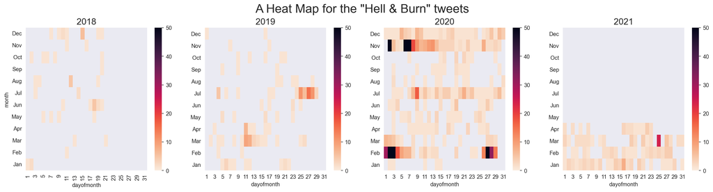

```python
burn_daily = df_burn.groupby(['year', 'dayofmonth', 'month']).size().reset_index(name='ntweets')

title = 'A Heat Map for the "Hell & Burn" tweets'
helpers.facet_heat(burn_daily, title, n_col=4, vmax=50)
```

### "Hell & Burn" tweets Peak Dates (ALL)

```python
burn_dates = df_burn.groupby(['date']).agg({'translated':'count', 'user_id': 'count'}).reset_index(
).rename(columns={'translated':'ntweets', 'user_id': 'n_users'}).sort_values('ntweets', ascending=False)

burn_dates.head(15)
```

|  | date | ntweets | n_users |
| --- | --- | --- | --- |
| 109 | 2020-02-02 | 222 | 222 |
| 246 | 2020-11-07 | 117 | 117 |
| 245 | 2020-11-06 | 107 | 107 |
| 241 | 2020-11-02 | 66 | 66 |
| 110 | 2020-02-03 | 64 | 64 |
| 125 | 2020-02-27 | 56 | 56 |
| 126 | 2020-02-28 | 32 | 32 |
| 108 | 2020-02-01 | 30 | 30 |
| 360 | 2021-03-25 | 24 | 24 |
| 247 | 2020-11-08 | 19 | 19 |
| 111 | 2020-02-04 | 18 | 18 |
| 188 | 2020-07-09 | 17 | 17 |
| 83 | 2019-07-29 | 15 | 15 |
| 127 | 2020-02-29 | 14 | 14 |
| 124 | 2020-02-26 | 13 | 13 |

```python
burn_dates = df_burn.date.value_counts().to_frame().reset_index().rename(columns={'index':'date',
                                                                                  'date':'ntweets'})
helpers.bar_peaks(burn_dates.head(2), '"Hell & Burn" Peak Contributions',
                  threshold=0, xlabel='tweets Creation Date')
```

[figure not shown]

# Most Repeated "Hell & Burn" tweets

```python
df_burn_sub.translated.value_counts().head()
```

```
they are:\n88 audio\n40 witnesses\nphotographs and a lot more evidence\nand yet they managed to blame the victim once again.\nwarner bros, fantastic beasts 3 and aquaman 2 piss me off, i really hope they go to hell #justiceforjohnnydepp\r                                    2
amber heard why the hell?\r                                                                                                                                                                                                                                                       2
amber heard in carolina herrera. a bit of hell in this look. 😏 #metgala #metgala2018 https://t.co/qlercb7qxj\r                                                                                                                                                                    1
they are:\n88 audio\n40 witnesses\nphotographs and a lot more evidence\nand yet they managed to blame the victim once again.\nwarner bros, fantastic beasts 3 and aquaman 2 are blowing me away, i really hope they go to hell #justiceforjohnnydepp https://t.co/8kbwsxvl3a\r    1
+ why the hell did you fire a person who is practically the main antagonist, and even in the middle of filming?!?\nand now what to do with all the gelbus paraphernalia?\nhow have the fans not devoured you yet ...\n#boycottfantasticbeasts\n#justiceforjohnnydepp\r            1
Name: translated, dtype: int64
```

```python
df = df_burn_sub[['created_at', 'days_diff', 'hours_diff', 'text', 'lang', 'translated', 'username']].head(60)
with pd.option_context('display.max_colwidth', None):
  display(df.reset_index(drop=True).style.set_properties(**{'text-align': 'left'}))
```

|  | created_at | days_diff | hours_diff | text | lang | translated | username |
| --- | --- | --- | --- | --- | --- | --- | --- |
| 0 | 2018-05-07 23:53:55 | 1169 | 17 | amber heard en carolina herrera. un poco de infierno en este look. 😏 #metgala #metgala2018 https://t.co/qlercb7qxj | es | amber heard in carolina herrera. a bit of hell in this look. 😏 #metgala #metgala2018 https://t.co/qlercb7qxj | GlossomMx Mag |
| 1 | 2018-06-13 18:20:10 | 1001 | 14 | @rubenrivera_r13 lo aprendí a la mala con amber heard, puto johnny depp, hasta la madrea | es | @rubenrivera_r13 i learned it the hard way with amber heard, fucking johnny depp, to hell | I'm okay now |
| 2 | 2018-06-22 17:30:41 | 2510 | 0 | johnny depp confia em sua descida ao inferno durante seu divórcio com amber heard – gala – video https://t.co/fwxaqx5rmo | pt | johnny depp trusts his descent into hell during his divorce from amber heard – gala – video https://t.co/fwxaqx5rmo | Telesphore Teta |
| 3 | 2018-06-23 08:54:36 | 894 | 16 | alcool, drogue, divorce... johnny depp raconte sa descente aux enfers: dans une interview, l’acteur s’est confié sur sa dépression, son divorce avec amber heard, son conflit avec ses anciens managers … | fr | alcohol, drugs, divorce … johnny depp recounts his descent into hell: in an interview, the actor confided in his depression, his divorce with amber heard, his conflict with his former managers or his … | 123 INFO |
| 4 | 2018-08-04 12:32:20 | 2281 | 1 | hasta el coño del tema johnny depp y amber heard, soy la única que piensa que esta tía lo tenía todo planeado? que fue solo a enamorarlo y a sacarle hasta la sangre? recordemos que por el simple hecho… | es | to hell with the johnny depp and amber heard theme, am i the only one who thinks this girl had it all planned? that she was the only one to make him fall in love and to get even his blood? let's remem… | Elfo Del Puto Infierno. |
| 5 | 2018-08-06 16:32:19 | 1193 | 10 | alguien me explica porque carajos prefieren creer ciegamente en las palabras de amber heard y ya? me explican porque mierda detonan la reputación de una persona solo por una acusación? | es | someone explain to me why the hell they prefer to blindly believe in the words of amber heard and that's it? explain to me why the shit detonate a person's reputation just for an accusation? | フェデリーコー 👽📻 |
| 6 | 2018-10-08 22:17:42 | 578 | 8 | me siguió otra amber heard hola. | es | i was followed by another amber heard hello. | Ramsés II. |
| 7 | 2018-11-21 00:09:29 | 4065 | 16 | aquaman (2018) hrají: jason momoa, amber heard, nicole kidman, dolph lundgren, william dafoe ... režie: james wan jestli už ani tato sestava nezafunguje, nechť jde celé slavné dc do háje 🧐 final trail… | cs | aquaman (2018) starring: jason momoa, amber heard, nicole kidman, dolph lundgren, william dafoe ... director: james wan if even this set doesn't work anymore, let the whole famous dc go to hell 🧐 fina… | Jiří Macich ml. |
| 8 | 2018-12-13 08:46:07 | 3369 | 19 | @iqbalarifyaakob 9.5 sbb storyline sama mcm movie cartoon punya(throne of atlantis) and cgi dia gempak nohorom plus amber heard hellok teruksz | in | @iqbalarifyaakob 9.5 sbb storyline sama mcm movie cartoon punya (throne of atlantis) and cgi dia gempak nohorom plus amber heard hellok teruksz | Muaz Mahdi |
| 9 | 2019-03-12 18:09:38 | 2783 | 15 | johnny depp et amber heard en guerre depuis le divorce, retour sur leur descente aux enfers https://t.co/6iwqvgjazq via @melty_fr | fr | johnny depp and amber heard at war since the divorce, back on their descent into hell https://t.co/6iwqvgjazq via @melty_fr | Roger |
| 10 | 2019-03-12 18:16:31 | 3224 | 19 | a carreira do johnny segue firme porque ele tem uma carreira, tem talento e uma legião de apoiadores. o que será que sobra pra vacamber heard? nem o diabo vai aguentar essa criatura lá no inferno #amb… | pt | johnny's career is going strong because he has a career, he has talent and a legion of supporters. what will be left for vacamber heard? not even the devil will put up with this creature in hell #ambe… | Sil belives in Johnny Depp 🏴‍☠️ |
| 11 | 2019-03-13 09:03:57 | 2885 | 20 | si es cierto, obviamente amber heard se puede ir a la mierda por rastrera y por ensuciar el metoo pero estáis todos diciendo muy rápido que hay que descancelar a johnny depp y??? creo recordar que hab… | es | if it's true, obviously amber heard can go to hell for creeping and dirtying the metoo but you are all saying very quickly that johnny depp should be decanceled and??? i seem to remember that there wa… | Nox 🌼✨ |
| 12 | 2019-03-13 14:12:43 | 3036 | 4 | amber heard kenapa sih?!?! | in | amber heard why the hell?!?! | S. M. |
| 13 | 2019-03-13 14:27:12 | 3135 | 11 | amber heard kenapa sih? | in | amber heard why the hell? | Mohammad Yusuf |
| 14 | 2019-03-15 13:00:39 | 1972 | 19 | va en enfer amber heard | ca | go to hell amber heard | 𝒌𝒉𝒂𝒍𝒆𝒆𝒔𝒊 |
| 15 | 2019-03-21 11:46:32 | 3233 | 12 | eu só queria dizer que a pessoa que inventou o esocial pode ir pro inferno junto com a amber heard e a clary fray/fairchild/morgenstern por ferrar com a vida das pessoas 🖕🖕🖕🖕🖕🖕🖕🖕 e que voltarei assim … | pt | i just wanted to say that the person who invented esocial can go to hell along with amber heard and clary fray/fairchild/morgenstern for screwing up people's lives 🖕🖕🖕🖕🖕🖕🖕🖕 and that i'll come back as … | Sil belives in Johnny Depp 🏴‍☠️ |
| 16 | 2019-04-12 16:18:17 | 3255 | 17 | o que tá faltando pra amber heard fritar no inferno? se for um empurrãozinho eu me ofereço https://t.co/zem8zshuyn | pt | what's missing for amber heard to fry in hell? if it's a little push i offer https://t.co/zem8zshuyn | Sil belives in Johnny Depp 🏴‍☠️ |
| 17 | 2019-04-17 10:51:03 | 2759 | 22 | a maldita da amber heard agora veio com essas histórias novas contra o johnny, que só de ler dá pra saber que são mentira. pqp essa mulher não tem noção mesmo. se contradizendo o tempo todo! vai à mer… | pt | damn amber heard now came up with these new stories against johnny, which just by reading you can tell they're a lie. this woman has no idea at all. contradicting yourself all the time! go to hell. ht… | Jack ☆ ; 🏐🖤🧡 |
| 18 | 2019-05-05 17:50:15 | 220 | 22 | @ceekline ils ont une place à côté d'amber heard en enfer ces fdp | fr | @ceekline they have a place next to amber heard in hell these fdps | Altavoz🦏 |
| 19 | 2019-05-17 02:14:36 | 1768 | 22 | a carreira do johnny depp está morta e esse momento é só meu aaaaaaaaaaaaaaaaaaaaaaaaaaaaaaaaaaaaaaa 0% de aprovação no rotten e 37 no metacritic vai pro inferno assediador e espancador de mulher, vai… | pt | the career of johnny depp is dead and this moment is only my aaaaaaaaaaaaaaaaaaaaaaaaaaaaaaaaaaaaaaa 0% approval in the rotten and 37 in the metacritic goes to the hell ascediator and spanking woman, … | FÉ FORÇA E AMOR AO REI PAULO GUSTAVO |
| 20 | 2019-07-27 12:42:02 | 3132 | 3 | johnny depp: amber heard mi ha bruciato in volto con una sigaretta - - #johnny #depp: #amber #heard #bruciato https://t.co/ubee65hdld | it | johnny depp: amber heard burned my face with a cigarette - - #johnny #depp: #amber #heard #burnt https://t.co/ubee65hdld | Zazoom Social News |
| 21 | 2019-07-27 16:26:55 | 3962 | 20 | johnny depp alega que amber heard queimou o rosto dele com um cigarro! https://t.co/thrvzrsiye https://t.co/gxxr1r3khp | pt | johnny depp claims amber heard burned his face with a cigarette! https://t.co/thrvzrsiye https://t.co/gxxr1r3khp | Estrelando |
| 22 | 2019-07-27 22:41:07 | 2964 | 10 | johnny depp: "amber heard mi ha bruciato in volto con una sigaretta" https://t.co/8j7qkavm7s | it | johnny depp: "amber heard burned my face with a cigarette" https://t.co/8j7qkavm7s | informazione cultura |
| 23 | 2019-07-28 07:30:00 | 2669 | 20 | #johnnydepp: "amber heard mi ha bruciato in volto con una sigaretta" https://t.co/jsq9vw6y9n | it | #johnnydepp: "amber heard burned my face with a cigarette" https://t.co/jsq9vw6y9n | L'attimo fuggente - Lamescolanza |
| 24 | 2019-07-28 07:36:39 | 1133 | 10 | https://t.co/dxafvpcgy9 johnny depp: "amber heard mi ha bruciato in volto con una sigaretta" - il decoder | it | https://t.co/dxafvpcgy9 johnny depp: "amber heard burned my face with a cigarette" - the decoder | Retewebitalia.NET |
| 25 | 2019-07-28 17:57:51 | 3765 | 21 | johnny deppin kohuliitosta uusia järkyttäviä väitteitä: ex-vaimo amber heard poltti näyttelijän kasvoja tupakalla, katkaisi palan sormesta https://t.co/ycqk1bcvnd | fi | johnny depp's riot of new shocking allegations: ex-wife amber heard burned the actor's face with tobacco, cut off a piece of her finger https://t.co/ycqk1bcvnd | Ilta-Sanomat |
| 26 | 2019-07-28 18:26:57 | 1015 | 19 | johnny deppin kohuliitosta uusia järkyttäviä väitteitä: ex-vaimo amber heard poltti näyttelijän kasvoja tupakalla, katkaisi palan sormesta toi akka on iha hullu. onneksi herramme ja vapahtajamme ei en… | fi | johnny depp's riot of new shocking allegations: ex-wife amber heard burned the actor's face with tobacco, cut off a piece of her finger toi akka is crazy. fortunately, our lord and savior no longer as… | Henri Koskela |
| 27 | 2019-07-29 06:35:26 | 2506 | 15 | johnny deppin kohuliitosta uusia järkyttäviä väitteitä: ex-vaimo amber heard poltti näyttelijän kasvoja tupakalla, katkaisi palan sormesta https://t.co/tcr3phsygh | fi | johnny depp's riot of new shocking allegations: ex-wife amber heard burned the actor's face with tobacco, cut off a piece of her finger https://t.co/tcr3phsygh | Heidi-Maaria Leinonen |
| 28 | 2019-07-29 11:16:21 | 1633 | 22 | johnny deppin kohuliitosta uusia järkyttäviä väitteitä: ex-vaimo amber heard poltti näyttelijän kasvoja tupakalla, katkaisi palan sormesta https://t.co/zscpt0xzsq | fi | johnny depp's riot of new shocking allegations: ex-wife amber heard burned the actor's face with tobacco, cut off a piece of her finger https://t.co/zscpt0xzsq | Carita Vuoristo |
| 29 | 2019-07-29 15:23:49 | 3574 | 2 | jhonny depp asegura que amber heard le quemó la cara; #entérate aquí una foto de la supuesta agresión ➡️ https://t.co/ins0lk9rrf https://t.co/nezbobqu6x | es | jhonny depp assures that amber heard burned his face; #find out here a photo of the alleged aggression ➡️ https://t.co/ins0lk9rrf https://t.co/nezbobqu6x | Diario Presente |
| 30 | 2019-07-29 17:57:40 | 4050 | 21 | johnny depp: amber heard quemó mi cara con un cigarrillo https://t.co/zj3vzsaoql vía @farandulista #johnnydepp #amberheard #pelea | es | johnny depp: amber heard burned my face with a cigarette https://t.co/zj3vzsaoql via @farandulista #johnnydepp #amberheard #fight | Farandulista |
| 31 | 2019-08-30 01:21:51 | 3528 | 20 | #benedictcumberbatch como hades me genera un poco de entusiasmo pero si siguen que amber heard sea megara la verdad es que todo se va al cañito para mí | es | #benedictcumberbatch as hades generates a little enthusiasm in me but if they continue that amber heard is megara, the truth is that everything goes to hell for me | Gabriela |
| 32 | 2019-09-21 19:27:15 | 1212 | 5 | @cenabiallah cennete ak sakalli dedeler ile içinde ne olduğu belli olmayan carsaflilari alıyorsun. bak cehenneme avukatlar, siyasiler, doktorlar, aktörler ! amber heard bile cehennemde olacak dimi dog… | tr | @cenabiallah you are taking the white-bearded grandfathers and the linen people who don't know what's inside. to hell with lawyers, politicians, doctors, actors! even amber heard will be in hell right… | dArknEsS |
| 33 | 2019-11-18 00:54:29 | 3148 | 12 | hola sólo quiero decirles que amber heard es una masa y todos ustedes se pueden ir a la mierda. tkm bb stay strong ahre | es | hello, i just want to tell you that amber heard is a mass and all of you can go to hell. tkm bb stay strong ahre | Agustina |
| 34 | 2020-01-11 20:57:33 | 2677 | 8 | amber heard poi facci sapere perchè diavolo maltrattavi johnny depp che è un cucciolino #cepostaperte | it | amber heard then let us know why the hell you mistreated johnny depp who is a #cepostaperte puppy | mars☁ |
| 35 | 2020-02-01 13:41:06 | 1572 | 20 | ça n'a malheureusement pas autant eu autant de visibilité que les accusations sur depp, mais heard lui a fait vivre un enfer, l'insultant fréquemment (devant ses proches, parfois) et le frappant (il é… | fr | unfortunately, it didn't have as much visibility as the accusations about depp, but heard gave him hell, frequently insulting him (in front of his relatives, sometimes) and hitting him (he had appeare… | JΛCK |
| 36 | 2020-02-01 14:18:30 | 2577 | 17 | amber ta descente aux enfers j’espère qu’elle sera horrible et interminable pour toi! #justiceforjohnnydepp | fr | amber your descent into hell i hope it will be horrible and endless for you! #justiceforjohnnydepp | Lilou ⚽️ FC Keylor Navas! |
| 37 | 2020-02-01 14:20:40 | 315 | 23 | de paradis à l'enfer. #justiceforjohnnydepp | fr | from heaven to hell. #justiceforjohnnydepp | Lönnrot |
| 38 | 2020-02-01 14:39:39 | 3374 | 19 | putain mais je le savais depuis toujours j’ai jamais réussi a stand du côté d’amber heard parce que les témoignages de son ex, ses procès précédents, son instabilité amoureuse en face de celle stabili… | fr | damn, but i've always known it, i've never managed to stand on amber heard's side because the testimonies of her ex, her previous trials, her love instability in front of that stability of depp-paradi… | petit poney fringant 🦄 |
| 39 | 2020-02-01 17:33:05 | 3692 | 23 | c’est à cause de ce mensonge que l’on a perdu le capitaine jack sparrow, qu’elle aille en enfer. #justiceforjohnnydepp | fr | it is because of this lie that we lost captain jack sparrow, may she go to hell. #justiceforjohnnydepp | 卡蒂贾 |
| 40 | 2020-02-01 17:40:01 | 465 | 5 | ici le womenaretrash est totalement mérité cet connasse quel pourrisse dans l'oublie ! #justiceforjohnnydepp | fr | here the womenaretrash is totally deserved this bitch which rots into oblivion! #justiceforjohnnydepp | Yugseto |
| 41 | 2020-02-01 18:27:32 | 3300 | 21 | ojalá amber heard se pudra en la cárcel. | es | i hope amber heard rots in jail. | Ru |
| 42 | 2020-02-01 18:41:11 | 3431 | 8 | je crois qu’amber heard s’est grillée toute seule , que le johnny en " bon con " s’est fait baiser : disney l’a destitué de #sparrow pour rien : heureusement qu’il y a les enregistrements audio ... #j… | fr | i think amber heard burned herself, that johnny in "good con" got fucked: disney removed him from #sparrow for nothing: fortunately there are audio recordings... #justiceforjohnnydepp | Olivier Laurent ⭐️⭐️ |
| 43 | 2020-02-01 22:26:12 | 3162 | 10 | amber heard j’veux qu’elle paye jusqu’au dernier jour d’sa putain de vie, et j’espère que les flammes de l’enfer seront bien douloureuses pour sa vieille carcasse de merde #justiceforjohnnydepp | fr | amber heard i want her to pay until the last day of her fucking life, and i hope the flames of hell will be very painful for her old shitty carcass #justiceforjohnnydepp | eli 𝚒𝚜 𝚒𝚗 🇰🇷 |
| 44 | 2020-02-01 23:56:27 | 3551 | 0 | eu podia fazer um baita discurso aqui, mas vou apenas simplificar para: espero que você vá pras profundezas mais podres do inferno, amber heard. e que leve teus burro de carga junto. se precisar de aj… | pt | i could make a big speech here, but i'll just simplify it to: i hope you go to the filthiest depths of hell, amber heard. and take your pack donkey with you. if you need help getting there... that's w… | Sil belives in Johnny Depp 🏴‍☠️ |
| 45 | 2020-02-02 00:13:55 | 2308 | 9 | por mais que ouvir tudo isso dilacere meu coração, fico aliviada por saber que agora ser a mais fácil de todos verem o que sempre vi. #justiceforjohnnydepp queime no inferno ah. https://t.co/fp5iahpe9… | pt | as much as hearing all this breaks my heart, i'm relieved to know that it's now the easiest of all to see what i've always seen. #justiceforjohnnydepp burn in hell ah. https://t.co/fp5iahpe9d | Gleicy Rodrigues 🍩 |
| 46 | 2020-02-02 00:29:35 | 2308 | 9 | é incrível como ainda tem gente passando pano p amber heard. nem ouvindo a própria assumir o que fez as pessoas conseguem ficar do lado da vítima por causa do gênero! #justiceforjohnnydepp queime no i… | pt | it's amazing how there are still people passing cloth to amber heard. not even hearing her own admit what she did can people take the side of the victim because of gender! #justiceforjohnnydepp burn i… | Gleicy Rodrigues 🍩 |
| 47 | 2020-02-02 01:17:17 | 2983 | 20 | amber heard kenapa sih? | in | amber heard why the hell? | Wakhida 🌜 |
| 48 | 2020-02-02 02:24:10 | 3585 | 10 | no entiendo por qué chucha polarizan la violencia intrafamiliar. da lo mismo si fue hombre o mujer la víctima!!. paren de dividir wn!. es una persona la afectada y punto!!! #justiceforjohnnydepp | es | i don't understand why the hell they polarize domestic violence. it does not matter whether the victim was a man or a woman!! stop dividing wn!. it is a person affected and period! #justiceforjohnnyde… | #ChilenoYqué? |
| 49 | 2020-02-02 02:54:03 | 1006 | 5 | es una maldita desquiciada.... como puede ser tan cruel con el que le dio todo y lo principal su amor, y asi lo agradece dañando su imagen ,por mi que se pudra en la cárcel #justiceforjohnnydepp | es | she is a fucking freak.... how can she be so cruel to him? that she gave him everything and the main thing was her love, and so she thanks him by damaging her image, for me she rots in jail #justicefo… | ꒰꒰ ❛ ❏ Dream. ¡!~ ⌒⌒ |
| 50 | 2020-02-02 04:30:55 | 53 | 1 | #justiceforjohnnydepp no le creo ni a la mitad de los que ahora le creen y que hace unos años lo estaban cancelando, mandando a la mierda varias de sus películas de paso. no les creo. | es | #justiceforjohnnydepp i don't believe even half of those who now believe him and that a few years ago they were canceling it, sending several of his passing movies to hell. i don't believe them. | M O S S J U R O rewatching Alabasta bc reasons |
| 51 | 2020-02-02 04:36:21 | 53 | 1 | #justiceforjohnnydepp nada señores. aquí la mitad se estaba pajeando a dos manos con amber heard cuando salió aquaman. ahora pretendamos que no estabamos endiosando a ésta mujer mientras todas las fra… | es | #justiceforjohnnydepp nothing gentlemen. half here were two-handed jerking off with amber heard when aquaman came out. now let's pretend we weren't deifying this woman while all the depp franchises we… | M O S S J U R O rewatching Alabasta bc reasons |
| 52 | 2020-02-02 04:45:56 | 214 | 10 | que a carreira da amber queime no fogo do submundo #justiceforjohnnydepp | pt | may amber's career burn in the fires of the underworld #justiceforjohnnydepp | Lucas santiago08 |
| 53 | 2020-02-02 05:02:30 | 3934 | 1 | este hilo empieza en arameo pero es oro puro. siempre le creí a johnny. espero que amber sea canceladisima y que se pudra en la cárcel. #justiceforjohnnydepp | es | this thread begins in aramaic but it is pure gold. i always believed johnny. i hope amber is so canceled and she rots in jail. #justiceforjohnnydepp | Cami - Taylor's Version |
| 54 | 2020-02-02 05:04:21 | 3526 | 4 | amber heard, ojalá ardas en el infierno | es | amber heard, i hope you burn in hell | pichón (Taylor’s Version) 🐦 |
| 55 | 2020-02-02 06:52:43 | 9 | 2 | #justiceforjohnnydepp 贱女人去死吧！！！真是我这辈子见过最臭的蛆🙂别让奶奶看见你，要不然你都不知道是怎么死的🙂🙂🙂 看见我男人是你这种贱🐔八百年修来的福分😊😊😊现在下地狱吧 | zh | #justiceforjohnnydepp die bitch! ! ! it's the most smelly maggot i've ever seen in my life 🙂 don’t let your grandma see you or you won’t know how you died 🙂 🙂 🙂 seeing that my man is a bitch like you … | 子午云 |
| 56 | 2020-02-02 07:05:49 | 3570 | 9 | ojalá te quemes en el infierno perra amber #justiceforjohnnydepp | es | i hope you burn in hell bitch amber #justiceforjohnnydepp | danybb |
| 57 | 2020-02-02 08:31:08 | 3926 | 19 | putain, je l'ai toujours dit, cette meuf, elle avait une tête qui ne me revenait pas. ça se voit, elle sait manipuler beh voilà, bienvenue en enfer sale tchoin. #justiceforjohnnydepp | fr | damn, i've always said it, this girl, she had a face that didn't come back to me. it shows, she knows how to manipulate well here it is, welcome to hell you dirty tchoin. #justiceforjohnnydepp | Flavya |
| 58 | 2020-02-02 09:17:57 | 305 | 12 | amber heard quemó a johnny depp con un cigarrillo, le cortó un dedo y se burló de la muerte de su madre. pobre mujer maltratada, ahora vais y la defendéis #justiceforjohnnydepp | es | amber heard burned johnny depp with a cigarette, cut off his finger and made fun of his mother's death. poor abused woman, now you go and defend her #justiceforjohnnydepp | Nataxa |
| 59 | 2020-02-02 11:28:36 | 2656 | 15 | ебучие фемки совсем охуели, гореть вам в аду, жирные уебки с волосатыми подмышками и обвисшими сиськами!!! #justiceforjohnnydepp | ru | fucking fems are completely fucked up, you burn in hell, fat fuckers with hairy armpits and saggy boobs!!! #justiceforjohnnydepp | Neil |

# Top Users Commented with "Hell & Burn" keywords

```python
burn_users = df_burn_sub.username.value_counts().to_frame().reset_index().rename(columns={'index':'username',
                                                                                  'username':'ntweets'})
helpers.barh(burn_users.head(15), '"Hell & Burn" Top Commented Users', threshold=0, c=0)
```

[figure not shown]

```python
set_burn_users = set(burn_users.username.head(15))
```

```python
helpers.contr_peaks(df_tweets, "Sil belives in Johnny Depp 🏴‍☠️", n=2, threshold=0)
```

[figure not shown]

```python
df_threat.query(" username == 'Sil belives in Johnny Depp 🏴‍☠️' ").translated.value_counts().head()
```

```
damn\nfucked slut\namber heard please join the freeform studies and make my life easier to explode all this shit at once\r                                                                                                                                   1
my job wouldn't be so miserable if there wasn't e-social, so i curse the unhappy who invented this shit from hell.\ntake the amber heard and go drown in loch ness https://t.co/bmulfnzmjj\r                                                                 1
johnny depp vents privately to a friend about his abuser and you wish him dead.\n\namber heard steals the story of a real victim of sexual abuse to lie and use in court for her own benefit and you ignore it because she is a woman.\n\ndo me a favor\r    1
why do people ignore this completely??\n\nthis is the real johnny depp, who i love, who i support, who i believe in forever!\n\namber heard and amberfan to hell\n\n#justiceforjohnnydepp #wearewithyoujohnnydepp https://t.co/gw2utiaqyq\r                  1
3 days of:\n- i didn't hit amber heard under any circumstances.\n- okay, but you used drugs.\n\nhello my father\n#wearewithyoujohnnydepp #justiceforjohnnydepp\n\nfuck you the sun and amber https://t.co/xflt2yil5k\r                                       1
Name: translated, dtype: int64
```

```python
helpers.contr_peaks(df_tweets, "Andy ⚡", n=2, threshold=0)
```

[figure not shown]

```python
df_threat.query(" username == 'Andy ⚡' ").translated.value_counts().head()
```

```
they are:\n88 audio\n40 witnesses\nphotographs and a lot more evidence\nand yet they managed to blame the victim once again.\nwarner bros, fantastic beasts 3, and aquaman 2 piss me off, i really hope they go to hell #justiceforjohnnydepp https://t.co/xipic8jiuv https://t.co/51f9vyraqu\r             …
@roy_prez @capa_invisible they are:\n88 audio\n40 witnesses\nphotographs and a lot more evidence\nand yet they managed to blame the victim once again.\nwarner bros, fantastic beasts 3 and aquaman 2 are fucking me, i really hope they go to hell #justiceforjohnnydepp https://t.co/xipic8jiuv https://t.…
@potterheadclub they are:\n88 audio\n40 witnesses\nphotographs and a lot more evidence\nand yet they managed to blame the victim once again.\nwarner bros, fantastic beasts 3 and aquaman 2 are fucking me, i really hope they go to hell #justiceforjohnnydepp https://t.co/xipic8jiuv https://t.co/ysro8in…
@cloak_invisible they are:\n88 audio\n40 witnesses\nphotographs and a lot more evidence\nand yet they managed to blame the victim once again.\nwarner bros, fantastic beasts 3 and aquaman 2 are fucking me, i really hope they go to hell #justiceforjohnnydepp https://t.co/xipic8jiuv https://t.co/e8wikh…
@eiprofeta they are:\n88 audio\n40 witnesses\nphotographs and a lot more evidence\nand yet they managed to blame the victim once again.\nwarner bros, fantastic beasts 3, and aquaman 2 piss me off, i really hope they go to hell #justiceforjohnnydepp https://t.co/xipic8jiuv https://t.co/hcvaxpgsja\r  …
Name: translated, dtype: int64
```

## Crime & Jail

> > - Kill & Death
> > - Hell & Burn
> > - **Crime & Jail**
> > - All Threat
> > - Threat Users Contributions

```python
crime_sub = {'criminal', 'her crime', 'deserve lethal punish', 'be punished', 'deserves every punishment',
             'punish her', 'her punish', 'punish amber', 'punish the abuser', 'heard being punished',
             'been punished', 'jail', 'prison', 'heard deserve', 'abuser deserve', 'she deserve',
             'what you deserve', 'karma'}
```

```python
df_crime_sub =df_threat[df_threat.translated.str.contains('|'.join(crime_sub))]
print(f'{df_crime_sub.shape[0]} contributions, made by {df_crime_sub.username.nunique()} Users, In {df_crime_sub.lang.nunique()} Languages')
df_crime_sub.head(1)
```

```
1663 contributions, made by 1482 Users, In 31 Languages
```

|  | user_description | username | n_followers | text | profile_banner_url | user_location | user_id | user_created_at | profile_image_url | n_friends | ... | tweet_id | user_screen_name | date | year | month | dayofmonth | diff | days_diff | translated | hours_diff |
| --- | --- | --- | --- | --- | --- | --- | --- | --- | --- | --- | --- | --- | --- | --- | --- | --- | --- | --- | --- | --- | --- |
| 98 | meu sonho é morrer bebado dentro de uma casa a... | REI DAS RUAS ռամոն | 606 | @gabrielatrezzi o ed westwick ta sendo acusado... | https://pbs.twimg.com/profile_banners/93204170... | NaN | 932041704416440320 | 2017-11-19 00:23:53 | http://pbs.twimg.com/profile_images/1348634617... | 4727 | ... | 949702911721951233 | batmadufuturo | 2018-01-06 | 2018 | Jan | 6 | 48 days 17:39:20 | 48 | @gabrielatrezzi ed westwick is being accused b... | 17 |

1 rows × 24 columns

### A Heat Map for the "Crime & Jail" tweets (ALL)

[figure not shown]

```python
crime_daily = df_crime.groupby(['year', 'dayofmonth', 'month']).size().reset_index(name='ntweets')

title = 'A Heat Map for the "Hell & Burn" tweets'
helpers.facet_heat(crime_daily, title, n_col=4, vmax=200)
```

### "Crime & Jail" tweets Peak Dates (ALL)

```python
crime_dates = df_crime.groupby(['date']).agg({'translated':'count', 'user_id': 'count'}).reset_index(
).rename(columns={'translated':'ntweets', 'user_id': 'n_users'}).sort_values('ntweets', ascending=False)

crime_dates.head(15)
```

|  | date | ntweets | n_users |
| --- | --- | --- | --- |
| 191 | 2020-02-02 | 706 | 706 |
| 401 | 2020-11-06 | 461 | 461 |
| 402 | 2020-11-07 | 324 | 324 |
| 397 | 2020-11-02 | 228 | 228 |
| 531 | 2021-03-25 | 205 | 205 |
| 192 | 2020-02-03 | 124 | 124 |
| 190 | 2020-02-01 | 114 | 114 |
| 242 | 2020-04-08 | 88 | 88 |
| 403 | 2020-11-08 | 81 | 81 |
| 243 | 2020-04-09 | 75 | 75 |
| 524 | 2021-03-18 | 61 | 61 |
| 408 | 2020-11-13 | 57 | 57 |
| 404 | 2020-11-09 | 50 | 50 |
| 559 | 2021-04-22 | 41 | 41 |
| 407 | 2020-11-12 | 40 | 40 |

```python
crime_dates = df_crime.date.value_counts().to_frame().reset_index().rename(columns={'index':'date',
                                                                                  'date':'ntweets'})
helpers.bar_peaks(crime_dates.head(2), '"Crime & Jail" Peak Contributions',
                  threshold=0, xlabel='tweets Creation Date')
```

[figure not shown]

# Most Repeated "Crime & Jail" tweets

```python
df_crime_sub.translated.value_counts().head(10)
```

```
#famadd yay! amber heard could go to prison for false evidence and testimony https://t.co/tdqranawac\r                                                                                                                                                                                            2
after the actress assured that she had been a victim of violence during her marriage, it seems that now she is the one who would go to prison. #amberheardisanabuser\nhttps://t.co/hvkuepfggj\r                                                                                                   2
amber heard could go to jail for lying about johnny depp https://t.co/qd74glc42n https://t.co/sotwj1wd06\r                                                                                                                                                                                        2
@gabrielatrezzi ed westwick is being accused by three women of rape, depp assaulted amber heard and paid compensation, both are criminals, but not in the same degree of danger\r                                                                                                                 1
amber heard suffered more than jesus she deserves this moment of victory\r                                                                                                                                                                                                                        1
i completely agree with the fact of protecting a woman against all forms of abuse but not at the expense of a man who has nothing to do in this case johnny depp.\n\ndamn amber heard deserves to go to jail but she's playing the wrong victim card.\r                                           1
johnny depp is one of the most talented and incredible actors of recent years, a good, kind and above all innocent man, karma will turn against you i'm sure #justiceforjohnnydepp #johnnydeppisinnocent\r                                                                                        1
@shotorice i am pissed off, i hope that amber heard you burn in hell, i believe in karma, it must die\r                                                                                                                                                                                           1
johnny depp has presented evidence that exculpates him from abuse, yet they are throwing him out of each of his sagas as if he were a plague.\ni hope karma works out well for amber heard and one day they do the same thing to her that she is doing to this person. #justiceforjohnnydepp\r    1
@achakpom @thenamesq @nunuejiogu karma bites\n#justiceforjohnnydepp\r                                                                                                                                                                                                                             1
Name: translated, dtype: int64
```

```python
df = df_crime_sub[['created_at', 'days_diff', 'hours_diff', 'text', 'lang', 'translated', 'username']].head(60)
with pd.option_context('display.max_colwidth', None):
  display(df.reset_index(drop=True).style.set_properties(**{'text-align': 'left'}))
```

|  | created_at | days_diff | hours_diff | text | lang | translated | username |
| --- | --- | --- | --- | --- | --- | --- | --- |
| 0 | 2018-01-06 18:03:13 | 48 | 17 | @gabrielatrezzi o ed westwick ta sendo acusado por tres mulheres de estupro, o depp agrediu a amber heard e pagou indenização, ambos são criminosos, mas não no mesmo grau de periculosidade | pt | @gabrielatrezzi ed westwick is being accused by three women of rape, depp assaulted amber heard and paid compensation, both are criminals, but not in the same degree of danger | REI DAS RUAS ռամոն |
| 1 | 2018-01-08 19:36:50 | 18 | 18 | amber heard merece ser protegida de johnny depp e essas fãs nojentas dele | pt | amber heard deserves to be protected from johnny depp and his disgusting fans | en |
| 2 | 2018-02-20 23:15:02 | 2525 | 5 | prima stagione di criminal minds e c'è amber heard che ci sta provando con reid | it | criminal minds season 1 and amber heard is hitting on reid | Ylenia |
| 3 | 2018-03-31 20:44:20 | 3140 | 4 | @burvton @apocalypvse non li abbiamo. però basta scorrere le pagine di questo blog https://t.co/jeggbkfr30 dove sono raccolte tutte le informazioni sulla condotta criminale (e il poco rispetto e manca… | it | @burvton @apocalypvse we don't have them. but just scroll through the pages of this blog https://t.co/jeggbkfr30 where all the information on the criminal conduct (and the little respect and general l… | IFOD |
| 4 | 2018-04-01 21:20:22 | 1421 | 16 | je sais pas si je suis plus jalouse de matthew gray gubler ou d'amber heard dans la scène dans la piscine d'esprits criminels... | fr | i don't know if i'm more jealous of matthew gray gubler or amber heard in the pool of criminal minds scene... | jcrois que c'est l'heure ding dong |
| 5 | 2018-04-01 21:37:35 | 1272 | 1 | esprits criminels a quand même eu dans un même épisode amber heard et katheryn winnick aka lagertha dans vikings | fr | criminal minds still had in the same episode amber heard and katheryn winnick aka lagertha in vikings | Emma - S&B spoilers |
| 6 | 2018-06-14 19:01:50 | 2682 | 17 | amber heard merece não só o mar como todo o oceano mesmo https://t.co/j1tvjyw2ni | pt | amber heard deserves not only the sea but the entire ocean https://t.co/j1tvjyw2ni | o rosas |
| 7 | 2018-06-23 13:57:26 | 3164 | 17 | giuro che questa sarà l'ultima cosa che dirò su criminal minds ma... mi sono accorta solo ora, dopo milioni di anni che guardo questa serie, che lila archer e' amber heard wtf https://t.co/dcbhevye4l | it | i swear this will be the last thing i'll say about criminal minds but ... i only realized now, after million years watching this series, that lila archer is amber heard wtf https://t.co/dcbhevye4l | agent sara 🧣aot 139 spoilers |
| 8 | 2018-07-20 00:00:55 | 3216 | 0 | amber heard merece más reconocimiento man | es | amber heard deserves more recognition man | 🪐 |
| 9 | 2018-08-01 10:09:09 | 1397 | 9 | #ibelievehim johnny depp rei sensato! silêncio, exílio, astúcia e esse é o momento da verdade aparecer! amber heard vai ter o q merece, esse momento é nosso! golpista chegou sua hora https://t.co/dcsc… | pt | #ibelievehim johnny depp king wise! silence, exile, cunning and this is the moment of truth to appear! amber heard will get what she deserves, this moment is ours! scammers your time has come https://… | Angell Mari💎 |
| 10 | 2018-08-02 13:05:06 | 22 | 19 | @carborata sauf que johnny depp n'a rien fait. il n'a pas touché un seul cheveu d'amber heard. il y a des photos d'époques qui montraient johnny avec des blessures au nez et au cou quand il était enco… | fr | @carborata except johnny depp didn't do anything. he didn't touch a single hair of amber heard. there are photos from the era that showed johnny with nose and neck injuries when he was still with a. h… | Nasuta Diao |
| 11 | 2018-08-08 14:12:52 | 2210 | 16 | johnny depp -maltrataba a amber heard -y esta probado -pero sigue encontrando trabajo -sigue teniendo fans -y no esta en la carcel -de verdad no apoyeis mas a este señoro | es | johnny depp -mistreated amber heard -and it's proven -but still find work - still have fans -and he is not in jail - really do not support this gentleman anymore | sandra༄ |
| 12 | 2018-08-16 19:21:32 | 1698 | 0 | cara delevingne amber heard et ashley benson dans le mm film fin fo absolument pas kjaille le voir au ciné paske jv très clairement avoir un orgasme devant l'écran | fr | cara delevingne amber heard and ashley benson in the mm fin film fo absolutely not kjaille see it at the cinema paske jv very clearly have an orgasm in front of the screen | Judith |
| 13 | 2018-08-18 08:31:39 | 803 | 17 | @garanceamarante @tatiebertney je ne crois pas qu'il y en ai moins mtn.🤔 regarde, johnny depp qui a quitté v. paradis pour amber heard. aussi, un chef de parti populiste anglais qui a plaqué sa femme … | fr | @garanceamarante @tatiebertney i don't think there are less mtn.🤔 look, johnny depp who left v. paradis for amber heard. also, an english populist party leader who dumped his wife at christmas for a 2… | Diana |
| 14 | 2018-08-29 20:27:23 | 282 | 22 | a lei do karma é lei universal, e tudo que vai volta, e não há verdade que um dia não venha à tona #justiceforjohnnydepp | pt | the law of karma is universal law, and what goes around comes around, and there is no truth that won't come out one day #justiceforjohnnydepp | Liz |
| 15 | 2018-08-30 22:21:04 | 2627 | 19 | condenado a prisión el ‘hacker’ que filtró las fotos de jennifer lawrence: el hacker ya habia obtenido fotografias e informacion personal de famosas como jennifer lawrence kate upton, amber heard o av… | es | sentenced to prison the 'hacker' who leaked the photos of jennifer lawrence: the hacker had already obtained photographs and personal information of celebrities such as jennifer lawrence kate upton, a… | Henry Escobar 🏡 |
| 16 | 2018-09-15 01:45:04 | 1467 | 7 | estoy viendo criminal minds y katheryn winnick y amber heard aparencen en el mismo episodio | es | i'm watching criminal minds and katheryn winnick and amber heard appear in the same episode | genesis |
| 17 | 2018-10-03 13:48:41 | 3056 | 6 | クリミナル・マインドs1の恋に落ちた捜査官、ロマンチックなシーンがあり、ほんと素敵！ リードの職務への真面目さ、魅力的で自由なライラとの対比、最高and最高〜 ライラ役はamber heard 美人だ | ja | criminal minds s1's fallen in love investigator, there is a romantic scene, it's really nice! reed's seriousness in his duties, attractive and free contrast with lyra, the best and the best ~ the role… | ega_miu |
| 18 | 2018-11-04 01:06:41 | 707 | 13 | @bellatrirx então procure amber heard para levar para prisão, uma vez que ela bateu na namorada, bateu no johnny depp, chantageou, mentiu, cagou na cama de johnny, falsificou documentos e muitos outro… | pt | @bellatrx then look for amber heard to take to prison as she beat her girlfriend, beat up johnny depp, blackmailed, lied, shit in johnny's bed, falsified documents and many other reasons | Nicole sztin |
| 19 | 2018-11-14 17:16:44 | 926 | 0 | @astridprce @alissaaan amber heard mentiu, ela mancha a imagem das mulheres que sofrem todos os dias, das mulheres que realmente sofrem um inferno dentro de casa, essas sim precisam de ajuda e o marid… | pt | @astridprce @alissaaan amber heard lied, she tarnishes the image of women who suffer every day, of women who really suffer hell at home, these do need help and their husband/boyfriend deserves to go t… | nana naninha; |
| 20 | 2018-11-15 09:46:00 | 1552 | 14 | @stehlblueten du gibst dem gewalttäter dein geld ... und gibst dann doppelt so viel geld an opfer. 27.06.2017: sein ex-management bestätigt: er hat amber heard geschlagen! 3.10.2018: keine gewalt gege… | de | @stehlblueten you give the violent criminal your money... and then give twice as much money to the victim. 06/27/2017: his ex-management confirms: he beat amber heard! 10/3/2018: no violence against a… | K.-H. Zimmer: Wir brauchen #ZeroCovid-Strategie! |
| 21 | 2018-12-02 14:17:44 | 882 | 8 | "viva johnny depp!! es guapísimo, me encanta doctor who, loki es mi crush, y para q lo sepáis: amber heard es una zorra y debería de estar en la cárcel" 😂😂😂😂😂 he exagerado todo un poco sorry | es | "long live johnny depp!! he's gorgeous, i love doctor who, loki is my crush, and just so you know: amber heard is a bitch and should be in jail" 😂😂😂😂😂 i exaggerated everything a bit sorry | Nolanyder⚫ |
| 22 | 2018-12-08 01:17:20 | 189 | 21 | aquaman merece ser enaltecido jason momoa merece ser enaltecido amber heard merece ser enaltecida nicole kidman e patrick wilson merecem ser enaltecidos james wan merece ser enaltecido a dc merece ser… | pt | aquaman deserves to be praised jason momoa deserves to be praised amber heard deserves to be praised nicole kidman and patrick wilson deserve to be praised james wan deserves to be praised dc deserves… | maju (taylor’s version) |
| 23 | 2018-12-08 09:08:36 | 480 | 3 | @janssensnuf het gaat nergens meer over, suffe hypocrieten. amber heard heeft in 2009 ook een nachtje in de cel doorgebracht wegens mishandeling van haar ex-vrouw. ze kreeg twee jaar voorwaardelijk. e… | nl | @janssensnuf it's not about anything anymore, you stupid hypocrites. amber heard also spent a night in jail in 2009 for assaulting her ex-wife. she was given two years' probation. and arrested in 2003… | Amy |
| 24 | 2018-12-13 17:35:21 | 1388 | 19 | @bchartsbc caralho, como vcs são escrotos, ele deu rt em um comentário de uma menina falando q "ela quase q merecia" e vcs fazem um post falando "léo lins do the noite diz que amber heard mereceu apan… | pt | @bchartsbc damn, how are you scrotums, he rt a comment from a girl saying that "she almost deserved it" and you make a post saying "léo lins from the noite says that amber heard deserved to be beaten … | M ★彡 |
| 25 | 2018-12-16 15:35:26 | 1422 | 16 | leo lins faz entrevista com a amber heard, faz pergunta ridicula recebe resposta na altura e depois vem chorar dizendo que ela mereceu o tapa que tomou do johnny deep ja era de se esperar de um lixo c… | pt | leo lins does an interview with amber heard, asks a ridiculous question, gets an answer at the time and then comes crying saying that she deserved the slap she got from johnny deep it was to be expect… | l a l i ✵ |
| 26 | 2018-12-18 15:31:57 | 1393 | 17 | @leolins @quebrandootabu vei esse pessoal é muito desonesto, da não. pior q ele só o outro grupo lá q falou "léo lins do the noite diz que amber heard mereceu apanhar do johnny depp." lul a necessidad… | pt | @leolins @quebrandootabu vei these people are very dishonest, da no. worse than him, only the other group there that said "léo lins from the noite says that amber heard deserved to be beaten by johnny… | M ★彡 |
| 27 | 2018-12-20 17:01:22 | 2040 | 18 | no le estamos dando a amber heard el valor que se merece | es | we're not giving amber heard the value she deserves | Ayrton Luna |
| 28 | 2019-01-02 17:41:58 | 3200 | 23 | @palau_rogers por es un nefasto, lo detesto. encima la cagaba a palos a amber heard, se merece el linchamiento. | es | @palau_rogers for he is a nefarious, i hate him. on top of that, he beat the crap out of amber heard, she deserves to be lynched. | Just Another Casti |
| 29 | 2019-01-05 17:55:57 | 3237 | 14 | me alegra que aquaman esté rompiendo en taquilla porque 1) james wan se lo merece 2) amber heard se lo merece 3) la película es una opera acuática que no se toma en serio thank god 4) zack snyder was … | es | i'm glad aquaman is smashing at the box office because 1) james wan deserves it 2) amber heard deserves it 3) the film is a water opera that does not take thank god seriously 4) zack snyder was right … | Lady Romcom✨ |
| 30 | 2019-01-07 20:50:39 | 1797 | 1 | descobri altos podre da amber heard que me fazem parar de defender ela mas nossa tem fã do depp que usa isso pra legitimar a violência sofrida contra ela?! ela merece a punição adequada por rascismo, … | pt | i found out loud amber heard that make me stop defending her but wow do you have a fan of the depp who uses this to legitimize the violence suffered against her?! she deserves the proper punishment fo… | baitola |
| 31 | 2019-01-08 19:59:45 | 1492 | 1 | @justannndrea se supone que maltrató a amber heard, su expareja, y hay fotos que se ve a amber con cardenales de golpes. además firmaron un acuerdo por el cual johnny deep pagó una suma de dinero por … | es | @justannndrea it is assumed that he abused amber heard, his ex-partner, and there are photos of amber with bruises. they also signed an agreement whereby johnny deep paid a sum of money not to go to j… | Claudio ⏳ |
| 32 | 2019-01-17 19:53:07 | 2726 | 21 | @itsavxmpaneze @rexhar_korea @cog_e @realamberheard @piersmorgan amber heard= abusadora, racista, traficante de animales, falsificador de documentos, etc. sabes que johnny depp demandó por difamación … | es | @itsavxmpaneze @rexhar_korea @cog_e @realamberheard @piersmorgan amber heard= abuser, racist, animal trafficker, document forger etc. you know that johnny depp sued a journalist for defamation for cal… | Li Syaoran |
| 33 | 2019-01-23 01:38:24 | 1572 | 1 | @hugogloss nunca acreditei nessa amber heard, que só soube pegar carona no sucesso do johnny, mulheres escrotas assim existem, e acabam com uma causa tão importante q é a violência contra a mulher, el… | pt | @hugogloss i never believed this amber heard, who only knew how to ride on johnny's success, asshole women like that exist, and they end up with such an important cause that is violence against women,… | Angell Mari💎 |
| 34 | 2019-01-31 15:49:18 | 89 | 19 | amber heard es un angelito del cielo, se merece todo lo mejor 💛 | es | amber heard is a little angel from heaven, she deserves all the best 💛 | Diana Nicole💛✨🌿 |
| 35 | 2019-02-14 13:36:54 | 152 | 15 | a veces me acuerdo que matthew gray gubler y amber heard se re comieron en criminal minds y necesito sentarme https://t.co/ajzlehxien | es | sometimes i remember matthew gray gubler and amber heard ate in criminal minds and i need to sit down https://t.co/ajzlehxien | valentina |
| 36 | 2019-03-02 01:30:06 | 2265 | 3 | cualquiera que sea hallado perjuro y difamador, por la gravedad del daño moral que cause a quien acuse y a las verdaderas víctimas, merece ser castigado con todo el peso de la ley, así se llame amber … | es | anyone who is found perjured and defamatory, due to the seriousness of the moral damage caused to the person who accuses and to the true victims, deserves to be punished with the full weight of the la… | Lord Alucard |
| 37 | 2019-03-02 09:32:42 | 3020 | 21 | se è vero quello che dice johnny depp, se è vero che ha le prove, di sicuro amber heard merita di pagarla perchè un comportamento simile non può passare impunito. | it | if what johnny depp says is true, if it is true that she has proof, surely amber heard deserves to pay her because such behavior cannot go unpunished. | Anita 🎐 |
| 38 | 2019-03-02 09:45:59 | 2726 | 15 | guardate che io ho abbastanza fiducia nel movimento femminista da dire in tutta tranquillità che se amber heard ha incastrato depp va punita per la criminale che è, non dovete fare la predica a nessun… | it | look, i have enough faith in the feminist movement to say with confidence that if amber heard has framed depp she must be punished for the criminal she is, you must not lecture anyone. equality is equ… | daphne⁷ |
| 39 | 2019-03-02 14:03:52 | 2548 | 16 | ora che è stato annunciato il sequel di aquaman non vedo nessuno lamentarsi del fatto che amber heard ne faccia parte nonostante sia una criminale a tutti gli effetti | it | now that the aquaman sequel has been announced, i don't see anyone complaining that amber heard is a part of it despite being a full-fledged criminal. | 𝓕𝑒𝑑𝑒 ✧ |
| 40 | 2019-03-02 15:31:29 | 2769 | 20 | amber heard ha un ruolo prominente in aquaman, e dopo lo schifo che è venuto fuori su che razza di persona sia veramente, lei sì che merita di essere rovinata, e le va tolto il lavoro. depp era innoce… | it | amber heard has a prominent role in aquaman, and after the crap that comes out about what kind of person she really is, she deserves to be ruined, and her job has to be taken off. depp was innocent an… | Giada Federica \| 🐺 |
| 41 | 2019-03-03 18:46:17 | 1006 | 4 | johnny depp está tan necesitado de dinero y de atención que ha demandando a amber heard por difamación... amigo, te echaron de piratas del caribe por ser un alcohólico y violento de mierda. tienes lo … | es | johnny depp is so in need of money and attention that he's suing amber heard for defamation... dude, you got kicked out of pirates of the caribbean for being a fucking violent alcoholic. you have what… | priscilla. ✨ |
| 42 | 2019-03-04 06:56:07 | 3555 | 16 | johnny depp, estamos contigo. duro con esa bruja de amber heard, si quieres me la mandas pa'ca pa' castigarla duro! 😈 | es | johnny depp, we are with you. hard with that witch from amber heard, if you want you can send her to me to punish her hard! 😈 | R O A L Z A R E |
| 43 | 2019-03-04 18:08:48 | 635 | 0 | isso foi tirado de docs judiciais, onde se é verificado a veracidade dos acontecimentos. amber heard é uma agressora, uma criatura digna de nada além de cadeia e abominação, e vocês a defendem mesmo e… | pt | this was taken from court docs, where the veracity of events is verified. amber heard is an abuser, a creature worthy of nothing but jail and abomination, and you defend her even though she has admitt… | res ipsa wald-mignon, savvy? |
| 44 | 2019-03-12 11:36:52 | 2406 | 11 | le jour où amber heard recevra la peine quelle mérite je vais pleurer de joie | fr | the day amber heard will receive the pain she deserves i will cry with joy | 𝕸𝖆𝖗𝖎𝖊'𝖘 𝖜𝖎𝖋𝖊 & Arsène Lupin's treasure |
| 45 | 2019-03-12 17:12:56 | 1620 | 17 | fandom do johnny, vamos enaltecer essa tag hoje e até o dia que ela pagar por tudo o que fez de ruim pra ele! amber é um ser humano ruim, e merece ir para a lixeira! seu hábitat natural. #amberheardis… | pt | johnny fandom, let's praise this tag today and until the day she pays for everything she did bad for him! amber is a bad human being, and she deserves to be trashed! its natural habitat. #amberheardis… | Angell Mari💎 |
| 46 | 2019-03-12 17:14:21 | 3353 | 1 | si lo de amber heard es verdad (que parece que sí) menudo ascazo de persona. que vaya a la puta cárcel que es lo que merece. | es | if the amber heard thing is true (which seems to be the case), what a disgusting person. let her go to fucking jail, which is what she deserves. | W 🚀🐉🪱 |
| 47 | 2019-03-12 17:25:22 | 2467 | 4 | #amberheardisanabuser deveria ir direto pra cadeia!!!! | pt | #amberheardisanabuser should go straight to jail!!!! | Jac Depp |
| 48 | 2019-03-12 17:27:36 | 2467 | 4 | #amberheardisanabuser odeio essa mulher, deveria apodrecer na cadeia | pt | #amberheardisanabuser hate this woman, should rot in jail | Jac Depp |
| 49 | 2019-03-12 17:33:16 | 3419 | 22 | madre mía lo de amber heard. si todo lo que leo es cierto, cárcel para esa mujer. | es | oh my gosh about amber heard. if everything i read is true, jail for that woman. | Randlx |
| 50 | 2019-03-12 17:49:15 | 2653 | 9 | so, seungri n amber heard ni boleh dah kot masuk jail skali | in | so, seungri and amber heard can go to jail | Hyun Beng |
| 51 | 2019-03-12 18:12:32 | 3567 | 15 | así que están funando a amber heard por eso es tt,el karma si existe y yo le tengo mucho respeto al karma. me alegro por johnny depp, manson siempre lo defendió......obvio porque él conoce lo que ocur… | es | so they are exonerating amber heard, that's why it's tt, karma does exist and i have a lot of respect for karma. i'm happy for johnny depp, manson always defended him...obviously because he knows what… | Felipe [🅿️ℹ️🅿️3⃣] |
| 52 | 2019-03-12 18:42:06 | 292 | 18 | amber heard es una imbecil y se merece tremenda condena social así como johnny la tuvo, porque el también es culpable y fin de la discusión, no se esmeren en defender a uno cuando ambos son una mierda… | es | amber heard is an idiot and she deserves tremendous social condemnation just like johnny had it, because he is also guilty and end of discussion, don't bother defending one when they are both total sh… | ani lvs milet ⊬ |
| 53 | 2019-03-12 19:15:41 | 1196 | 11 | cuando yo decía que de amber heard no había que fiarse, lo decía por algo. que mal me ha caído siempre, y ahora peor. sabía que todo lo del juicio fue para hacerse popular y ahora se merece que la pon… | es | when i said that amber heard was not to be trusted, i was saying it for a reason. how bad it has always fallen for me, and now worse. she knew that everything about the trial was to make herself popul… | Ardna of Vengerberg. |
| 54 | 2019-03-12 19:28:45 | 3511 | 6 | poco le está cayendo a amber heard para lo que se ha buscado y lo que se merece. | es | little is falling for amber heard for what she has been looking for and what she deserves. | I s a ϟ 🏴‍☠️ |
| 55 | 2019-03-12 23:55:14 | 799 | 5 | @lenasnirvana ya sabemos que estan desesperados pero dejen de difundir mentiras. que pateticos son. amber heard es un asco de persona que merece estar en la carcel | es | @lenasnirvana we already know you're desperate but stop spreading lies. how pathetic they are. amber heard is a disgusting person who deserves to be in jail | Ang_Xim |
| 56 | 2019-03-13 01:19:32 | 2124 | 7 | ojalá ahora sí espero que la justicia encarcele a amber heard por todas las mentiras que dijo y que la cancelen como hicieron con johnny #johnnydeppisinnocent que mala mujer , por estas mujeres no cre… | es | hopefully now i do hope that justice imprisons amber heard for all the lies she told and that they cancel it like they did with johnny #johnnydeppisinnocent what a bad woman, for these women they do n… | ledian day |
| 57 | 2019-03-13 12:03:03 | 509 | 20 | c’est tellement fabuleux quand le karma décide de te mettre une bonne claque #amberheardisanabuser | fr | it's so fabulous when karma decides to slap you #amberheardisanabuser | Lulu c’est le Brésil |
| 58 | 2019-03-13 14:06:02 | 3482 | 19 | siempre creí en vos johnny! me dolía tanto ver lo mal que estabas y todo por culpa de esa sucia. ¡espero que sea castigada como merece! y todos los que hablaron mierda de johnny, se disculpen cómo deb… | es | i always believed in you johnny! it hurt me so much to see how bad you were and all because of that dirty one. i hope she is punished as she deserves! and everyone who talked shit about johnny, apolog… | Ψαm🌿 semi rest |
| 59 | 2019-03-13 16:32:10 | 3617 | 12 | las feministas trataron de destruir la carrera de depp, la elevaron a una loca como amber heard como idolo y modeloy recibio un papel en aquaman. sera que van a darle ese apoyo a johnny depp y castiga… | es | feminists tried to destroy depp's career, elevated her to crazy like amber heard as an idol and model, and received a role in aquaman. will they give that support to johnny depp and punish amber heard… | Juan José Serrano🇪🇨 |

# Top Users Commented with "Crime & Jail" keywords

```python
crime_users = df_crime_sub.username.value_counts().to_frame().reset_index().rename(columns={'index':'username',
                                                                                  'username':'ntweets'})
helpers.barh(crime_users.head(15), '"Crime & Jail" Top Commented Users', threshold=0, c=0)
```

[figure not shown]

> All the users are investigated in the threat users below

```python
set_crime_users = set(crime_users.username.head(15))
```

```python
helpers.contr_peaks(df_tweets, "Support Johnny Depp ♡ Stream City of Lies NOW 🇺🇸", n=8, threshold=0)
```

[figure not shown]

```python
df_threat.query(" username == 'Support Johnny Depp ♡ Stream City of Lies NOW 🇺🇸' ").translated.value_counts().head()
```

```
johnny depp, amber heard's "prisoner of lies and manipulation": a famous actor comes to his rescue https://t.co/hejbsfgltw\r                  1
javier bardem defends johnny depp against amber heard: "he is a prisoner of lies and manipulation" https://t.co/dvlhchd1mk via @closerfr\r    1
johnny depp threatened with death by the father of amber heard? the latest revelations https://t.co/ptypz3buz5 via @melty_fr\r                1
amber heard about to go to jail because of johnny depp? here's what she's risking https://t.co/ptqzbrijzs via @melty_fr\r                     1
amber heard could go to jail for lying about johnny depp https://t.co/iuxrs9sdp1 via @excelsior\r                                             1
Name: translated, dtype: int64
```

```python
helpers.contr_peaks(df_tweets, "informazione cultura", n=2, threshold=0)
```

[figure not shown]

```python
df_threat.query(" username == 'informazione cultura' ").translated.value_counts().head()
```

```
amber heard vs johnny depp: "i thought he killed me" https://t.co/nkzwpwqzu3\r                                                                       1
amber heard makes new accusations against johnny depp: “monster, he abused me for years. i was afraid he would kill me ”https://t.co/ebdn3qhn87\r    1
amber heard's allegations against johnny depp: "i was afraid he would kill me" https://t.co/z5dc9majh2\r                                             1
amber heard: 'johnny depp threatened to kill me several times'. then go into details https://t.co/fzhprknlyu\r                                       1
amber heard, the new accusations: "johnny depp threatened to kill me" https://t.co/q4pow9yucw\r                                                      1
Name: translated, dtype: int64
```

```python
helpers.contr_peaks(df_tweets, "LaFlamencaAndaluz db", n=3, threshold=0)
```

[figure not shown]

```python
df_threat.query(" username == 'LaFlamencaAndaluz db' ").translated.value_counts().head()
```

```
#justiceforjohnnydepp\nhe is innocent i will always support him johnnydepp #johnnydepp\nand amber heard can go to prison for three years\nfor all her lies https://t.co/op4umoovjz\r                          1
#justiceforjohnnydepp #justiceforjohnnydepp\nhe is innocent i will always support him johnnydepp #johnnydepp\nand amber heard can go to prison for three years\nfor all her lies https://t.co/elwv2haufi\r    1
our pleas came true\namber heard is out of aquaman 2 and she could go to jail too\nhttps://t.co/rnnk37adde\r                                                                                                  1
amber heard\ni could go to jail for false accusations up to 3 years\n\nhttps://t.co/swdqadcbtw\r                                                                                                              1
#justiceforjohnnydepp #justiceforjohnnydepp\nhe is innocent, i will always support him #johnnydepp\nand amber heard can go to prison for three years\nfor all her lies https://t.co/ayiln2vy4r\r              1
Name: translated, dtype: int64
```

## All Threat

> > - Kill & Death
> > - Hell & Burn
> > - Crime & Jail
> > - **All Threat**
> > - Threat Users Contributions

### We will use only specific keywords to filter only threat tweets

This get only about one-third of the previous keywords counts (But More Accurate Results)

```python
threat_sub = {'#amberheadrotinhell',
 '#amberhearddeservestoburninhell',
 '#amberheardgoingtohell',
 '#amberheardgotohell',
 '#burninhellambitch',
 '#gotohellamber',
 '#rotinhellamber',
 '#tohellwithamber',
 ', i hope you die',
 '3 days to kill amber',
 'abuser deserve',
 'all stupid gi dead',
 "amber's life hell",
 'and die disgraced',
 'be punished',
 'been punished',
 'being punished',
 'bitch die',
 'burn amber',
 'burn down amber',
 'burn in',
 'burn the devil',
 'burn the hell',
 'burn the witch',
 'burned to death',
 'burns in',
 'circle of hell',
 'crazy girl is going to die',
 'criminal',
 'death to her',
 'death to the penis',
 'depths of hell',
 'deserved to be burned',
 'deserves burned in',
 'deserves hell',
 'deserves to die',
 'destiny is to die',
 'die #amberheard',
 'die amber',
 'die at the hands of',
 'eats her great dead',
 'gathering people to kill amber',
 'go straight to hell',
 'go to hell',
 'goes to hell',
 'going to hell',
 'great day to die',
 'hate you to death',
 'heard and other ways to die',
 'heard burn',
 'heard could die',
 'heard deserve',
 'heard die',
 'heard for me is dead',
 'heard hell',
 "heard that you're going to die",
 'heard to die',
 'heard will die',
 'heard you die',
 "heard you're going to die",
 "heard, you're going to die",
 'her crime',
 'her destiny will be to die alone',
 'her punish',
 'how am i going to kill amber',
 'how you died',
 'i hope all of you die',
 'i hope you burn',
 'i hope you die,',
 'i want ahbosta to die',
 'i want to die',
 'i want to kill amber',
 "i'll kill you",
 'in hell',
 'is it okay to kill amber',
 'it must die',
 "it's better to die",
 'jail',
 'karma',
 'kill that',
 'kill this b',
 'kill this pheasant',
 'kill this slut',
 'kill yourself',
 'let her die',
 'level of hell',
 'levels of hell',
 'murder amber',
 'of hell',
 'painful death',
 'parts of hell',
 'pit of hell',
 'pits of hell',
 'please and die',
 'please dieyou to die',
 'prison',
 'punish amber',
 'punish her',
 'rest when you die',
 'rots in',
 'she deserve',
 'she die',
 'she was going to die',
 'she will die',
 'shit on all her dead',
 'shit on the dead of amber',
 'shit on your dead',
 'should be burned in',
 'suggest to burn',
 'those can die',
 'to hell',
 'to hell with amber',
 'to hell with her',
 'waste to die',
 'what you deserve',
 'when will you die',
 "why didn't you die",
 "why don't you die",
 'why the hell?',
 'will burn them',
 'worst rot that exists will die',
 'you have to kill amber',
 "you're dead amber",
 '— kill amber'}
```

```python
df_threat_sub = df_tweets[df_tweets.translated.str.contains('|'.join(threat_sub))]
df_threat_sub.shape[0]
```

```
2109
```

```python
# exclude all the users with positive tweets
df_threat_sub = df_threat_sub[~df_threat_sub.username.isin(remove_users)]
print(f'{df_threat_sub.shape[0]} contributions, made by {df_threat_sub.username.nunique()} Users, In {df_threat_sub.lang.nunique()} Languages')
df_threat_sub.head(2)
```

```
2109 contributions, made by 1879 Users, In 33 Languages
```

|  | user_description | username | n_followers | text | profile_banner_url | user_location | user_id | user_created_at | profile_image_url | n_friends | ... | tweet_id | user_screen_name | date | year | month | dayofmonth | diff | days_diff | translated | hours_diff |
| --- | --- | --- | --- | --- | --- | --- | --- | --- | --- | --- | --- | --- | --- | --- | --- | --- | --- | --- | --- | --- | --- |
| 98 | meu sonho é morrer bebado dentro de uma casa a... | REI DAS RUAS ռամոն | 606 | @gabrielatrezzi o ed westwick ta sendo acusado... | https://pbs.twimg.com/profile_banners/93204170... | NaN | 932041704416440320 | 2017-11-19 00:23:53 | http://pbs.twimg.com/profile_images/1348634617... | 4727 | ... | 949702911721951233 | batmadufuturo | 2018-01-06 | 2018 | Jan | 6 | 48 days 17:39:20 | 48 | @gabrielatrezzi ed westwick is being accused b... | 17 |
| 162 | todos os dias lamentando em ser brasileira. \|... | en | 1810 | amber heard merece ser protegida de johnny dep... | https://pbs.twimg.com/profile_banners/94365021... | @ladykillersubs she/her \|24\| | 943650210357628928 | 2017-12-21 01:11:57 | http://pbs.twimg.com/profile_images/1370175504... | 1656 | ... | 950451247324323840 | polastrixdavis | 2018-01-08 | 2018 | Jan | 8 | 18 days 18:24:53 | 18 | amber heard deserves to be protected from john... | 18 |

2 rows × 24 columns

### A Heat Map for the Threat tweets (ALL)

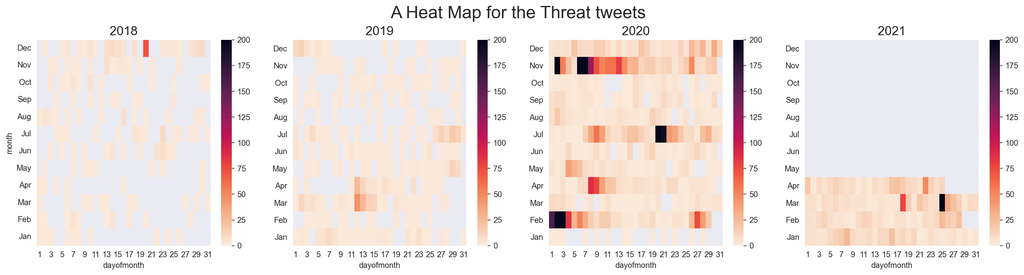

```python
threat_daily = df_threat.groupby(['year', 'dayofmonth', 'month']).size().reset_index(name='ntweets')

title = 'A Heat Map for the Threat tweets'
helpers.facet_heat(threat_daily, title, n_col=4, vmax=200)
```

### Threat tweets Peak Dates (ALL)

```python
threat_dates = df_threat.groupby(['date']).agg({'translated':'count', 'user_id': 'count'}).reset_index(
).rename(columns={'translated':'ntweets', 'user_id': 'n_users'}).sort_values('ntweets', ascending=False)

threat_dates.head(15)
```

|  | date | ntweets | n_users |
| --- | --- | --- | --- |
| 374 | 2020-02-02 | 1096 | 1096 |
| 633 | 2020-11-06 | 674 | 674 |
| 634 | 2020-11-07 | 537 | 537 |
| 629 | 2020-11-02 | 343 | 343 |
| 534 | 2020-07-20 | 305 | 305 |
| 772 | 2021-03-25 | 244 | 244 |
| 375 | 2020-02-03 | 229 | 229 |
| 535 | 2020-07-21 | 192 | 192 |
| 373 | 2020-02-01 | 160 | 160 |
| 635 | 2020-11-08 | 122 | 122 |
| 436 | 2020-04-08 | 89 | 89 |
| 376 | 2020-02-04 | 85 | 85 |
| 640 | 2020-11-13 | 82 | 82 |
| 765 | 2021-03-18 | 78 | 78 |
| 437 | 2020-04-09 | 77 | 77 |

```python
helpers.bar_peaks(threat_dates[['date', 'ntweets']].head(2),
                  'Threat tweets Peak Dates')
```

[figure not shown]

# Most Repeated Threat tweets

```python
# df = df_threat_sub[['created_at', 'days_diff', 'hours_diff', 'text', 'lang', 'translated', 'username']].head(60)
# with pd.option_context('display.max_colwidth', None):
#   display(df.reset_index(drop=True).style.set_properties(**{'text-align': 'left'}))
```

```python
df_threat_sub.translated.value_counts().head(60)
```

```
#famadd yay! amber heard could go to prison for false evidence and testimony https://t.co/tdqranawac\r                                                                                                                                                                                                      …
after the actress assured that she had been a victim of violence during her marriage, it seems that now she is the one who would go to prison. #amberheardisanabuser\nhttps://t.co/hvkuepfggj\r                                                                                                             …
amber heard could go to jail for lying about johnny depp https://t.co/qd74glc42n https://t.co/sotwj1wd06\r                                                                                                                                                                                                  …
they are:\n88 audio\n40 witnesses\nphotographs and a lot more evidence\nand yet they managed to blame the victim once again.\nwarner bros, fantastic beasts 3 and aquaman 2 piss me off, i really hope they go to hell #justiceforjohnnydepp\r                                                              …
amber heard why the hell?\r                                                                                                                                                                                                                                                                                 …
@gabrielatrezzi ed westwick is being accused by three women of rape, depp assaulted amber heard and paid compensation, both are criminals, but not in the same degree of danger\r                                                                                                                           …
i can only hope, that amber heard bitch will crash once and for all. you have ruined a magnificent person, a wonderful man and an actor with a glorious career that many can dream of.\nyou must rot in hell.\r                                                                                             …
my not very dear gentlemen of warner bros, thank you for showing that justice does not favor the innocent, you can officially go to hell. #justiceforjohnnydepp\r                                                                                                                                           …
karma exists.\ni have nothing else to say\n#justiceforjohnnydepp https://t.co/eao3c0bnin\r                                                                                                                                                                                                                  …
and now they take them out of me, what the hell is going through their heads, sons of bitches, lab rats #justiceforjohnnydepp, the most perfect actor, the most incomparable, the irreplaceable one, they take it out as if it were a garbage bag, shit, i hope all of you die, hdp\r                       …
i hope one day her karma will come to that girl, i'm too upset for johnny #amberheardisanabuser\r                                                                                                                                                                                                           …
if they took out johnny depp, they have to send amber heard to hell\r                                                                                                                                                                                                                                       …
@ninde_black there are already two of us. #justiceforjohnnydepp for me, fantastic beasts no longer exists and warner can go to hell for making johnny resign and the other continue with her role.\nthey are embarrassing and for me they will not receive my money.\r                                      …
if justice is demanded for women and is carried out here and in china\nwhy the hell for men is not the same? johnny depp\nhe doesn't deserve this. fantastic animals lose their joke despite that the stain they will leave by removing the other papers #justiceforjohnnydepp https://t.co/rfmawa00tb\r    …
jhonny depp will no longer be the magical homosexual hitler, amber heard on the other hand\n\n*checks notes*\n\nshe has been punished with being a feminist icon due to the fact that none of the people who defended her have reportedly retracted her and are *check more notes* being silly https://t.co/…
and why the hell was i still with him???? | amber heard: 15 months of violence and humiliation alongside johnny depp https://t.co/iiyg1dumd1\r                                                                                                                                                              …
karma exists and dear amber heard you will end your miserable fucking career as soon as possible. #johnnydeppisinnocent\r                                                                                                                                                                                   …
```

[output cut: 44 more lines]

```python
df_threat_sub.translated.value_counts()[60:].head(60)
```

```
amber heard and all the women who do the same... go to hell a thousand times 😡😡😡😡\r                                                                                                                                                                                                                         …
amber heard damn bitch karma will punish you for your actions and johnny will come out happy as he deserves\r                                                                                                                                                                                               …
anyway i can't believe johnny's career has gone to hell for that blonde viper\ni have a grip in my stomach, i will never accept it\n#justiceforjohnnydepp\r                                                                                                                                                 …
it seems so unfair to me what they have done to johnny after his innocence was clearly proven... good luck now to find a replacement for him, because the role was spectacular. the series is going to hell. i say it. #justiceforjohnnydepp\r                                                              …
how ugly are the groups of potter fans, saying that i hope amber heard dies because of her the deep is going to be left without a job, and what a horror to read to say: let's separate acting work from her private life ☠️☠️☠️\r                                                                          …
@realamberheard chinga tu madre witch😎 karma exists and i'll laugh like never before when it's your turn to suffer👊🏻\n\n#justiceforjohnnydepp https://t.co/fvjzsso4zh\r                                                                                                                                     …
amber is worthy of nothing but prison. just go to jail!!!\n#justiceforjohnnydepp\r                                                                                                                                                                                                                          …
i hope amber heard rots in hell\r                                                                                                                                                                                                                                                                           …
amber heard can go to hell a lot.\r                                                                                                                                                                                                                                                                         …
ptn but she eats her great dead the amber heard there! she destroyed johnny this old girl of my balls!!!\r                                                                                                                                                                                                  …
stupid amber heard, and stupid feminism of the 21st century that do nothing but cause damage!!! they harmed a human being, they harmed an artist, without knowing that he was the one attacked. that woman should be in jail!!! abuse has no gender!!!!\r                                                   …
i hate you amber heard!!! you have ruined the career of a good man!!!! but late that early you are going to pay for it, liars!!!!! life is a karma\r                                                                                                                                                        …
go to hell warners\ni really don’t care about the date, i didn’t experience such hiatuses, but bitch deppa don’t touch\n#justiceforjohnnydepp #johnnydeppismygrindewald\n#johnnydeppisinnocent https://t.co/6vfnbyhcjj\r                                                                                    …
amber heard deserves all the hate that has been thrown at her :)\r                                                                                                                                                                                                                                          …
so we knocked down the event to amber heard with aquaman???\n\nfor what she did to johnny, she deserves that and more.\r                                                                                                                                                                                    …
amber heard really isn't afraid of karma. i hope that she will pay very much for all her actions, this big witch.\n#justiceforjohhnydepp #johnnydeppisinnocent\r                                                                                                                                            …
i want to die, amber heard destroyed my bug's career\r                                                                                                                                                                                                                                                      …
```

[output cut: 44 more lines]

### All text containing "go to hell"

```python
df_all_hell = df_threat_sub[df_threat_sub.translated.str.contains('go to hell')]
print(f'{df_all_hell.shape[0]} contributions, made by {df_all_hell.username.nunique()} Users')
df_all_hell.head()
```

```
116 contributions, made by 110 Users
```

|  | user_description | username | n_followers | text | profile_banner_url | user_location | user_id | user_created_at | profile_image_url | n_friends | ... | tweet_id | user_screen_name | date | year | month | dayofmonth | diff | days_diff | translated | hours_diff |
| --- | --- | --- | --- | --- | --- | --- | --- | --- | --- | --- | --- | --- | --- | --- | --- | --- | --- | --- | --- | --- | --- |
| 6647 | Počítačový nadšenec, odborný publicista, drobn... | Jiří Macich ml. | 342 | aquaman (2018)\n\nhrají: jason momoa, amber he... | https://pbs.twimg.com/profile_banners/9239412/... | Proboštov, Czech Republic | 9239412 | 2007-10-04 07:57:19 | http://pbs.twimg.com/profile_images/1253817404... | 171 | ... | 1065034426327973888 | jirkaxxl | 2018-11-21 | 2018 | Nov | 21 | 4065 days 16:12:10 | 4065 | aquaman (2018)\n\nstarring: jason momoa, amber... | 16 |
| 15564 | ser una pringada es mi camino ninja • kazuma k... | Nox 🌼✨ | 489 | si es cierto, obviamente amber heard se puede ... | https://pbs.twimg.com/profile_banners/28400746... | NaN | 284007465 | 2011-04-18 12:57:45 | http://pbs.twimg.com/profile_images/1383902806... | 590 | ... | 1105756372837298176 | fairoblivion | 2019-03-13 | 2019 | Mar | 13 | 2885 days 20:06:12 | 2885 | if it's true, obviously amber heard can go to ... | 20 |
| 16508 | 21 yo\nÉtudiante en com' | 𝒌𝒉𝒂𝒍𝒆𝒆𝒔𝒊 | 190 | va en enfer amber heard | https://pbs.twimg.com/profile_banners/19721694... | France | 1972169412 | 2013-10-19 17:01:00 | http://pbs.twimg.com/profile_images/1234954542... | 156 | ... | 1106540716388507655 | LaurianaLuciani | 2019-03-15 | 2019 | Mar | 15 | 1972 days 19:59:39 | 1972 | go to hell amber heard\r | 19 |
| 16979 | I came to this world to love and support Johnn... | Sil belives in Johnny Depp 🏴‍☠️ | 1522 | eu só queria dizer que a pessoa que inventou o... | https://pbs.twimg.com/profile_banners/14360873... | NaN | 143608730 | 2010-05-13 23:14:07 | http://pbs.twimg.com/profile_images/1374732478... | 116 | ... | 1108696387892494337 | Silviane_F | 2019-03-21 | 2019 | Mar | 21 | 3233 days 12:32:25 | 3233 | i just wanted to say that the person who inven... | 12 |
| 18581 | +30yo | Jack ☆ ; 🏐🖤🧡 | 228 | a maldita da amber heard agora veio com essas ... | NaN | NaN | 380310055 | 2011-09-26 12:48:19 | http://pbs.twimg.com/profile_images/1347576567... | 282 | ... | 1118466897010397184 | yasashisugi_ | 2019-04-17 | 2019 | Apr | 17 | 2759 days 22:02:44 | 2759 | damn amber heard now came up with these new st... | 22 |

5 rows × 24 columns

```python
df_all_hell.translated.value_counts().head(60)
```

```
they are:\n88 audio\n40 witnesses\nphotographs and a lot more evidence\nand yet they managed to blame the victim once again.\nwarner bros, fantastic beasts 3 and aquaman 2 piss me off, i really hope they go to hell #justiceforjohnnydepp\r                                                              …
aquaman (2018)\n\nstarring: jason momoa, amber heard, nicole kidman, dolph lundgren, william dafoe ...\n\ndirector: james wan\n\nif even this set doesn't work anymore, let the whole famous dc go to hell 🧐\n\nfinal trailer: https://t.co/vdy10f6e3j\r                                                    …
#justiceforjohnnydepp\n\n88 audio\n40 witnesses\nphotographs and a lot more evidence\nand yet they managed to blame the victim once again.\nwarner bros, fantastic beasts 3 and aquaman 2 piss me off, i really hope they go to hell\n #justiceforjohnnydepp https://t.co/fqjfcuezxk\r                      …
anyone who says amber is a bad actress can go to hell today.\nshe played the role of the victim so convincingly that even the court bought it, hello\n#justiceforjohnnydepp\r                                                                                                                               …
they are:\n88 audios, 40 witnesses, photographs and a lot more evidence\nand yet they managed to blame the victim once again.\nwarner bros, fantastic beasts 3 and aquaman 2 ✨j-ó-d-a-s-e✨🖕🏻 i really hope they go to hell #justiceforjohnnydepp\r                                                          …
do you know who is going to see fantastic beasts 3? you old woman, warner bros. you can go to hell with the fucking mother who gave birth to you. #justiceforjohnnydepp\r                                                                                                                                   …
@fantasticbeasts go to hell 🤬🖕#justiceforjohnnydepp\r                                                                                                                                                                                                                                                       …
they can go to hell 🤙 #justiceforjohnnydepp\r                                                                                                                                                                                                                                                               …
i'm just saying that warner can go to hell.\n\n#justiceforjohnnydepp\r                                                                                                                                                                                                                                      …
amber heard could go to hell...\r                                                                                                                                                                                                                                                                           …
i just don't understand why the fuck they decided to take johnny out of grindelwalt and captain jack....\nkamon, guys, then no one will watch these films, do you understand that? and your rental will go to hell\nare you getting this? #justiceforjohnnydepp\r                                           …
#justiceforjohnnydepp #justiciaparajhonnydeep do what you want @warnerbros, without johnny from grindelwald say goodbye to the saga, and for aquaman with amber? it's definitely going to go to hell. https://t.co/mulzcahoxe\r                                                                             …
sad to see how big franchises continue to turn their backs on him, when it has already been proven that he is innocent.\nhe was mistreated and instead of receiving support, they destroy his career. warner and disney can go to hell, hypocrites.\n#justiceforjohnnydepp\n#johnnydeppismygrindelwald https…
fuck amber heard. hell is where you go to hell\r                                                                                                                                                                                                                                                            …
they are:\n88 audio\n40 witnesses\nphotographs and a lot more evidence\nand yet they managed to blame the victim once again.\nwarner bros, fantastic beasts 3 and aquaman 2 are blowing me away, i really hope they go to hell #justiceforjohnnydepp https://t.co/8kbwsxvl3a\r                              …
well, warner can go to hell. they seriously make deep quit and not amber? she is the abuser. she almost killed him, literally.\n#justiceforjohnnydepp\n#boycottaquaman2 https://t.co/b5sk4cuehy\r                                                                                                           …
@warnerbros screw your asshole mother!! what difference does a bastard's marital fights give? that's irrelevant to your job. go to hell ball of assholes, all of you are watery shit #justiceforjohnnydepp\r                                                                                                …
```

[output cut: 44 more lines]

```python
helpers.text_all_peaks(df_threat, 'go to hell', n=2, threshold=0)
```

[figure not shown]

```python
helpers.users_all_peaks(df_threat_sub, 'go to hell', n=10, threshold=0)
```

[figure not shown]

### All text containing "burn in hell"

```python
df_all_burn = df_threat_sub[df_threat_sub.translated.str.contains('burn in hell')]
print(f'{df_all_burn.shape[0]} contributions, made by {df_all_burn.username.nunique()} Users')
df_all_burn.head()
```

```
22 contributions, made by 21 Users
```

|  | user_description | username | n_followers | text | profile_banner_url | user_location | user_id | user_created_at | profile_image_url | n_friends | ... | tweet_id | user_screen_name | date | year | month | dayofmonth | diff | days_diff | translated | hours_diff |
| --- | --- | --- | --- | --- | --- | --- | --- | --- | --- | --- | --- | --- | --- | --- | --- | --- | --- | --- | --- | --- | --- |
| 30857 | Insta: Gleicyrodrigues63\n Potterhead 🐍 Depph... | Gleicy Rodrigues 🍩 | 42 | por mais que ouvir tudo isso dilacere meu cora... | https://pbs.twimg.com/profile_banners/19443364... | NaN | 1944336462 | 2013-10-07 15:03:50 | http://pbs.twimg.com/profile_images/1330100438... | 366 | ... | 1223761427120513025 | GleicyJohnny | 2020-02-02 | 2020 | Feb | 2 | 2308 days 09:10:05 | 2308 | as much as hearing all this breaks my heart, i... | 9 |
| 31000 | Insta: Gleicyrodrigues63\n Potterhead 🐍 Depph... | Gleicy Rodrigues 🍩 | 42 | é incrível como ainda tem gente passando pano ... | https://pbs.twimg.com/profile_banners/19443364... | NaN | 1944336462 | 2013-10-07 15:03:50 | http://pbs.twimg.com/profile_images/1330100438... | 366 | ... | 1223765370483433472 | GleicyJohnny | 2020-02-02 | 2020 | Feb | 2 | 2308 days 09:25:45 | 2308 | it's amazing how there are still people passin... | 9 |
| 34229 | . . . __ . __ __ . __ __ | pichón (Taylor’s Version) 🐦 | 675 | amber heard, ojalá ardas en el infierno | https://pbs.twimg.com/profile_banners/15322079... | NaN | 153220793 | 2010-06-08 00:27:49 | http://pbs.twimg.com/profile_images/1379135125... | 1087 | ... | 1223834517078781952 | PalomaSendra13 | 2020-02-02 | 2020 | Feb | 2 | 3526 days 04:36:32 | 3526 | amber heard, i hope you burn in hell\r | 4 |
| 35330 | You're cute, but you're not Niall Horan #PUM ... | danybb | 356 | ojalá te quemes en el infierno perra amber #ju... | https://pbs.twimg.com/profile_banners/13677142... | Delicias, Chihuahua | 136771420 | 2010-04-24 21:55:21 | http://pbs.twimg.com/profile_images/1351753641... | 967 | ... | 1223865084159647745 | danielabirdd | 2020-02-02 | 2020 | Feb | 2 | 3570 days 09:10:28 | 3570 | i hope you burn in hell bitch amber #justicefo... | 9 |
| 37246 | NaN | Neil | 25 | ебучие фемки совсем охуели, гореть вам в аду, ... | https://pbs.twimg.com/profile_banners/90251144... | Казань | 902511445 | 2012-10-24 20:00:44 | http://pbs.twimg.com/profile_images/1058693104... | 101 | ... | 1223931218670030848 | LilReezy7 | 2020-02-02 | 2020 | Feb | 2 | 2656 days 15:27:52 | 2656 | fucking fems are completely fucked up, you bur... | 15 |

5 rows × 24 columns

```python
df_all_burn.translated.value_counts().head(60)
```

```
as much as hearing all this breaks my heart, i'm relieved to know that it's now the easiest of all to see what i've always seen. #justiceforjohnnydepp\nburn in hell ah. https://t.co/fp5iahpe9d\r                                                                                                    1
it's amazing how there are still people passing cloth to amber heard. not even hearing her own admit what she did can people take the side of the victim because of gender!\n#justiceforjohnnydepp\nburn in hell a.h! https://t.co/rzz085s3q5\r                                                       1
daily reminder that a man can also be a victim of domestic violence and that amber will burn in hell for what he fucks off #justiceforjohnnydepp\r                                                                                                                                                    1
just burn in hell everyone!!! especially amber huerd\n#justiceforjohnnydepp\n#amberheardisaliar\n#amberheardistherealabuser\n#jonnydepp\r                                                                                                                                                             1
burn in hell, creatures. i am everything.\n\n#justiceforjohnnydepp\r                                                                                                                                                                                                                                  1
however, not only is amber heard a bitch who has to burn in hell but she is also a very bad actress\r                                                                                                                                                                                                 1
@vulture 🖕🖕🖕🖕🖕🖕🖕🖕🖕🖕🖕🖕🖕🖕🖕🖕🖕🖕🖕🖕🖕🖕🖕🖕🖕 suck, the creatures are fantastic. and burn in hell.\nyou asked for it\n #justiceforjohnnydepp #boycottfantasticbeasts\r                                                                                                                                           1
johnny depp: amber heard the target of a shitstorm on twitter 'i hope you burn in hell' https://t.co/t3h3qat4cy\r                                                                                                                                                                                     1
(johnny depp: amber heard targeted by a twitter shitstorm 'i hope you burn in hell') playhitmusic - https://t.co/coj5vrvhah\r                                                                                                                                                                         1
interesting news this morning. i'm not a big fan of johnny depp, but i respect this actor for his amazing acting in pirates and ft. court in london with amber heard lost? it seemed to me that this was impossible even in theory. warners, disney, judge, burn in hell.\n#justiceforjohnnydepp\r    1
#justiceforjohnnydepp\nand may amber heard burn in hell\r                                                                                                                                                                                                                                             1
oh yeah, who needs these damn movies now. #warnerbros burn in hell\n.\n#johnnydepp #justiceforjohnnydepp https://t.co/zj26iisdms\r                                                                                                                                                                    1
@shotorice i am pissed off, i hope that amber heard you burn in hell, i believe in karma, it must die\r                                                                                                                                                                                               1
amber heard is the definition of "i deserve to go burn in hell".\r                                                                                                                                                                                                                                    1
the toad face shall burn in hell. #amberturd #amberheardisanabuser\r                                                                                                                                                                                                                                  1
```

[output cut: 8 more lines]

```python
helpers.text_all_peaks(df_threat, 'burn in hell', n=2, threshold=0)
```

[figure not shown]

```python
helpers.users_all_peaks(df_threat_sub, 'burn in hell', n=10, threshold=0)
```

[figure not shown]

# Top Users Commented with Threat keywords

```python
threat_sub_users = df_threat_sub.username.value_counts().to_frame().reset_index().rename(columns={'index':'username',
                                                                                  'username':'ntweets'})
helpers.barh(threat_sub_users.head(15), 'Top Users Commented with Threat keywords', threshold=0, c=0)
```

[figure not shown]

```python
set_threat_users = set(threat_sub_users.username.head(15))
```

## Threat Users Contributions (All Contributions)

> > - Kill & Death
> > - Hell & Burn
> > - Crime & Jail
> > - All Threat
> > - **Threat Users Contributions**

```python
len(set(df_threat.username))
```

```
7069
```

```python
threat_users = list(df_threat.username)
df_threat_users = df_tweets.query(' username == @threat_users ')
df_threat_users = df_threat_users[~df_threat_users.username.isin(remove_users)]
print(f'{df_threat_users.shape[0]} contributions, made by {df_threat_users.username.nunique()} Users')
df_threat_users.head(2)
```

```
34640 contributions, made by 7068 Users
```

|  | user_description | username | n_followers | text | profile_banner_url | user_location | user_id | user_created_at | profile_image_url | n_friends | ... | tweet_id | user_screen_name | date | year | month | dayofmonth | diff | days_diff | translated | hours_diff |
| --- | --- | --- | --- | --- | --- | --- | --- | --- | --- | --- | --- | --- | --- | --- | --- | --- | --- | --- | --- | --- | --- |
| 3 | *:･༄ ˗ˋ ̤Cᴜᴇɴᴛᴀ ᴅᴇ ᴇᴅɪᴛsˊ˗ •˚.✽ ⊰ ❝━ᴛᴡɪᴛᴛᴇʀ ᴘᴀ... | New Rules Edits. | 263 | anónimo ha dicho: hola! ¿puedes hacer iconos o... | https://pbs.twimg.com/profile_banners/93005592... | Barcelona, España | 930055924668141570 | 2017-11-13 12:53:06 | http://pbs.twimg.com/profile_images/1034441354... | 159 | ... | 947849259654832128 | newrulesedits | 2018-01-01 | 2018 | Jan | 1 | 49 days 02:24:22 | 49 | anonymous said: hello! can you make icons or l... | 2 |
| 7 | “Don’t you call me a mindless philosopher, you... | peanut kenobi | 1045 | amber heard já tombando minha noite yes rio ye... | https://pbs.twimg.com/profile_banners/60111281... | NaN | 60111281 | 2009-07-25 18:02:55 | http://pbs.twimg.com/profile_images/1385289270... | 1200 | ... | 948031201964589056 | skywalkerebel | 2018-01-02 | 2018 | Jan | 2 | 3082 days 09:17:31 | 3082 | amber heard already dropping my night yes rio ... | 9 |

2 rows × 24 columns

```python
df = df_threat_users.groupby('username').agg({'translated':'count', 'user_id': 'count'}).reset_index(
).rename(columns={'translated':'ntweets', 'user_id': 'n_users'})

print(df.shape)
df.sort_values('ntweets', ascending=False).head(15)
```

```
(7068, 3)
```

|  | username | ntweets | n_users |
| --- | --- | --- | --- |
| 2489 | La Sopa.Com | 2049 | 2049 |
| 2482 | La Patilla | 363 | 363 |
| 5138 | informazione cultura | 266 | 266 |
| 4141 | Telesphore Teta | 224 | 224 |
| 1553 | FR24 NEWS | 172 | 172 |
| 10 | #IBelieveHim JohnnyDeppWorldDE | 172 | 172 |
| 1367 | El Nacional | 159 | 159 |
| 2264 | Juanito Say | 154 | 154 |
| 1732 | Gala | 152 | 152 |
| 173 | Actu monde | 148 | 148 |
| 4046 | Support Johnny Depp ♡ Stream City of Lies NOW 🇺🇸 | 138 | 138 |
| 3862 | Se Estrena | 133 | 133 |
| 1629 | Floor Janssen | 128 | 128 |
| 13 | #JusticeForJohnnyDepp | 114 | 114 |
| 6947 | 🏴‍☠️🐸𝕵𝖊𝖓𝖊 𝕾𝖚𝖎𝖘 𝕻𝖆𝖘 𝕭𝖊𝖙𝖊🐸🏴‍☠️ | 111 | 111 |

### A Heat Map for the Threat Users tweets

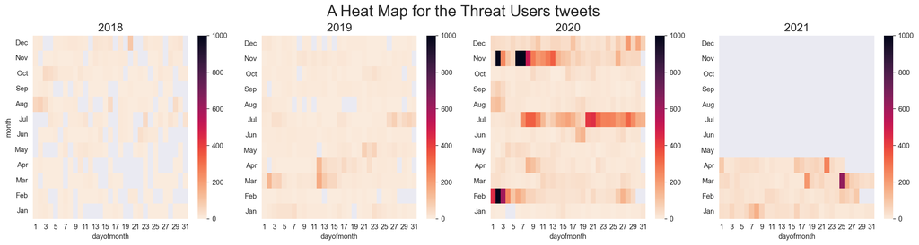

```python
threat_users_daily = df_threat_users.groupby(['year', 'dayofmonth', 'month']).size().reset_index(name='ntweets')

title = 'A Heat Map for the Threat Users tweets'
helpers.facet_heat(threat_users_daily, title, n_col=4, vmax=1000)
```

### Threat Users tweets Peak Dates

```python
threat_users_dates = df_threat_users.groupby(['date']).agg({'translated':'count', 'user_id': 'count'}).reset_index(
).rename(columns={'translated':'ntweets', 'user_id': 'n_users'}).sort_values('ntweets', ascending=False)

threat_users_dates.head(15)
```

|  | date | ntweets | n_users |
| --- | --- | --- | --- |
| 623 | 2020-02-02 | 2406 | 2406 |
| 901 | 2020-11-06 | 1793 | 1793 |
| 902 | 2020-11-07 | 1319 | 1319 |
| 897 | 2020-11-02 | 1014 | 1014 |
| 1040 | 2021-03-25 | 636 | 636 |
| 624 | 2020-02-03 | 598 | 598 |
| 903 | 2020-11-08 | 507 | 507 |
| 622 | 2020-02-01 | 442 | 442 |
| 793 | 2020-07-21 | 441 | 441 |
| 792 | 2020-07-20 | 418 | 418 |
| 781 | 2020-07-09 | 339 | 339 |
| 908 | 2020-11-13 | 339 | 339 |
| 780 | 2020-07-08 | 335 | 335 |
| 800 | 2020-07-28 | 326 | 326 |
| 794 | 2020-07-22 | 321 | 321 |

```python
helpers.bar_peaks(threat_users_dates[['date', 'ntweets']].head(2),
                  'Threat Users tweets Peak Dates')
```

[figure not shown]

# Most Repeated Threat Users tweets

```python
threat_users_sub = list(df_threat_sub.username)
df_threat_users_sub = df_tweets.query(' username == @threat_users_sub ')
df_threat_users_sub = df_threat_users_sub[~df_threat_users_sub.username.isin(remove_users)]
print(f'{df_threat_users_sub.shape[0]} contributions, made by {df_threat_users_sub.username.nunique()} Users')
df_threat_users_sub.head(1)
```

```
11809 contributions, made by 1879 Users
```

|  | user_description | username | n_followers | text | profile_banner_url | user_location | user_id | user_created_at | profile_image_url | n_friends | ... | tweet_id | user_screen_name | date | year | month | dayofmonth | diff | days_diff | translated | hours_diff |
| --- | --- | --- | --- | --- | --- | --- | --- | --- | --- | --- | --- | --- | --- | --- | --- | --- | --- | --- | --- | --- | --- |
| 76 | todos os dias lamentando em ser brasileira. \|... | en | 1810 | amber heard decretou que diana prince é bissex... | https://pbs.twimg.com/profile_banners/94365021... | @ladykillersubs she/her \|24\| | 943650210357628928 | 2017-12-21 01:11:57 | http://pbs.twimg.com/profile_images/1370175504... | 1656 | ... | 948618221934010368 | polastrixdavis | 2018-01-03 | 2018 | Jan | 3 | 13 days 17:01:06 | 13 | amber heard decreed that diana prince is bisex... | 17 |

1 rows × 24 columns

```python
df_threat_users_sub.translated.value_counts().head(60)
```

```
amber heard arrested tomorrow\r                                                                                                                                                                                                                                                                             …
"he hit me repeatedly": johnny depp recounts amber heard's reaction to being late for a party https://t.co/o1va9yqask\r                                                                                                                                                                                     …
#famadd amber heard's lawyers do not find johnny depp 'dirty laundry' https://t.co/kqz21jzj4v\r                                                                                                                                                                                                             …
new details of the relationship between johnny depp and amber heard are known and their fans create the hashtag #ibelievehim ("i believe him") https://t.co/atc9avpjvi\r                                                                                                                                    …
i'm not a robot and i totally support the truth johnny depp #johnnydeppisinnocent #amberheardisaliar #justiceforjohnnydepp #mentoo #metoo\r                                                                                                                                                                 …
sorry wrong hashtag #justiceforjohnnydepp\r                                                                                                                                                                                                                                                                 …
after the scandal with johnny depp, amber heard would be with one foot out of aquaman 2. https://t.co/iyfkrbavx9\r                                                                                                                                                                                          …
after all the criticism, amber heard disabled comments on her instagram. https://t.co/f46dwp0oio\r                                                                                                                                                                                                          …
l'oréal: remove amber heard as l'oréal spokeperson - sign the petition! https://t.co/feraxmynyx via @change\r                                                                                                                                                                                               …
#famadd winona and vanessa say that amber heard lies in accusations against johnny depp https://t.co/8pjmpo0cdx\r                                                                                                                                                                                           …
rain of criticism of amber heard in her public reappearance after leaking the audios about johnny depp https://t.co/u2gzfw3ih2\r                                                                                                                                                                            …
but sadly, i still see idiots saying things like 'oops, because of amber heard i do let myself be hit' while making fun of feminism. they disgust with his hypocrisy and his double standards.\n#justiceforjohnnydepp #warnerbrosisoverparty #boicottowarnerbros #amberheardisanabuser\r                    …
woww\n#justiceforjohnnydepp\n#johnnydepp\r                                                                                                                                                                                                                                                                  …
messages with blood, fights and drugs: details of the life of johnny depp and amber heard emerge during the actor's trial against the sun https://t.co/ccr2kcqexc\r                                                                                                                                         …
johnny depp claims his ex-wife, amber heard, did not donate the $7 million she received after their divorce to charity as promised.\nhttps://t.co/v5syhnd7qb\r                                                                                                                                              …
dc entertainment: remove amber heard from aquaman 2 - ¡firma la petición! https://t.co/oo2d0ujpus a través de @change_mex\r                                                                                                                                                                                 …
dc fans ask emilia clarke to replace amber heard in "aquaman 2"\n\nhttps://t.co/sbovj9zwbk\r                                                                                                                                                                                                                …
```

[output cut: 44 more lines]

```python
# df_threat_users_sub.translated.value_counts()[60:].head(60)
```

### Text Contains "not a victim" --> 38

```python
df_no_pos = df_tweets[~df_tweets.username.isin(remove_users)]
```

```python
df_victim = df_no_pos[df_no_pos.translated.str.contains('not a victim')]
df_victim.shape
```

```
(38, 24)
```

```python
helpers.text_all_peaks(df_no_pos, "not a victim", n=2, threshold=0)
```

[figure not shown]

```python
victim_users = df_victim.username.value_counts().to_frame().reset_index().rename(columns={'index':'username',
                                                                                  'username':'ntweets'})
helpers.barh(victim_users.head(15), '"not a victim" Top Commented Users', threshold=0, c=0)
```

[figure not shown]

# Top Users Commented with "not a victim"

```python
df_victim.username.value_counts().head(10)
```

```
ؘgrazy; tfatws ✪               5
Repubblica                     2
María Rebeca❤❤ #IBelieveHim    1
Marii~                         1
* 𝑳𝑰𝑺𝑨!                        1
Moisés M G                     1
isa lvs johnny                 1
⸦̧᩼᳑ᤢ⃘̶ꪴ᭪̸᤻᷉ᰱ᭲𝐌𝐞𝐫𝐢𝐝𝐞𝐧💜         1
iru 🐍                          1
Lietta😎🤷🏻‍♀️                   1
Name: username, dtype: int64
```

```python
helpers.contr_peaks(df_tweets, "ؘgrazy; tfatws ✪", n=3, threshold=0)
```

[figure not shown]

```python
user = "ؘgrazy; tfatws ✪"
df_tweets.query(" username == @user ").translated.value_counts().head()
```

```
@lyandra_rose @centraldepp “amber heard has confessed under oath to a series of violent attacks on depp, ms. heard is not a victim of domestic abuse; she is a perpetrator" https://t.co/bw8quzrdht\r                   1
@anajujorge @gutavoglt 🚨| new court documents that claim amber heard confessed and admitted under oath that she was violent and abusive in her relationship with johnny depp.\n#johnnydepp https://t.co/twlin5ywyj\r    1
finally the soft drinks\n#amberheardisanabuser https://t.co/4yrp2ruy1m\r                                                                                                                                                1
lol lol loved it\n#amberheardisanabuser\r                                                                                                                                                                               1
@hailsexz @evesalander @hugogloss “amber heard has confessed under oath to a series of violent attacks on depp, ms. heard is not a victim of domestic abuse; she is a perpetrator" https://t.co/7c5mkh8sxy\r            1
Name: translated, dtype: int64
```

## Hate-Speech tweets

> - Threat tweets
> - **Hate-Speech tweets**
> - Same Text Same Date
> - Primarly Text Investigations

```python
neg_text = neg_text | all_threat | hate_speech
```

```python
len(neg_text)
```

```
168
```

```python
print(f'{df_hate.shape[0]} contributions, made by {df_hate.username.nunique()} Users')
df_hate.head(2)
```

```
47370 contributions, made by 30704 Users
```

|  | user_description | username | n_followers | text | profile_banner_url | user_location | user_id | user_created_at | profile_image_url | n_friends | ... | tweet_id | user_screen_name | date | year | month | dayofmonth | diff | days_diff | translated | hours_diff |
| --- | --- | --- | --- | --- | --- | --- | --- | --- | --- | --- | --- | --- | --- | --- | --- | --- | --- | --- | --- | --- | --- |
| 3 | *:･༄ ˗ˋ ̤Cᴜᴇɴᴛᴀ ᴅᴇ ᴇᴅɪᴛsˊ˗ •˚.✽ ⊰ ❝━ᴛᴡɪᴛᴛᴇʀ ᴘᴀ... | New Rules Edits. | 263 | anónimo ha dicho: hola! ¿puedes hacer iconos o... | https://pbs.twimg.com/profile_banners/93005592... | Barcelona, España | 930055924668141570 | 2017-11-13 12:53:06 | http://pbs.twimg.com/profile_images/1034441354... | 159 | ... | 947849259654832128 | newrulesedits | 2018-01-01 | 2018 | Jan | 1 | 49 days 02:24:22 | 49 | anonymous said: hello! can you make icons or l... | 2 |
| 29 | She/Her\n🇧🇷\nPsychologist\n#SnydersAmazons | nash | 2557 | amber heard está me matando no instagram. | https://pbs.twimg.com/profile_banners/58524713... | NaN | 58524713 | 2009-07-20 16:59:37 | http://pbs.twimg.com/profile_images/1369978535... | 1651 | ... | 948151360779898880 | FuriesNah | 2018-01-02 | 2018 | Jan | 2 | 3087 days 18:18:17 | 3087 | amber heard is killing me on instagram.\r | 18 |

2 rows × 24 columns

### A Heat Map for the Hate-Speech tweets

```
Note: The Peaks on Feb, Nov 2020
```

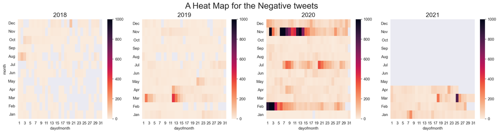

```python
hate_daily = df_hate.groupby(['year', 'dayofmonth', 'month']).size().reset_index(name='ntweets')

print('\nNote: The Peaks on Feb, Nov 2020\n')
title = 'A Heat Map for the Negative tweets'
helpers.facet_heat(hate_daily, title, n_col=4, vmax=1000)
```

### Hate-Speech tweets Peak Dates

```python
hate_dates = df_hate.groupby(['date']).agg({'translated':'count', 'user_id': 'count'}).reset_index(
).rename(columns={'translated':'ntweets', 'user_id': 'n_users'}).sort_values('ntweets', ascending=False)

hate_dates.head(15)
```

|  | date | ntweets | n_users |
| --- | --- | --- | --- |
| 603 | 2020-02-02 | 5384 | 5384 |
| 881 | 2020-11-06 | 3188 | 3188 |
| 882 | 2020-11-07 | 2606 | 2606 |
| 877 | 2020-11-02 | 1530 | 1530 |
| 604 | 2020-02-03 | 1411 | 1411 |
| 888 | 2020-11-13 | 1064 | 1064 |
| 887 | 2020-11-12 | 906 | 906 |
| 602 | 2020-02-01 | 895 | 895 |
| 1020 | 2021-03-25 | 792 | 792 |
| 883 | 2020-11-08 | 792 | 792 |
| 889 | 2020-11-14 | 667 | 667 |
| 884 | 2020-11-09 | 658 | 658 |
| 605 | 2020-02-04 | 535 | 535 |
| 886 | 2020-11-11 | 457 | 457 |
| 297 | 2019-03-12 | 425 | 425 |

```python
helpers.bar_peaks(hate_dates[['date', 'ntweets']].head(2),
                  'Hate-Speech tweets Peak Dates')
```

[figure not shown]

# Most Repeated Hate-Speech tweets

```python
df_hate.translated.value_counts().head(60)
```

```
fuck your mother amber heard\r                                                                                                                                                                                                                                                                              …
ayo fuck amber heard\r                                                                                                                                                                                                                                                                                      …
@vogue_italia help save johnny! share our petitions! #justiceforjohnnydepp https://t.co/94flecmmrt & amp; https://t.co/qpjmehtcb2\r                                                                                                                                                                         …
violence has no gender #justiceforjohnnydepp\r                                                                                                                                                                                                                                                              …
justice for johnny depp!\n\nwhat great indignation! it is inconceivable that being he innocent, having presented irrefutable evidence of his wife's aggression towards him, he would be fired from him.\n\n#johnnydeppisinnocent #justiceforjohhnydepp #amberheardisanabuser #amberheardisaliar\r           …
johnny depp on amber #heard abuse claims https://t.co/nrqbn4sx9j\r                                                                                                                                                                                                                                          …
johnny depp threatened to "burn" and "drown" amber heard in the lyrics\n\njohnny depp and amber https://t.co/ojkhrw9k7k\r                                                                                                                                                                                   …
fuck your mother amber heard.\r                                                                                                                                                                                                                                                                             …
impact of domestic violence case, warner bros. consider firing amber heard from 'aquaman 2' https://t.co/httore9itk\r                                                                                                                                                                                       …
"he threatened to kill me several times": amber heard's harsh testimony against johnny depp https://t.co/v0cyuwpj2l\r                                                                                                                                                                                       …
"he threatened to kill me several times": amber heard's harsh testimony against johnny depp https://t.co/v0cyux6uqv\r                                                                                                                                                                                       …
amber heard, 15 months of violence and humiliation next to johnny depp https://t.co/l759ldbejd\r                                                                                                                                                                                                            …
#boycottwarnerbros #justiceforjohnnydepp #amberheardisanabuser\nquote tweet\r                                                                                                                                                                                                                               …
jhonny depp and amber heard did not have a fairy tale but a hellish marriage.- #lasopa\nhttps://t.co/fivchrfoqr\r                                                                                                                                                                                           …
they collect signatures to remove amber heard from aquaman and put emilia clarke https://t.co/iwrb0i9cle\r                                                                                                                                                                                                  …
l'oréal: remove amber heard as l'oréal spokeperson - sign the petition! https://t.co/x2idddwtrt via @change #johnnydeppisinnocent \n#amberheardisaliar #amberheardisanabuser #justiceforjohnnydepp  #johnnydeppisavictim #fireamberheard #boycottloreal #recastmera #nojohnnynopirates\r                    …
amber heard claims johnny depp doesn't remember doing domestic violence due to drugs and alcohol https://t.co/gb6hgycjqr\r                                                                                                                                                                                  …
```

[output cut: 44 more lines]

## "fuck your mother amber heard"

```python
text0 = "fuck your mother amber"
df_fuc = df_hate[df_hate.translated.str.contains(text0)]
df_fuc.username.value_counts().head(10)
```

```
; 🍑             2
PIKAchu⚡        2
Feminancy       2
🦋               2
Leslie Anahi    2
𝓜𝓸𝓻𝓮            2
Konte           2
𝕷𝖆 𝖏𝖔𝖍𝖆         1
conk            1
𝐼𝑣𝑎𝑛𝑛𝑎🥀         1
Name: username, dtype: int64
```

```python
print(df_fuc.shape)
df_fuc.head(1)
```

```
(166, 24)
```

|  | user_description | username | n_followers | text | profile_banner_url | user_location | user_id | user_created_at | profile_image_url | n_friends | ... | tweet_id | user_screen_name | date | year | month | dayofmonth | diff | days_diff | translated | hours_diff |
| --- | --- | --- | --- | --- | --- | --- | --- | --- | --- | --- | --- | --- | --- | --- | --- | --- | --- | --- | --- | --- | --- |
| 32435 | 20. taylena stan acc. | wendy (taylor's version) | 1518 | chinga tu madre amber heard | https://pbs.twimg.com/profile_banners/22813651... | mty, mx | 228136511 | 2010-12-18 20:47:42 | http://pbs.twimg.com/profile_images/1378132234... | 1457 | ... | 1223795099538051073 | wenmoralesr | 2020-02-02 | 2020 | Feb | 2 | 3332 days 05:40:01 | 3332 | fuck your mother amber heard\r | 5 |

1 rows × 24 columns

```python
helpers.text_all_peaks(df_tweets, text0, n=3, threshold=0)
```

[figure not shown]

```python
df = df_fuc[['created_at', 'days_diff', 'hours_diff', 'text', 'lang', 'translated', 'username']].head(60)
with pd.option_context('display.max_colwidth', None):
  display(df.reset_index(drop=True).style.set_properties(**{'text-align': 'left'}))
```

|  | created_at | days_diff | hours_diff | text | lang | translated | username |
| --- | --- | --- | --- | --- | --- | --- | --- |
| 0 | 2020-02-02 02:27:43 | 3332 | 5 | chinga tu madre amber heard | es | fuck your mother amber heard | wendy (taylor's version) |
| 1 | 2020-02-02 03:23:51 | 2225 | 6 | #justiceforjohnnydepp chinga tu madre amber! https://t.co/ynivmgm7is | es | #justiceforjohnnydepp fuck your mother amber! https://t.co/ynivmgm7is | Deni Ortiz |
| 2 | 2020-02-02 09:39:56 | 788 | 23 | ananı sikim amber heard johnny e nasıl şiddet uygularsın aq. nasıl kıydın gül gibi adam lan nasıl #johnnydeppyalnızdeğildir #justiceforjohnnydepp | tr | fuck your mother amber heard how you inflict violence on johnny aq. how did you get hurt like a rose man how #johnnydeppy is not alone #justiceforjohnnydepp | Mario Page |
| 3 | 2020-02-02 18:21:21 | 2353 | 17 | @lucerobarona99 chinga tu madre amber heard | es | @lucerobarona99 fuck your mother amber heard | Zorka |
| 4 | 2020-07-07 04:15:32 | 2037 | 21 | ya que vaya a chingar a su madre amber heard por favor. | es | now go fuck your mother amber heard please. | Montse • 몬 세 라 트 |
| 5 | 2020-09-08 16:49:13 | 1639 | 21 | chinga tu madre amber heard | es | fuck your mother amber heard | 💌 |
| 6 | 2020-11-02 13:52:21 | 3166 | 15 | hoy más que nunca... chingas a tu madre amber heard | es | today more than ever... you fuck your mother amber heard | leche papu posting |
| 7 | 2020-11-02 17:50:09 | 1001 | 20 | chinga tu madre amber #justiceforjohnnydepp | es | fuck your mother amber #justiceforjohnnydepp | 𝕀𝕧𝕪𝕖𝕝 𝕄𝕒𝕣𝕣🛸 |
| 8 | 2020-11-03 17:22:54 | 386 | 23 | chinga tu madre amber heard | es | fuck your mother amber heard | willow |
| 9 | 2020-11-06 17:26:34 | 2296 | 1 | solo tengo algo que decir: chinga tu madre amber heard | es | i only have one thing to say: fuck your mother amber heard | ╰╮ Valeria╰╮ |
| 10 | 2020-11-06 17:30:05 | 174 | 19 | chingas a tu madre amber heard y warner 🖕🏻💔 | es | fuck your mother amber heard and warner 🖕🏻💔 | gasparinnnamorningstarr |
| 11 | 2020-11-06 17:31:40 | 2138 | 19 | chinga tu madre amber heard y todos los que la defienden | es | fuck your mother amber heard and all those who defend her | 🕷️ |
| 12 | 2020-11-06 17:32:11 | 1188 | 20 | chinga tú madre amber heard | es | fuck your mother amber heard | Gael Garox |
| 13 | 2020-11-06 17:38:58 | 236 | 0 | si vivo 100 años, 100 años chingas a tu madre amber heard | es | if i live 100 years, 100 years you fuck your mother amber heard | 🦇𝕰𝖘𝖐𝖊𝖑𝖊𝖙𝖔𝖓🦇 |
| 14 | 2020-11-06 17:46:03 | 2039 | 1 | chinga tu madre amber heard | es | fuck your mother amber heard | 𝒔𝒂𝒏𝒅𝒓𝒂 𝒅𝒆𝒍 𝒂𝒏𝒈𝒆𝒍 |
| 15 | 2020-11-06 17:50:14 | 3986 | 23 | chinga tu madre amber heard | es | fuck your mother amber heard | Natalia |
| 16 | 2020-11-06 17:51:38 | 3858 | 20 | que chingue a su madre amber heard. | es | fuck your mother amber heard. | Yo soy Tammy 😷 |
| 17 | 2020-11-06 18:01:05 | 1512 | 18 | chinga tú madre amber heard | es | fuck your mother amber heard | les🐉 |
| 18 | 2020-11-06 18:08:19 | 3827 | 15 | chinga tu madre amber heard | es | fuck your mother amber heard | Feminancy |
| 19 | 2020-11-06 18:17:53 | 43 | 17 | aghhhh,es de lo más injusto,el mago tenebroso gellert grindelwald de johnny depp será siempre único,espero y lo piensen dos veces y lo traigan de vuelta para lo que resta de la 3 y la continuación de … | es | aghhhh, it's most unfair, johnny depp's dark wizard gellert grindelwald will always be unique, i hope they think twice and bring him back for the rest of season 3 and the continuation of the saga itse… | Happy Birthday Harry❤️ |
| 20 | 2020-11-06 18:29:13 | 1593 | 20 | chinga tu madre amber heard | es | fuck your mother amber heard | Emiliano Montaño |
| 21 | 2020-11-06 18:42:57 | 748 | 2 | chinga a tu madre amber heard | es | fuck your mother amber heard | alondra |
| 22 | 2020-11-06 18:45:51 | 1308 | 18 | chinga tu madre amber heard | es | fuck your mother amber heard | 압 디엘 |
| 23 | 2020-11-06 18:53:52 | 1377 | 13 | si vivo 100 años 100 años chingas a tu madre amber heard #justiceforjohhnydepp https://t.co/aj17u3ivav | es | if i live 100 years 100 years fuck your mother amber heard #justiceforjohnnydepp https://t.co/aj17u3ivav | Eduardo Gerónimo |
| 24 | 2020-11-06 18:56:18 | 345 | 15 | si 100 años vivo, 100 años chingas a tu madre amber heard #justiceforjohhnydepp #warnerbrosisoverparty | es | if i live 100 years, 100 years you fuck your mother amber heard #justiceforjohnnydepp #warnerbrosisoverparty | Lilith Safaera📍 |
| 25 | 2020-11-06 18:58:31 | 2325 | 1 | chinga tu madre amber heard | es | fuck your mother amber heard | 𝑺𝒂𝒊𝒍𝒐𝒓 𝑺𝒂𝒕𝒖𝒓𝒏🪐✨ |
| 26 | 2020-11-06 18:59:58 | 1736 | 18 | chinga tu madre amber heard. | es | fuck your mother amber heard. | ghost🦋 ♡'s akutagawa — STONE OCEAN CONFIRMED. |
| 27 | 2020-11-06 19:00:48 | 3272 | 16 | chinga tu madre amber heard | es | fuck your mother amber heard | Jxnx |
| 28 | 2020-11-06 19:03:04 | 3237 | 18 | si vivo cien años, cien años chingas a tu madre amber heard. | es | if i live a hundred years, a hundred years fuck your mother amber heard. | D ª n n y :) |
| 29 | 2020-11-06 19:11:04 | 691 | 14 | @hiro_dashii estoy súper triste yo soy potterhead y ame muchísimo como johnny interpreto a grindelwald, esperaba mucho esta peli por la pelea entre el y dumbledore pero sin depp ya no va a ser lo mism… | es | @hiro_dashii i'm super sad i'm potterhead and i loved how johnny played grindelwald, i was really expecting this movie because of the fight between him and dumbledore but without depp it won't be the … | 🇨🇱Vale🇨🇱 |
| 30 | 2020-11-06 19:38:59 | 205 | 6 | chinga tu madre warner. chinga tu madre amber heard. | es | fuck your mother warner. fuck your mother amber heard. | Rebeca R. ♥︎ |
| 31 | 2020-11-06 19:41:27 | 1686 | 22 | si cien años vivo, cien años te mando a chingar a tu madre amber heard #justiceforjohnnydepp https://t.co/6pvgozscxn | es | if i live a hundred years, a hundred years i send you to fuck your mother amber heard #justiceforjohnnydepp https://t.co/6pvgozscxn | Alejandro Arenas |
| 32 | 2020-11-06 19:48:10 | 1777 | 21 | chinga tu madre amber heard | es | fuck your mother amber heard | ɐıpɐu |
| 33 | 2020-11-06 20:06:17 | 2321 | 15 | chinga tu madre amber heard | es | fuck your mother amber heard | Mailí |
| 34 | 2020-11-06 20:12:11 | 2778 | 20 | si bien veces respiras, cien veces chingas a tu madre amber heard | es | although sometimes you breathe, a hundred times you fuck your mother amber heard | tri ✰ !R HARRY WON |
| 35 | 2020-11-06 20:27:41 | 1457 | 12 | chinga tu madre amber heard | es | fuck your mother amber heard | capirotada stan account |
| 36 | 2020-11-06 20:28:28 | 85 | 13 | tampoco me quedaré a ver la segunda entrega de acuaman, amo dc pero no quiero ver a esa perra maldita. chinga tu madre amber heard | es | i won't stay to see the second installment of aquaman either, i love dc but i don't want to see that damn bitch. fuck your mother amber heard | PIKAchu⚡ |
| 37 | 2020-11-06 20:37:12 | 218 | 15 | chinga tu madre amber heard | es | fuck your mother amber heard | Monikita |
| 38 | 2020-11-06 20:38:09 | 4029 | 22 | chinga tu madre amber heard | es | fuck your mother amber heard | 𝙆𝙖𝙧𝙚𝙣' ▼H̷o̷u̷s̷e̷ ̷P̷a̷r̷t̷y̷▼ |
| 39 | 2020-11-06 20:59:28 | 752 | 1 | chinga tu madre amber heard | es | fuck your mother amber heard | Leslie D. |
| 40 | 2020-11-06 21:07:38 | 274 | 3 | chinga tu madre amber heard. | es | fuck your mother amber heard. | 𝙰𝙵 |
| 41 | 2020-11-06 21:08:59 | 3590 | 4 | chinga tu madre amber heard. | es | fuck your mother amber heard. | ❥ |
| 42 | 2020-11-06 21:10:00 | 279 | 20 | chingas a tu madre amber heard, arruinaste fantastic beasts, sin johnny depp no sera lo mismo 😭 | es | fuck your mother amber heard, you ruined fantastic beasts, without johnny depp it won't be the same 😭 | ARIS |
| 43 | 2020-11-06 21:15:34 | 436 | 23 | y chinga tu madre amber heard #justiceforjohnnydepp #johnnydepp | es | and fuck your mother amber heard #justiceforjohnnydepp #johnnydepp | Hermaiony |
| 44 | 2020-11-06 21:29:09 | 948 | 5 | chinga tu madre amber #justiceforjohnnydepp | es | fuck your mother amber #justiceforjohnnydepp | tamal |
| 45 | 2020-11-06 21:41:46 | 3441 | 19 | si vivo 100 años, 100 años chingas a tu madre amber heard | es | if i live 100 years, 100 years you fuck your mother amber heard | Coral Castañeda |
| 46 | 2020-11-06 21:42:47 | 2872 | 22 | chinga tu madre amber heard! | es | fuck your mother amber heard! | ZhuLiDoesTheThing ☭ Simp de Joseju |
| 47 | 2020-11-06 21:54:18 | 1753 | 16 | amber heard es la karla panini de hollywood. chinga tu madre amber heard. | tl | amber heard is the karla panini of hollywood. fuck your mother amber heard. | R\|A |
| 48 | 2020-11-06 22:14:39 | 3785 | 21 | chinga tu madre amber heard | es | fuck your mother amber heard | obscurial ☾ |
| 49 | 2020-11-06 22:15:05 | 2746 | 0 | chinga tu madre amber heard! | es | fuck your mother amber heard! | Nathaliee 🦋 |
| 50 | 2020-11-06 22:19:29 | 3297 | 22 | chinga tu madre amber heard | es | fuck your mother amber heard | C De Los Santos |
| 51 | 2020-11-06 22:22:46 | 3026 | 5 | chinga tu madre amber heard. | es | fuck your mother amber heard. | Asakura |
| 52 | 2020-11-06 22:41:05 | 3861 | 18 | que chingue a su madre amber heard | es | fuck your mother amber heard | The Selfish Giant |
| 53 | 2020-11-06 22:41:25 | 312 | 15 | #justiceforjohnnydepp #johnnydepp maldita perra chinga a tu madre amber | es | #justiceforjohnnydepp #johnnydepp damn bitch fuck your mother amber | Emily Galicia |
| 54 | 2020-11-06 22:42:20 | 769 | 18 | chinga a tu madre amber heard yo te amaba 😭😭😭😭😭🖕🏻 | es | fuck your mother amber heard i loved you 😭😭😭😭😭🖕🏻 | Emi |
| 55 | 2020-11-06 22:55:04 | 3361 | 1 | chinga tu madre amber heard | es | fuck your mother amber heard | Rocket(Wo)man |
| 56 | 2020-11-06 23:09:10 | 344 | 21 | aquí claramente podemos ver al ser más despreciable del mundo y a un lado,a una tal dolores umbridge. chingas a tu madre ambervheard x1485969 #fantasticbeasts #justiceforjohnnydepp https://t.co/dyqavj… | es | here we can clearly see the most despicable being in the world and to one side, a certain dolores umbridge. fuck your mother ambervheard x1485969 #fantasticbeasts #justiceforjohnnydepp https://t.co/dy… | Leslie Anahi |
| 57 | 2020-11-06 23:15:00 | 2988 | 0 | y si vivo 100 años, 100 años vas y chingas a tu madre amber heard. #amberheardisoverparty #johnnydeppisinnocent https://t.co/wsdjfwnamm | es | and if i live 100 years, 100 years you go and fuck your mother amber heard. #amberheardisoverparty #johnnydeppisinnocent https://t.co/wsdjfwnamm | meli✨ |
| 58 | 2020-11-06 23:16:12 | 344 | 21 | cuando creía que el 2020 no podía ser peor @warnerbros hace que mi poderosísimo johnny depp,renuncie a su papel cómo gellert grindelwald en @fantasticbeasts solo quiero decir... chingas a tu madre amb… | es | when i thought 2020 couldn't get any worse @warnerbros makes my mighty johnny depp give up his role as gellert grindelwald in @fantasticbeasts i just want to say... fuck your mother amber, fuck your m… | Leslie Anahi |
| 59 | 2020-11-06 23:21:02 | 1247 | 21 | hoy no hay video, youtube no lo ha puesto en verde y eso que está subido desde hace casi tres días. todo es culpa de amber heard, chinga tu madre amber heard. https://t.co/6wmn1gnrgw | es | today there is no video, youtube has not put it in green and that has been uploaded for almost three days. it's all amber heard's fault, fuck your mother amber heard. https://t.co/6wmn1gnrgw | Desc Loq Don Strikes 👺 |

```python
df = df_fuc[['created_at', 'days_diff', 'hours_diff', 'text', 'lang', 'translated', 'username']][60:].head(60)
with pd.option_context('display.max_colwidth', None):
  display(df.reset_index(drop=True).style.set_properties(**{'text-align': 'left'}))
```

|  | created_at | days_diff | hours_diff | text | lang | translated | username |
| --- | --- | --- | --- | --- | --- | --- | --- |
| 0 | 2020-11-06 23:22:33 | 1291 | 18 | chinga tu madre amber heard. 🙌🏻 | es | fuck your mother amber heard. 🙌🏻 | Ꭱ Ꮻ Ꮪ Ꮪ Ꭼ |
| 1 | 2020-11-06 23:48:40 | 103 | 9 | chinga tu madre amber heard 😿 | es | fuck your mother amber heard 😿 | Monserrat Trujillo |
| 2 | 2020-11-06 23:56:28 | 1181 | 0 | chinga tu madre amber heard | es | fuck your mother amber heard | 💀ホルヘ💀 |
| 3 | 2020-11-07 00:01:09 | 1054 | 16 | si vivo 100 años, 100 años chingas a tu madre amber heard. #justiceforjohhnydepp | es | if i live 100 years, 100 years you fuck your mother amber heard. #justiceforjohnnydepp | Lennis |
| 4 | 2020-11-07 00:06:10 | 3282 | 6 | chinga tu madre amber heard | es | fuck your mother amber heard | 𝒜𝓁𝑜 |
| 5 | 2020-11-07 00:50:28 | 3733 | 8 | chinga tu madre amber heard | es | fuck your mother amber heard | e. |
| 6 | 2020-11-07 01:09:36 | 1 | 20 | si vivo 100 años, 100 años chingas a tu madre amber heard | es | if i live 100 years, 100 years you fuck your mother amber heard | Ariadne |
| 7 | 2020-11-07 01:11:52 | 1176 | 22 | chinga tu madre amber heard | es | fuck your mother amber heard | La Kenini |
| 8 | 2020-11-07 01:13:04 | 3225 | 22 | chinga tu madre amber heard | es | fuck your mother amber heard | Carlos Daniel de Grey ✨ |
| 9 | 2020-11-07 01:32:39 | 2759 | 6 | chinga tu madre amber heard | es | fuck your mother amber heard | Xime ◡̈ |
| 10 | 2020-11-07 01:50:53 | 3015 | 21 | chinga tu madre amber heard | es | fuck your mother amber heard | libélula 🧚🏼 |
| 11 | 2020-11-07 02:11:49 | 3130 | 22 | #justiceforjohnnydepp no se a quien odio más si a la karla panini o a amber. pinche vieja como la odio, si vivo 100 años, 100 años chingas a tu madre amber heard 😡😡😡 https://t.co/gmot0yhqci | es | #justiceforjohnnydepp i don't know who i hate more, karla panini or amber. fuck old how i hate her, if i live 100 years, 100 years fuck your mother amber heard 😡😡😡 https://t.co/gmot0yhqci | ᴀʟᴇᴊᴀɴᴅʀᴀ✨ |
| 12 | 2020-11-07 02:36:15 | 3458 | 6 | @devalzre chinga a tu madre amber heard | es | @devalzre fuck your mother amber heard | Jen💖 #1BillionforBillieJean #ThankyouIsayama |
| 13 | 2020-11-07 04:15:44 | 1818 | 2 | si vivo 100 años, 100 años chingas a tu madre amber heard #amberheardisaliar #amberheard https://t.co/ubvapick7z | es | if i live 100 years, 100 years you fuck your mother amber heard #amberheardisaliar #amberheard https://t.co/ubvapick7z | Marcela 🇲🇽 |
| 14 | 2020-11-07 04:26:43 | 691 | 9 | chinga tu madre amber heard | es | fuck your mother amber heard | Diego Gabriel |
| 15 | 2020-11-07 04:45:17 | 89 | 3 | chinga tu madre amber heard | es | fuck your mother amber heard | winters child |
| 16 | 2020-11-07 05:09:16 | 407 | 12 | joder, es increíble como pueden destruir los éxitos de una persona solo porque si... espero haya justicia!!! chingas a tu madre amber heard #justiceforjohnnydepp | es | damn, it's amazing how they can destroy a person's successes just because... i hope there is justice!!! fuck your mother amber heard #justiceforjohnnydepp | Ｒ🍬ｓａｌí |
| 17 | 2020-11-07 05:10:35 | 249 | 22 | chinga tu madre amber heard | es | fuck your mother amber heard | Diana |
| 18 | 2020-11-07 05:12:53 | 371 | 22 | si vivo 100 años, 100 años chingas tu madre amber heard | es | if i live 100 years, 100 years fuck your mother amber heard | Alejandra Taméz |
| 19 | 2020-11-07 05:13:06 | 2454 | 5 | amber heard ya superó a carla panini y a sarita juntas así que sí, ¡¡chingas a tu madre amber!! | es | amber heard already surpassed carla panini and sarita together so yes, fuck your mother amber!! | Renn |
| 20 | 2020-11-07 07:11:55 | 505 | 2 | y si tengo 10 vidas, en las 10 chingas a tu madre amber heard | es | and if i have 10 lives, in the 10 you fuck your mother amber heard | loveproof |
| 21 | 2020-11-07 07:42:09 | 86 | 1 | @andresmoreno967 por lo que he visto el feminismo no busca en hacer daño, perjudicar, aprovecharse o exterminar a los hombres, sino es buscar justicia, equidad, valores, etc., y pues la que no lo hace… | es | @andresmoreno967 from what i have seen, feminism does not seek to harm, harm, take advantage of or exterminate men, but rather it seeks justice, equity, values, etc. and well, the one who does not do … | PIKAchu⚡ |
| 22 | 2020-11-07 13:14:52 | 32 | 13 | chinga tu madre amber heard | es | fuck your mother amber heard | winwinko COMISSIONS OPEN! |
| 23 | 2020-11-07 13:27:43 | 384 | 21 | buenos días, chinga tu madre amber heard | es | good morning, fuck your mother amber heard | selene |
| 24 | 2020-11-07 14:57:18 | 446 | 10 | no puede ser que despidieron a johnny deep por machista cuando el mostró pruebas de que el era el maltratado y que por culpa del yo si te creo amiga, uno de mis ídolos fue despedido de warner bros aho… | es | it can't be that johnny depp was fired for being sexist when he showed evidence that he was the mistreated one and that because of me, if i believe you friend, one of my idols was fired from warner br… | Juan Two three💙💙💙 |
| 25 | 2020-11-07 15:08:11 | 641 | 17 | si 100 años vivo 100 años vas y chingas a tu madre amber heard | es | if i live 100 years 100 years you go and fuck your mother amber heard | vr |
| 26 | 2020-11-07 15:58:05 | 173 | 7 | hoy también chingas a tu madre amber heard | es | today you also fuck your mother amber heard | grets |
| 27 | 2020-11-07 16:15:07 | 2757 | 11 | si vivo 100 años, 101 chingas a tu madre amber heard. | es | if i live 100 years, 101 fuck your mother amber heard. | DANICU. |
| 28 | 2020-11-07 17:00:30 | 452 | 18 | chinga tu madre amber heard | es | fuck your mother amber heard | eneceache |
| 29 | 2020-11-07 17:25:49 | 94 | 20 | @elgranqenk chingas a tu madre amber heard https://t.co/8e7tid8lyv | es | @elgranqenk fuck your mother amber heard https://t.co/8e7tid8lyv | Angel120803 |
| 30 | 2020-11-07 18:36:39 | 2459 | 11 | chinga tu madre amber heard | es | fuck your mother amber heard | Suzz M. |
| 31 | 2020-11-07 19:09:22 | 840 | 22 | si 100 años vivo, 100 años chingas a tu madre amber heard x10372819821 | es | if i live 100 years, 100 years you fuck your mother amber heard x10372819821 | Sio |
| 32 | 2020-11-07 20:20:04 | 3290 | 15 | si vivo 100 años, 100 años chingas a tu madre amber heard. | es | if i live 100 years, 100 years you fuck your mother amber heard. | Mr. Brightside |
| 33 | 2020-11-07 21:36:59 | 1963 | 22 | si 100 años vivo 100 años chingas a tu madre amber heard | es | if i live 100 years 100 years fuck your mother amber heard | andre como el de victorious |
| 34 | 2020-11-08 03:31:02 | 1467 | 22 | espero que mi internet me lo permita. (chinga tu madre amber heard) ¡juguemos a las monas chinas! [esp/eng] https://t.co/gph3ncbndx | es | i hope my internet allows me. (fuck your mother amber heard) let's play chinese monkeys! [esp/eng] https://t.co/gph3ncbndx | Ashy Slashy #BrodieLeeForever |
| 35 | 2020-11-08 17:52:37 | 1087 | 14 | chinga a tu madre amber heard | es | fuck your mother amber heard | 𝕿𝖎𝖇𝖚𝖗𝖔𝖓𝖈í𝖓 |
| 36 | 2020-11-08 18:46:18 | 3116 | 17 | chinga tu madre amber heard | es | fuck your mother amber heard | Divina Mburukuja |
| 37 | 2020-11-08 22:43:20 | 1351 | 3 | pinche frío culerooo, chinga tu madre amber heard | es | fucking cold culerooo, fuck your mother amber heard | anna-byHS |
| 38 | 2020-11-08 22:55:35 | 3165 | 19 | vete alv warner brothers, no van a encontrar un mejor grindelwald que johnny depp, la segunda película de fantastic beasts solo fue buena por su aparición, la tercera será un asco sin el; mark my word… | es | go to warner brothers, they are not going to find a better grindelwald than johnny depp, the second fantastic beasts movie was only good for his appearance, the third will suck without him; mark my wo… | 🦋 |
| 39 | 2020-11-09 02:05:55 | 379 | 16 | chinga tu madre amber heard | es | fuck your mother amber heard | ᴍᴇᴍᴇʀʟᴀ |
| 40 | 2020-11-09 04:26:39 | 1983 | 6 | si 100 años vivo 100 años chinga tu madre amber heard | es | if i live 100 years 100 years fuck your mother amber heard | heartbroken |
| 41 | 2020-11-09 05:29:23 | 0 | 0 | #minombredepirata chinga tu madre amber heard | es | #mypiratename fuck your mother amber heard | T-bone |
| 42 | 2020-11-09 06:20:59 | 1277 | 4 | si vivo 100 años , 100 años chingas a tu madre amber heard. | es | if i live 100 years, 100 years you fuck your mother amber heard. | 𝐷𝑎𝑟𝑖𝑛𝑘𝑎𝑎 |
| 43 | 2020-11-09 07:53:01 | 193 | 23 | si vivo 100 años, 100 años chingas a tu madre amber heard | es | if i live 100 years, 100 years you fuck your mother amber heard | Elsa Liliana |
| 44 | 2020-11-10 00:11:50 | 986 | 21 | si vivo 100 años, 100 años chingas a tu madre amber heard. | es | if i live 100 years, 100 years you fuck your mother amber heard. | Isabel |
| 45 | 2020-11-13 03:11:48 | 2396 | 4 | chinga tu madre amber heard | es | fuck your mother amber heard | 𝐟𝐚𝐭𝐢𝗺𝐚𝐚𝐚🍒 |
| 46 | 2020-11-13 03:21:19 | 2064 | 8 | chinga tu madre amber heard | es | fuck your mother amber heard | Vanargand 🐾 |
| 47 | 2020-11-13 12:19:13 | 3708 | 21 | chinga tu madre amber heard. | es | fuck your mother amber heard. | Frank Miguel🇻🇪 |
| 48 | 2020-11-14 07:35:18 | 699 | 9 | estoy como pendeja apurandome con una tarea pensando que se entregaba a las 11:59pm y se entregaba a las 11pm, lptm, chinga tu madre amber heard u.u | es | i'm like pendeja rushing with a task thinking that it was due at 11:59pm and it was due at 11pm, lptm, fuck your mother amber heard u.u | MontseRain 🖤 |
| 49 | 2020-11-14 16:05:07 | 109 | 16 | chinga tu madre amber heard y si vivo cien años cien años chingas a tu madre | es | fuck your mother amber heard and if i live a hundred years a hundred years fuck your mother | Leonardo Brando |
| 50 | 2020-11-14 17:47:41 | 26 | 1 | si vivo 100 años, 100 años chingas a tu madre amber heard | es | if i live 100 years, 100 years you fuck your mother amber heard | LaCecyyy |
| 51 | 2020-11-15 20:18:20 | 3178 | 1 | que me perdone mi dios jason momoa pero yo no pienso ver ninguna de las películas de aquaman a pesar de que quería verlo 😾👊🏻 chinga tu madre amber heard | es | god forgive me jason momoa but i'm not going to watch any of the aquaman movies even though i wanted to see it 😾👊🏻 fuck your mother amber heard | Angie 안지 ✨ 🇨🇴😊 |
| 52 | 2020-11-15 22:19:17 | 335 | 5 | chinga tu madre amber heard | es | fuck your mother amber heard | 𝐼𝑣𝑎𝑛𝑛𝑎🥀 |
| 53 | 2020-11-15 23:01:00 | 671 | 20 | chinga tu madre amber heard | es | fuck your mother amber heard | 🦋 |
| 54 | 2020-11-16 09:12:40 | 628 | 5 | chinga tu madre amber heard | es | fuck your mother amber heard | conk |
| 55 | 2020-11-17 21:00:21 | 1752 | 3 | chinga tu madre amber heard❤️ | es | fuck your mother amber heard ❤️ | 𝕷𝖆 𝖏𝖔𝖍𝖆 |
| 56 | 2020-11-18 01:29:58 | 1464 | 1 | chinga tu madre amber heard. | es | fuck your mother amber heard. | BigMarZ |
| 57 | 2020-11-18 20:14:59 | 3429 | 1 | chinga tu madre amber heard! a mí nadie me paga para pensar que eres una cretina abusadora y descarada, hace como quieras! | es | fuck your mother amber heard! nobody pays me to think that you are an abusive and shameless cretin, do as you want! | Lore Pontón |
| 58 | 2020-11-19 04:06:49 | 4695 | 12 | chinga tu madre amber heard | es | fuck your mother amber heard | Tinosoft@デレステ/GBF/プリコネR |
| 59 | 2020-11-20 08:35:23 | 4044 | 12 | chinga tu madre amber heard!!! | es | fuck your mother amber heard!!! | Teniente Dan |

```python
df_hate.translated.value_counts()[60:].head(60)
```

```
new petition to remove amber heard from “aquaman 2” exceeds 400,000 signatures https://t.co/m0igydkwnn\r                                                                                                                                                            4
@realamberheard # amberheardisanabuser # amberhearisanabuser # amberhearisanabuser # amberhearisanabuser # amberhearisanabuser # amberhearisanabuser # amberhearkisanabuser # amberhearkisanabuser # amberhearisanabuser\r                                          4
#hollywood | johnny depp seeks to "clean his reputation" after accusations of domestic violence by amber heard .- https://t.co/pplyww9eud! _\r                                                                                                                      3
aquaman 2: johnny depp fired from fantastic beasts, a petition for the departure of amber heard reaches records https://t.co/x6cmdcbscn\r                                                                                                                           3
johnny depp fans have collected a million signatures to fire amber heard from aquaman 2 #enentertainment https://t.co/ljaibwwydf https://t.co/f4wkocqbr3\r                                                                                                          3
johnny depp tells his version of the abuse allegations of his ex, amber heard https://t.co/0fmxeswafa\r                                                                                                                                                             3
johnny depp supposedly violent it boycotted him strongly when in the end he had nothing but amber heard quietly pursues his career and it makes me angry\r                                                                                                          3
johnny depp is\n\n(x) innocent\n(x) victim\n(x) the person who deserves justice\n\n#justiceforjohnnydepp\r                                                                                                                                                          3
violence has no gender.\n#justiceforjohnnydepp\r                                                                                                                                                                                                                    3
your mother's shell amber heard\r                                                                                                                                                                                                                                   3
#hollywood | finally! lawsuit johnny depp vs. amber heard will have resolution in november .- https://t.co/qmwmxnp6pb *-\r                                                                                                                                          3
#hollywood | finally! lawsuit johnny depp vs. amber heard will have a resolution in november.- https://t.co/qmwmxnp6pb %#\r                                                                                                                                         3
@realamberheard @usnatarchives liar #justiceforjohnnydepp\r                                                                                                                                                                                                         3
hollywood : i am starting a petition. to get amber heard blacklisted from hollywood! - ¡firma la petición! https://t.co/tntzzij0lu vía @change_es\r                                                                                                                 3
jhonny depp and amber heard did not have a fairy tale but a hellish marriage.- #lasopa\nhttps://t.co/fivchrxpip\r                                                                                                                                                   3
after complaints of violence, johnny depp assured that he was mistreated by his ex amber heard https://t.co/ckptuq7gp6 *\r                                                                                                                                          3
amber heard assures that johnny depp threatened to kill her many times #enentertainment https://t.co/dxzrvmxtem https://t.co/lwmmnx0nbp\r                                                                                                                           3
```

[output cut: 44 more lines]

# Top Users Commented with Hate-Speech keywords

```python
hate_users = df_hate.username.value_counts().to_frame().reset_index().rename(columns={'index':'username',
                                                                                  'username':'ntweets'})
helpers.barh(hate_users.head(15), 'Top Users Commented with Hate-Speech keywords', threshold=0, c=0)
```

[figure not shown]

```python
helpers.contr_peaks(df_tweets, "La Sopa.Com", n=14, threshold=0)
```

[figure not shown]

```python
df_hate.query(" username == 'La Sopa.Com' ").translated.value_counts().head()
```

```
jhonny depp and amber heard did not have a fairy tale but a hellish marriage.- #lasopa\nhttps://t.co/fivchrfoqr\r                               7
johnny depp said that he was the victim of violence by amber heard.- #lasopa https://t.co/zqwglt0nae\r                                          6
johnny depp said that he was the victim of violence by amber heard.- #lasopa https://t.co/zqwgltio2c\r                                          6
#hollywood | johnny depp seeks to "clean his reputation" after accusations of domestic violence by amber heard.- https://t.co/pplyww9eud.-\r    4
#hollywood | finally! lawsuit johnny depp vs. amber heard will have resolution in november .- https://t.co/qmwmxnp6pb !!\r                      4
Name: translated, dtype: int64
```

```python
helpers.contr_peaks(df_tweets, "#IBelieveHim JohnnyDeppWorldDE", n=2, threshold=0)
```

[figure not shown]

```python
df_hate.query(" username == '#IBelieveHim JohnnyDeppWorldDE' ").translated.value_counts().head()
```

```
again in german. #johnnydepp\n#johnnydeppisinnocent\n#amberheardisanabuser https://t.co/mtywjnukv9\r                                                                                                                                                                                                  1
&gt; to deceive. we like people who mirror us, that speaks to our subconscious, it tells us 'he's like me', we feel comfortable and attracted.\n#justiceforjohnnydepp\n#johnnydepp #amberheard\n#ibelievehim #johnnydeppisinnocent\n#johnnydeppisasurvivor\n#amberheardisaliar\n&gt;\r                1
great that the right picture was selected for this quote 👏🏻👏🏻👏🏻\n\n#justiceforjohnnydepp\n#johnnydepp #amberheard\n#ibelievehim #johnnydeppisinnocent\n#johnnydeppisasurvivor\n#amberheardisaliar #amberheardisanabuser\n#wearewithyoujohnnydepp\n#johnnydepphasevidence https://t.co/e0w6lftjtj\r    1
#johnnydepp vs. #amberheard : audio reveals the bitter truth\nhttps://t.co/q71m29i0kj @okmagazine\n\n#justiceforjohnnydepp\n#johnnydeppisasurvivor\n#ibelievehim #johnnydeppisinnocent\n#amberheardisaliar #amberheardisanabuser\n#wearewithyoujohnnydepp\n#johnnydepphasevidence\r                   1
aquaman 2: warner bros considering 'reducing' #amberheard 's screentime amid #johnnydepp controversy? https://t.co/wwd3ekgaf2\n\ndas wäre einfach super!!! 👏🏻\n#justiceforjohnnydepp\n#ibelievehim #johnnydeppisinnocent\n#johnnydeppisasurvivor \n#amberheardisaliar #amberheardisanabuser\r         1
Name: translated, dtype: int64
```

## Same Text Same Date

> - Threat tweets
> - Hate-Speech tweets
> - **Same Text Same Date**
> - Primarly Text Investigations

```python
df_threat.head(1)
```

|  | user_description | username | n_followers | text | profile_banner_url | user_location | user_id | user_created_at | profile_image_url | n_friends | ... | tweet_id | user_screen_name | date | year | month | dayofmonth | diff | days_diff | translated | hours_diff |
| --- | --- | --- | --- | --- | --- | --- | --- | --- | --- | --- | --- | --- | --- | --- | --- | --- | --- | --- | --- | --- | --- |
| 3 | *:･༄ ˗ˋ ̤Cᴜᴇɴᴛᴀ ᴅᴇ ᴇᴅɪᴛsˊ˗ •˚.✽ ⊰ ❝━ᴛᴡɪᴛᴛᴇʀ ᴘᴀ... | New Rules Edits. | 263 | anónimo ha dicho: hola! ¿puedes hacer iconos o... | https://pbs.twimg.com/profile_banners/93005592... | Barcelona, España | 930055924668141570 | 2017-11-13 12:53:06 | http://pbs.twimg.com/profile_images/1034441354... | 159 | ... | 947849259654832128 | newrulesedits | 2018-01-01 | 2018 | Jan | 1 | 49 days 02:24:22 | 49 | anonymous said: hello! can you make icons or l... | 2 |

1 rows × 24 columns

```python
# print('\nThe Amplifications in the counts and number of likes on #justiceforjohnnydepp is quite obvious!!')
df_same = df_threat.groupby(["translated", "date"]).agg({'tweet_id':'count'}).reset_index()
df_same.rename(columns={'tweet_id': 'ntweets'}, inplace=True)
df_same["date"] = pd.to_datetime(df_same["date"])
# to remove the 00:00:00
df_same["date"] = df_same.date.dt.date

df = df_same.sort_values(["ntweets", 'date'], ascending=[False, True]).head(60)
with pd.option_context('display.max_colwidth', None):
  display(df.reset_index(drop=True).style.set_properties(**{'text-align': 'left'}))
```

|  | translated | date | ntweets |
| --- | --- | --- | --- |
| 0 | jhonny depp and amber heard did not have a fairy tale but a hellish marriage.- #lasopa https://t.co/fivchrfoqr | 2020-02-06 | 5 |
| 1 | "he threatened to kill me several times": amber heard's harsh testimony against johnny depp https://t.co/v0cyuwpj2l | 2020-07-20 | 5 |
| 2 | "he threatened to kill me several times": amber heard's harsh testimony against johnny depp https://t.co/v0cyux6uqv | 2020-07-21 | 5 |
| 3 | @warnerbroscine #justiceforjohnnydepp he doesn't deserve to be revictimized #amberheardisanabuser @warnerbroscine you are contributing to an "public" that doesn't consume you. we are not going to see … | 2020-11-13 | 5 |
| 4 | he cut off johnny's finger, burned his cheek with a cigarette, took away his meds, hit him with a door, hit him, kicked him, spit on him, threw things at his head, made fun of him, insulted him, made … | 2020-02-02 | 4 |
| 5 | "he threatened to kill me several times": amber heard's harsh testimony against johnny depp https://t.co/v0cyux6uqv | 2020-07-20 | 4 |
| 6 | "he threatened to kill me several times": amber heard's harsh testimony against johnny depp https://t.co/v0cyuwpj2l | 2020-07-21 | 4 |
| 7 | amber heard really acted like a disgusting person, there are men and women who go through this stuff on a daily basis and she clearly didn't care. this is why johnny depp deserves to win his case agai… | 2020-07-28 | 4 |
| 8 | "let's drown her before we burn her!": the dark messages between johnny depp and amber heard https://t.co/ba1svaluti | 2020-02-28 | 3 |
| 9 | amber heard assures that johnny depp threatened to kill her many times #enentertainment https://t.co/dxzrvmxtem https://t.co/lwmmnx0nbp | 2020-07-20 | 3 |
| 10 | your mother's shell amber heard | 2020-11-06 | 3 |
| 11 | johnny depp is (x) innocent (x) victim (x) the person who deserves justice #justiceforjohnnydepp | 2020-12-30 | 3 |
| 12 | @comiccon_paris hello, is it possible that you will invite amber heard (aquaman)? 🤞🏽 | 2018-07-18 | 2 |
| 13 | girlfriend wanted for @dramakingc. •you must love him even on a full moon. also her children (they come in combo ok) •you don't need to cook him: he's dead. •(optional)you can use fc to: -amber heard … | 2018-10-07 | 2 |
| 14 | amber heard cut off johnny depp's finger, burned his cheek with a cigarette, took away his meds, hit him with a door, hit him, kicked him, spit on him, threw things at his head, made fun of him, insul… | 2020-02-02 | 2 |
| 15 | "let's drown her before we burn her!": the dark messages between johnny depp and amber heard https://t.co/ba1svaluti . | 2020-02-28 | 2 |
| 16 | "let's drown her before we burn her!": the dark messages between johnny depp and amber heard https://t.co/ba1svaujui | 2020-02-28 | 2 |
| 17 | short message conversation leaks, johnny depp wants to burn and sink amber heard https://t.co/e5yy9anqad | 2020-02-28 | 2 |
| 18 | short message conversation leaks, johnny depp wants to burn and sink amber heard https://t.co/e5yy9anqad | 2020-02-29 | 2 |
| 19 | "let's drown her before we burn her!": the dark messages between johnny depp and amber heard https://t.co/ba1svaluti | 2020-03-01 | 2 |
| 20 | "let's drown her before we burn her!": the dark messages between johnny depp and amber heard https://t.co/ba1svaujui | 2020-03-01 | 2 |
| 21 | @ novanews242 # novananews24 gossipy politics #sorge #congiuntifuoriregione #forzachristian forza capitano trend in italy #ilparadisodellesignore with beatrice, agnese # oggièunaltrogiorno #addiogigi … | 2020-11-02 | 2 |
| 22 | @lorealparisde diese marke unterstützt häusliche gewalt gegen männer #justiceforjohnnydepp #fireamberheard "tell the world johnny, tell them `i, johnny depp, a man, i'm a victim too of domestic violen… | 2020-11-07 | 2 |
| 23 | they are: 88 audio 40 witnesses photographs and a lot more evidence and yet they managed to blame the victim once again. warner bros, fantastic beasts 3 and aquaman 2 piss me off, i really hope they g… | 2020-11-07 | 2 |
| 24 | @dunemovie @warnerbroscine #justiceforjohnnydepp he doesn't deserve to be revictimized #amberheardisanabuser @warnerbroscine you are contributing to an "public" that doesn't consume you. we are not go… | 2020-11-13 | 2 |
| 25 | ti rendi conto!?!??! @valentinasigyn . #johnnydeppisinnocent #johnnydepp #amberheardisahusbandbeater #johnnydeppdeservesjustice #justiceforjohnnydepp #aquaman2 #aquaman #warnerbros #boycottaquaman2 #w… | 2020-11-29 | 2 |
| 26 | anonymous said: hello! can you make icons or layouts of amber heard in the playboy club? no ears... https://t.co/9gbftz1x60 | 2018-01-01 | 1 |
| 27 | amber heard is killing me on instagram. | 2018-01-02 | 1 |
| 28 | amber heard and elon musk are together again!: amber heard-elon musk couple, new… https://t.co/0kpsjbucxs feedburner | 2018-01-03 | 1 |
| 29 | anonymous said: hello! could you do icons or layouts of amber heard in her role in the playboy club?... https://t.co/i9ozoevzxd | 2018-01-03 | 1 |
| 30 | @gabrielatrezzi ed westwick is being accused by three women of rape, depp assaulted amber heard and paid compensation, both are criminals, but not in the same degree of danger | 2018-01-06 | 1 |
| 31 | @gabrielatrezzi but unfortunately that won't happen because warner will have to pay a fine for terminating the depp contract that was signed 1 month before his affair with amber heard and according to… | 2018-01-07 | 1 |
| 32 | amber heard deserves to be protected from johnny depp and his disgusting fans | 2018-01-08 | 1 |
| 33 | johnny depp was accused by actress amber heard, his ex-wife, of domestic violence. in another post on her website, the author had already defended the actor's permanence in the cast of fantastic beast… | 2018-01-10 | 1 |
| 34 | @kendievinnceosu i really like amber heard and teresa palmer. | 2018-01-22 | 1 |
| 35 | amber heard in this movie "3 days to kill" my god what a woman | 2018-01-22 | 1 |
| 36 | home, kiss and kill: amber heard, natalie portman and felicity jones — socorro mana???? i marry felicity, kiss amber and natalie, and kill myself https://t.co/sbpnfgmjrt | 2018-01-24 | 1 |
| 37 | the danish girl movie with eddie redmayne, alicia vikander and amber heard will be added to netflix on february 1st. https://t.co/jo7ds7iwpe | 2018-01-26 | 1 |
| 38 | amber heard why killed me?? has a smile and a grimace that dominates my world https://t.co/zdd4og8nv5 | 2018-02-01 | 1 |
| 39 | found news from 2009 showing that amber heard was arrested and assaulted a girlfriend at the time and played as a justification of why depp was not punished for assaulting her oh internet take a break… | 2018-02-02 | 1 |
| 40 | could someone tell me why #peugeot has discontinued production of the rcz sport-cabriolet? pretty car, so french, illustrated, among others, in the thriller produced by luc besson "three days to kill"… | 2018-02-06 | 1 |
| 41 | let's watch little murders, the man sent a car to mars... he also took back the rockets... while he was doing all this, he landed on amber heard... | 2018-02-06 | 1 |
| 42 | amber heard why did you kill me? https://t.co/3yexpbxsev | 2018-02-07 | 1 |
| 43 | fine actress amber heard punished! https://t.co/nhngzhab1h https://t.co/lwhepitxku | 2018-02-07 | 1 |
| 44 | punishment from the court to amber heard! https://t.co/gm8i3xaaru | 2018-02-07 | 1 |
| 45 | punishment from the court to amber heard! https://t.co/puibkhjnmr | 2018-02-07 | 1 |
| 46 | punishment from the court to amber heard! https://t.co/sgsphrdx4t | 2018-02-07 | 1 |
| 47 | amber heard is fined for missing a hearing in a millionaire lawsuit https://t.co/bkd5gfd16g #amberheard #audiencia | 2018-02-08 | 1 |
| 48 | i just saw murder on the orient express and the best part was seeing johnny depp murdered. justice was served for amber heard. | 2018-02-13 | 1 |
| 49 | amber heard death scene https://t.co/enhs1zfoof vía @youtube | 2018-02-14 | 1 |
| 50 | amber heard just killed me and i like it | 2018-02-14 | 1 |
| 51 | machete kills - michelle rodriguez vs amber heard (fight scene) https://t.co/imuzxtaeco vía @youtube | 2018-02-14 | 1 |
| 52 | machete kills fight scene (amber heard dies) https://t.co/kwmiq8vtn3 vía @youtube | 2018-02-14 | 1 |
| 53 | @lesfanatiquesyt for brad pitt, still possible. for johnny depp, it breaks my heart, but it's dead (because of the amber heard affair). for tom cruise, given the guy's current career, it's not very fa… | 2018-02-17 | 1 |
| 54 | criminal minds season 1 and amber heard is hitting on reid | 2018-02-20 | 1 |
| 55 | "to love is to help and let be, even if it hurts"... the danish girl. it is a british-american biographical film directed by tom hooper, from a screenplay by lucinda coxon. starring eddie redmayne, al… | 2018-02-28 | 1 |
| 56 | 🎬#cinema \| 'three days to kill' (2014 - drama) with kevin costner and amber heard, on sunday at telecinco's #cine5estrellas https://t.co/ry6vvvknek | 2018-03-01 | 1 |
| 57 | amber heard, margot robbie, gal gadot and others, let us appreciate them, deserve them | 2018-03-06 | 1 |
| 58 | amber heard. this woman with her red lipstick kills me. https://t.co/vfjul9hsax | 2018-03-09 | 1 |
| 59 | dead who remembers when she defended johnny depp against amber heard pcq he had done nothing to her https://t.co/qu3bisyt86 | 2018-03-09 | 1 |

### Text Contains "jail | prison" --> 901

```python
df_all_jail = df_threat[df_threat.translated.str.contains('jail|prison')]
print(f'{df_all_jail.shape[0]} contributions, made by {df_all_jail.username.nunique()} Users')
df_all_jail.head(2)
```

```
901 contributions, made by 801 Users
```

|  | user_description | username | n_followers | text | profile_banner_url | user_location | user_id | user_created_at | profile_image_url | n_friends | ... | tweet_id | user_screen_name | date | year | month | dayofmonth | diff | days_diff | translated | hours_diff |
| --- | --- | --- | --- | --- | --- | --- | --- | --- | --- | --- | --- | --- | --- | --- | --- | --- | --- | --- | --- | --- | --- |
| 4113 | women they have minds and they have souls | sandra༄ | 20407 | johnny depp\n-maltrataba a amber heard\n-y est... | https://pbs.twimg.com/profile_banners/70585887... | she/her • eng/esp | 705858878 | 2012-07-19 21:55:39 | http://pbs.twimg.com/profile_images/1358471081... | 3683 | ... | 1027195947737133058 | intoloveonly | 2018-08-08 | 2018 | Aug | 8 | 2210 days 16:17:13 | 2210 | johnny depp\n-mistreated amber heard\n-and it'... | 16 |
| 4291 | Honey now if I'm honest I think I know what lo... | Judith | 685 | cara delevingne amber heard et ashley benson d... | https://pbs.twimg.com/profile_banners/22580129... | France | 2258012906 | 2013-12-22 18:30:57 | http://pbs.twimg.com/profile_images/1120720436... | 453 | ... | 1030172727146147840 | JudZvk | 2018-08-16 | 2018 | Aug | 16 | 1698 days 00:50:35 | 1698 | cara delevingne amber heard and ashley benson ... | 0 |

2 rows × 24 columns

```python
helpers.text_all_peaks(df_tweets, 'jail|prison', n=2, threshold=0)
```

[figure not shown]

```python
helpers.users_all_peaks(df_tweets, 'jail|prison', n=10, threshold=0)
```

[figure not shown]

## Primarly Text Investigations

> - Threat tweets
> - Hate-Speech tweets
> - Same Text Same Date
> - **Primarly Text Investigations**

## NOTE: "These areas are extracted from the text to help in extracting the keywords to be used in the analysis"

- **Saga**: a long, involved story, account, or series of incidents.
- i hope all of you die
- i hope she dies dirty abuser
- amber heard i hope she dies dirty abuser
- i hope amber heard will rot alone until she dies
- i hope amber heard dies. just like all abusers.
- i hope that amber heard you burn in hell, i believe in karma, it must die
- i hope the bitch dies
- amber heard, please die
- the saga died today
- i want you to die
- let her die
- die #amberheard
- amber heard died
- for me that bitch dies
- why didn't you die?
- so it's better to die
- what's up ? if she is really crazy, she will die.
- she deserves to die for what she's doing
- i want to die ptdr
- this saga already died for me #JusticeForJohnnyDepp
- when amber heard dies, the devil will go to hell and say, you rule this place
- amber heard's destiny is to die at the hands of @galgadot herself in the film adaptation of injustice
- today is a great day to die
- i only ask of amber heard that she die and burn in the fifth pit of hell, you damn poisonous woman.
- a thousand bitch ways to die:\nsuffocated by amber heard
- for me s amber heard could die it wouldn't make any difference i'm disgusted with this woman disgust
- keep going and rest when you die
- you big fat whore of amber heard, you're the worst rot that exists will die, motherfucker
- i want ahbosta to die --> eu quero q ah ambosta morra iagora??
- ask amber heard, you're going to die
- amber dirty whore!! because of you he won't be in pirates of the caribbean 5 big crazy girl is going to die the girls are nests of shit always complaining for nothing fuck your grandmothers!!
- if she had been in mexico, they would have yelled at her until she was going to die,
- only amber heard that you're going to die
- devil kayka amber heard you're going to die

```python
df_amber = df_tweets[df_tweets.translated.str.contains('amber')]
```

```python
death_sub = {'those can die', 'she die', 'i hope all of you die', 'it must die', 'bitch die', 'please die'
             'you to die', 'die #amberheard', "why didn't you die", 'she will die', 'deserves to die',
             'heard will die', "it's better to die", 'worst rot that exists will die', 'die amber', 'heard die',
             'let her die', 'destiny is to die', 'i want to die', 'die at the hands of', 'great day to die',
             'heard could die', 'rest when you die', 'i want ahbosta to die',
             "heard, you're going to die", "heard you're going to die", 'crazy girl is going to die',
             'she was going to die', "heard that you're going to die", 'i hope you die,', 'heard to die',
             'heard and other ways to die', 'waste to die', 'heard to die', 'her destiny will be to die alone',
             "why don't you die", 'how you died', ', i hope you die', 'rest when you die', 'heard you die',
             'when will you die', 'please and die', 'and die disgraced', 'hate you to death', 'painful death',
             'burned to death', 'death to the penis', 'death to her', "you're dead amber", 'heard for me is dead',
             'shit on your dead', 'eats her great dead', 'shit on the dead of amber', 'shit on all her dead',
             'all stupid gi dead', 'murder amber', "i'll kill you", 'kill yourself', 'kill that',
             'kill this pheasant', 'kill this slut', 'kill this b', '— kill amber', '3 days to kill amber',
             'gathering people to kill amber', 'i want to kill amber', 'how am i going to kill amber',
             'you have to kill amber', 'is it okay to kill amber'}
```

```python
threat_sub = death_sub | burn_sub | crime_sub
```

```python
# threat_sub
```

# Death, Die, Kill & Murder

```python
df_amber[df_amber.translated.str.contains('die')].translated.value_counts().head(60)
```

```
would they have fought? johnny depp and amber heard almost saw each other at san diego comic con https://t.co/3dyamdbwgi\r                                                                                                                                                                                  …
@lorealparisde diese marke unterstützt häusliche gewalt gegen männer #justiceforjohnnydepp #fireamberheard "tell the world johnny, tell them `i, johnny depp, a man, i'm a victim too of domestic violence´ and see how many people believe or side with you" amber heard zu johnny depp (aufzeichnung)\r   …
amber heard, please die\r                                                                                                                                                                                                                                                                                   …
@letshaveshrexs literally kkr amber heard i hope she dies dirty abuser really\r                                                                                                                                                                                                                             …
even so, i've been a fan of the world of harry potter for as long as i can remember, i don't plan to continue watching fantastic animals after warner bros took the role from johnny depp for amber heard's 🐶. and i remain in that position, for me that saga died.\r                                      …
well @warnerbros you just lost a lot of audience because of what you did with #johnydepp and that you keep keeping #amberheardisanabuser is going to happen to them like pirates of the caribbean... without johnny they are nothing!\n#justiceforjohnnydepp https://t.co/mitkxshezq\r                      …
@trejodieilish johnny depp is grindelwald.\n\n#justiceforjohnnydepp\n#boycottaquaman2\n#boycottwarnerbros\n#amberheardisoverparty\n#ripwb\nlet's make it trend!\r                                                                                                                                           …
@capa_invisible i still thought he died, but worse he was expelled from the movies.\n\n #justiceforjhonnydepp #amberheardisanabuser #amberheardisaliar #justiceforjohnnydepp #johnnydeppismygrindelwald\n#boycottfantasticbeasts\r                                                                          …
his mother dies, he goes into depression which makes him fall into an addiction to alcohol. amber heard's whore not only mistreats him taking advantage of his depression, but also sues him for ill-treatment and now this shit? #justiceforjohnnydepp\r                                                   …
today i am very heartfelt with the world.\njohnny doesn't deserve what they're doing to him.\ndamn courage i bring, amber heard i hold you responsible if i die from this courage dog.\r                                                                                                                    …
jonhy deep provided all kinds of evidence, including 88 audios, photos and videos where it was seen that he was innocent. he suffered physical and psychological violence and yet justice and studies agree with the vixen amber heard, who is disgusting with society.\n\n#justiceforjohnnydepp\r          …
@emilia_candusso but that dumbledore was replaced because he died. wave, there was no other option. but here they decide to bank crazy amber heard, i didn't read that she was fired from aquaman 2... 😡\r                                                                                                  …
i usually don't give a fuck about almost all people, and i usually don't wish anything bad on anyone. but honestly. in this particular case, i want you to die, amber heard. amber heard, i want you to die :) never be ashamed - unsubscribe if you want.\r                                                …
if amber appears in the movies we will not see her if johnnydepp does not appear in fantastic animals because they will be like pirates of the caribbean they will die goodbye\n#justiceforjohnnydepp\r                                                                                                     …
thank you warner!!🤬\nthe af 3 will not be the same.\nso her ex is fired from aquaman 2? oh no, let's see...\nwhich of the 2 is the most essential in these films??\njohnny depp or amber heard?🤔i would say johnny depp, right?\nhe completely embodies his role but not her ☺️\r                           …
@diegosalvatoree damn pogres. and fucking filthy bitch amber heard. fuck her mother everyone. i say, everyone. 👌🏻\r                                                                                                                                                                                         …
another pointless request, warner must not fall for this. fans of johnny depp are not the target audience for aquaman 2, nor are potterheads; so it doesn't make sense for them to cancel amber heard because they were never going to see the movie in the first place @warnerbros\r                       …
```

[output cut: 44 more lines]

```python
df_amber[df_amber.translated.str.contains('die heard')].translated.value_counts().head(60)
```

```
Series([], Name: translated, dtype: int64)
```

```python
df_amber[df_amber.translated.str.contains('die amber')].translated.value_counts().head(60)
```

```
@keyserreal @petite_blondie amber heard has never appeared in court, she just requested temporary suspension, which she doesn't need to provide evidence for. then she withdrew the claim, got divorced, and received half of her earnings (7 mio usd) during her marriage because she was married without a…
@nawieki @jutta_ditfurth somuncu out maybe someone else in there so whoever comes to mind, just google “satire d news”, then rage royal because @dieternuhr der ekelnazilindner, lisa eckharts die amber heard &amp; helena of troy -> diane krüger of comedy (oh, fie, cold, snake), and @mariobarth\r     …
die amber heard\r                                                                                                                                                                                                                                                                                           …
me at 10: when i am 20 i will be married and have children, i will travel the world with my husband and i will be rich\n\nme at 20: mamma corriiiii there is johnny depp what is bonoooo die amber heard #animalifantasticiedovetrovarli #harrypotter #animalifantastici https://t.co/wgibjz32ii\r          …
die amber heard with @pierremenes!!!\r                                                                                                                                                                                                                                                                      …
die amber heard with pierremenes!!!\r                                                                                                                                                                                                                                                                       …
Name: translated, dtype: int64
```

```python
df_amber[df_amber.translated.str.contains('heard die')].translated.value_counts().head(60)
```

```
machete kills fight scene (amber heard dies) https://t.co/kwmiq8vtn3 vía @youtube\r                                                                                                                                                   1
how ugly are the groups of potter fans, saying that i hope amber heard dies because of her the deep is going to be left without a job, and what a horror to read to say: let's separate acting work from her private life ☠️☠️☠️\r    1
today, rutte and kaag dies are even more irritating than elon musk and amber heard dies.\r                                                                                                                                            1
@ruasvalentin amber heard dies in plane crash... https://t.co/oskvnxvpui\r                                                                                                                                                            1
@ecartelera i don't wish death on anyone but i hope amber heard dies because she's bad and disgusting, because you have to be bad to ruin the life and health of a person who loved you madly\r                                       1
@flossom__ the day amber heard dies i will make the same comment as you. or will that be machism0? .-.\r                                                                                                                              1
"let johnny depp die. let amber heard die" is my new life motto. thank you @lacuevadelcine1\r                                                                                                                                         1
@alesitojaja that amber heard dies it's not fair that they take out jhonny deep damn liar, i'll vent thanks\r                                                                                                                         1
amber heard died.\r                                                                                                                                                                                                                   1
when amber heard dies, the devil will go to hell and say, you rule this place.\r                                                                                                                                                      1
let amber heard die\r                                                                                                                                                                                                                 1
i hope amber heard dies. just like all abusers.\r                                                                                                                                                                                     1
hopefully amber heard dies soon and painfully\r                                                                                                                                                                                       1
amber heard dies at the age of 34 on june 11, 2020 victim of eating poop where he shit and choked on his own shit. https://t.co/rglaef3q2v\r                                                                                          1
amber heard's mother paige heard dies\nhttps://t.co/q5net5izef\r                                                                                                                                                                      1
amber heard's mother paige heard dies\n\nhttps://t.co/uqkl5qrjkz\r                                                                                                                                                                    1
@leisysiel the day amber heard dies, it will be necessary to emphasize to her how she mistreated johnny depp. that is if fallarás has not been taken to purgatory before by cirrhosis.\r                                              1
@lafallaras let's see if amber heard dies, so you can talk about all the shit she's done, crazy.\r                                                                                                                                    1
last year's quarantine allowed me to fall in love with this woman's performances.\n\nps: i don't know why i don't know amber heard died... instead of her🤷‍♀️🤷‍♀️🤷‍♀️🤷‍♀️\r                                                           1
Name: translated, dtype: int64
```

```python
df_amber[df_amber.translated.str.contains('amber die')].translated.value_counts().head(60)
```

```
Series([], Name: translated, dtype: int64)
```

```python
df_amber[df_amber.translated.str.contains('will die')].translated.value_counts().head(60)
```

```
look at the boy who posted the shirt to the kpop artist, i also think i want to post the baju kurung to hollywood actress amber heard. i'm just worried if she takes a selfie wearing a baju kurung, people don't believe it amber heard, people will die remember that @fatiyalatiff. same face.\r    1
#trailer amber heard, theo james, cara delevigne and jimm sturgess meet in #londonfields, about a woman who knows that one day she will die at the hands of one of her three lovers. who will she be, will she be...?\nhttps://t.co/w1e5lmu2yy\r                                                       1
camila cabello and amber heard holding hands, while they are both dressed in suits, i feel that at any moment i will die of a heart attack because of how goddesses they look and because i am starting to ship them https://t.co/wlrajalcbc\r                                                         1
@adriana49948113 you know the actress amber's father heard that killing johnny will die i worry too much about him\r                                                                                                                                                                                   1
you big fat whore of amber heard, you're the worst rot that exists will die, motherfucker\r                                                                                                                                                                                                            1
if amber appears in the movies we will not see her if johnnydepp does not appear in fantastic animals because they will be like pirates of the caribbean they will die goodbye\n#justiceforjohnnydepp\r                                                                                                1
"your career is over"\n"you will die old and lonely"\n"you are a horrible father"\n"you're a baby johnny, grow!"\n"he's very dramatic about it all" (about her hitting him)\n\namber heard for johnny\r                                                                                                1
jspr amber heard will die in excruciating pain i said what i said.\r                                                                                                                                                                                                                                   1
Name: translated, dtype: int64
```

```python
df_amber[df_amber.translated.str.contains('she die')].translated.value_counts().head(60)
```

```
nothing i said nothing amber heard did to him could be worse than that, the disgusting even said he would rape her body after she died\nand you come to paint him as a poor thing why does she hit him too? even if she didn't hit just to defend herself, this guy is a worm\r                         1
i want to see a movie six of pirates of the caribbean with johnny depp but amber heard has to be the villain and if possible, a kind of sea witch linked to #aquaman so when she dies it is justified that she does not appear in aquaman 2.\r                                                          1
i hope amber heard will rot alone until she dies\r                                                                                                                                                                                                                                                      1
what impotence and courage, i've been crying a lot because i mean, with the evidence on the table they don't believe him and that's what many people live today, click on amber heard net i hope she dies for being a liar and a climber, how can someone ruin her life with his hand on his waist\r    1
@letshaveshrexs literally kkr amber heard i hope she dies dirty abuser really\r                                                                                                                                                                                                                         1
i only ask of amber heard that she die and burn in the fifth pit of hell, you damn poisonous woman.\r                                                                                                                                                                                                   1
the feeling of wanting to fly to wherever amber heard is then choked her until she died.\r                                                                                                                                                                                                              1
and just when i thought no one could be worse than amber heard, this documentary came along: https://t.co/mexyrrdfh6\nit's that i can't. i am crying with rage. hopefully this woman suffered a lot when she died.\ncan you imagine being andrew's parents?\ni hate her too much.\r                     1
and just when i thought no one could be worse than amber heard, this documentary came along: https://t.co/mexyrrdfh6\nit's that i can't. i am crying with rage. hopefully this woman suffered a lot when she died.\ncan you imagine being andrew's parents?\r                                           1
Name: translated, dtype: int64
```

```python
df_amber[df_amber.translated.str.contains('can die')].translated.value_counts().head(60)
```

```
@deiiiahmercury i'm not defending her. i do not know the truth. you neither. she sucks an egg on me amber heard, she can die tomorrow if she sucks an egg on me.\nyou don't defend depp because he's cute. and because you are a fan.\nagain, he looks at the nonsense you spend your life on.\r    1
god what a motherfucker amber heard but i don't forget the video of johnny depp throwing a bottle at her and treating her like ass, so both of them can die\r                                                                                                                                       1
this is what johnny depp looked like at the end of the trial. i can die in peace. #johnnydeppisinnocent #johnnydeppisasurvivor #amberheardisanabuser #amberheardisaliar #amberheardisoverparty https://t.co/lovzypwg0u\r                                                                            1
#justiceforjohnnydepp\ni will still believe that depp has no domestic violence, and hope that the depp team will continue to work hard until a truly fair and just verdict comes out.\nand this sb judge can die, is this judge really not a relative of amber?\r                                   1
i hope all women had an amazing day except the ones like amber heard, those can die.\r                                                                                                                                                                                                              1
Name: translated, dtype: int64
```

```python
df_tweets[df_tweets.translated.str.contains('going to die')].translated.value_counts().head(60)
```

```
ask amber heard, you're going to die.\r                                                                                                                                                                                                                                                                     …
i was going to die and i wouldn't know that amber heard made "breaking rules" and i love them both lol\r                                                                                                                                                                                                    …
poor johnny depp, he is going to be rehabilitated when we are all going to die of the coronavirus #justiceforjohnnydepp\r                                                                                                                                                                                   …
@madeshitx @timetbz could they have supported amber heard without throwing sh*t at jhony dep? since when does believing the victim mean telling the alleged aggressor what he is going to die of?\r                                                                                                         …
the contempt i have right now against amber heard is impressive, it's that sisterhood doesn't matter right now because if i had her in front of me i'd even tell her that she's going to die, it's that how can she be so fake and victimize herself when she did that to johnny, all wrong #justiceforjohnn…
tara roberts, as a witness, says she saw amber heard physically attack johnny depp and say "your career is over. nobody's going to hire you. it's over for you. you're going to die alone."\r                                                                                                               …
devil kayka amber heard you're going to die\r                                                                                                                                                                                                                                                               …
only amber heard that you're going to die\r                                                                                                                                                                                                                                                                 …
i was watching a video of when amber's trial ends and jhonny... weyyyy yell booo at amber xdxd wey, bu? 😪 if she had been in mexico, they would have yelled at her until she was going to die, an example #amberheardisanabuser chinga tú perra puta madre #amberheard\r                                    …
i'm going to die thinking i look like amber heard for the sake of my mental health and self-esteem\r                                                                                                                                                                                                        …
amber dirty whore!! because of you he won't be in pirates of the caribbean 5 big crazy girl is going to die the girls are nests of shit always complaining for nothing fuck your grandmothers!! #justiceforjohnnydepp\r                                                                                     …
that man won that court i'm going to die of happiness #justiceforjohnnydepp\r                                                                                                                                                                                                                               …
Name: translated, dtype: int64
```